# Nozomu Consulting

### Import Packages

```python
import matplotlib.pyplot as plt
import numpy as np
```

### Import Data

```python
import pandas as pd
data=pd.read_excel('C:/Users/Hp/Desktop/Kuliah/Semester 6/ADS/cctx_train.xlsx')
data.head()
```

|  | Transaction_ID | Transaction_Flag | Transaction_Date | Transaction_Type | Transaction_Amount | Bank_ID | CC_ID | Card_Type | Card_Holder | Channel_ID | ... | Country_ID | City_ID | EDC_Type | EDC_Location | EDC_Owner | Average_Transaction_Amount | Maximum_Transaction_Amount | Minimum_Transaction_Amount | Average_Transaction_Frequency | Fraud_Status |
| --- | --- | --- | --- | --- | --- | --- | --- | --- | --- | --- | --- | --- | --- | --- | --- | --- | --- | --- | --- | --- | --- |
| 0 | TX00002 | False | 2018-01-01 01:48:50.951 | T08 | 50000.0 | 1 | CCID5563 | CC11 | 2 | 1 | ... | CTY06 | CTY06-133 | EDC0885 | LEDC3703 | OEDC0377 | 661855.03 | 11000000.0 | 24212.0 | 2.91 | 0 |
| 1 | TX00004 | False | 2018-01-01 09:08:52.666 | T01 | 1000000.0 | 1 | CCID4598 | CC08 | 2 | 1 | ... | CTY06 | CTY06-129 | EDC0565 | LEDC3205 | OEDC0377 | 2171907.10 | 28555000.0 | 100000.0 | 3.12 | 1 |
| 2 | TX00005 | False | 2018-01-01 09:08:52.666 | T15 | 1000000.0 | 1 | CCID2839 | CC08 | 2 | 1 | ... | CTY06 | CTY06-073 | EDC4639 | LEDC3081 | OEDC0377 | 1714437.98 | 8500000.0 | 50.0 | 3.58 | 0 |
| 3 | TX00006 | False | 2018-01-01 09:45:55.969 | T15 | 1000000.0 | 1 | CCID2968 | CC08 | 2 | 1 | ... | CTY06 | CTY06-129 | EDC3918 | LEDC1993 | OEDC0377 | 10163708.23 | 100000000.0 | 63000.0 | 2.57 | 0 |
| 4 | TX00007 | False | 2018-01-01 23:41:59.228 | T10 | 2500000.0 | 1 | CCID0176 | CC12 | 2 | 1 | ... | CTY06 | CTY06-133 | EDC2863 | LEDC2062 | OEDC0377 | 690066.65 | 3523000.0 | 26500.0 | 4.23 | 0 |

5 rows × 21 columns

### Data Understanding

```python
data.info()
```

```
<class 'pandas.core.frame.DataFrame'>
RangeIndex: 10500 entries, 0 to 10499
Data columns (total 21 columns):
 #   Column                         Non-Null Count  Dtype
---  ------                         --------------  -----
 0   Transaction_ID                 10500 non-null  object
 1   Transaction_Flag               10500 non-null  bool
 2   Transaction_Date               10500 non-null  datetime64[ns]
 3   Transaction_Type               10500 non-null  object
 4   Transaction_Amount             10500 non-null  float64
 5   Bank_ID                        10500 non-null  int64
 6   CC_ID                          10500 non-null  object
 7   Card_Type                      10500 non-null  object
 8   Card_Holder                    10500 non-null  int64
 9   Channel_ID                     10500 non-null  int64
 10  Merchant_ID                    10500 non-null  object
 11  Country_ID                     10500 non-null  object
 12  City_ID                        10500 non-null  object
 13  EDC_Type                       10500 non-null  object
 14  EDC_Location                   10500 non-null  object
 15  EDC_Owner                      10500 non-null  object
 16  Average_Transaction_Amount     10484 non-null  float64
 17  Maximum_Transaction_Amount     10484 non-null  float64
 18  Minimum_Transaction_Amount     10484 non-null  float64
 19  Average_Transaction_Frequency  10484 non-null  float64
 20  Fraud_Status                   10500 non-null  int64
dtypes: bool(1), datetime64[ns](1), float64(5), int64(4), object(10)
memory usage: 1.6+ MB
```

Terdapat 10.500 data dimana diantaranya terdapat 16 data yang kosong

```python
def value_counts(data, col, style=True):
    table = data[col].value_counts().rename_axis('Value').reset_index(name='Count')
    table['Percentage'] = table['Count'] / table['Count'].sum(axis=0)

    if style:
        table = table.style.format({'Count': '{:,}', 'Percentage': '{:.2%}'}).hide_index()

    return table
```

```python
data.groupby(['Fraud_Status'])[['Transaction_Amount']].sum()
```

| Fraud_Status | Transaction_Amount |
| --- | --- |
| 0 | 1.230508e+10 |
| 1 | 1.559213e+09 |

Dengan asumsi setiap kerugian fraud berasal dari transaction amountnya, maka total kerugian yang dimiliki perusahaan adalah **Rp 1.559.213.000**

Memisahkan bulan,hari, dan jam dari transaction date

```python
data['Month']=data['Transaction_Date'].dt.month
data['Hour']=data['Transaction_Date'].dt.hour
data['Day']=data['Transaction_Date'].dt.day
```

```python
data.groupby(['Month','Fraud_Status'])[['Fraud_Status']].count()
```

| Month | Fraud_Status | Fraud_Status |
| --- | --- | --- |
| 1 | 0 | 138 |
|  | 1 | 15 |
| 2 | 0 | 56 |
|  | 1 | 5 |
| 3 | 0 | 125 |
|  | 1 | 23 |
| 4 | 0 | 638 |
|  | 1 | 59 |
| 5 | 0 | 1136 |
|  | 1 | 93 |
| 6 | 0 | 1361 |
|  | 1 | 103 |
| 7 | 0 | 1319 |
|  | 1 | 95 |
| 8 | 0 | 1270 |
|  | 1 | 104 |
| 9 | 0 | 1298 |
|  | 1 | 88 |
| 10 | 0 | 1247 |
|  | 1 | 70 |
| 11 | 0 | 859 |
|  | 1 | 49 |
| 12 | 0 | 325 |
|  | 1 | 24 |

```python
value_counts(data,'Month')
```

| Value | Count | Percentage |
| --- | --- | --- |
| 6 | 1,464 | 13.94% |
| 7 | 1,414 | 13.47% |
| 9 | 1,386 | 13.20% |
| 8 | 1,374 | 13.09% |
| 10 | 1,317 | 12.54% |
| 5 | 1,229 | 11.70% |
| 11 | 908 | 8.65% |
| 4 | 697 | 6.64% |
| 12 | 349 | 3.32% |
| 1 | 153 | 1.46% |
| 3 | 148 | 1.41% |
| 2 | 61 | 0.58% |

```python
months=pd.DataFrame(value_counts(data,'Month').data)
months=months.loc[months['Percentage']>0.1]
months
```

|  | Value | Count | Percentage |
| --- | --- | --- | --- |
| 0 | 6 | 1464 | 0.139429 |
| 1 | 7 | 1414 | 0.134667 |
| 2 | 9 | 1386 | 0.132000 |
| 3 | 8 | 1374 | 0.130857 |
| 4 | 10 | 1317 | 0.125429 |
| 5 | 5 | 1229 | 0.117048 |

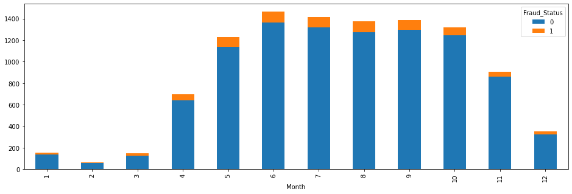

```python
data.groupby(['Month', 'Fraud_Status'])[['Fraud_Status']].size().unstack().plot(kind='bar', stacked=True,figsize=(16,5))
```

Fraud paling banyak terjadi di bulan 6 dan 8 dimana transaksinya paling banyak terjadi di pertengahan tahun

```python
data.groupby(['Hour','Fraud_Status'])[['Fraud_Status']].count()
```

| Hour | Fraud_Status | Fraud_Status |
| --- | --- | --- |
| 0 | 0 | 391 |
|  | 1 | 28 |
| 1 | 0 | 406 |
|  | 1 | 37 |
| 2 | 0 | 373 |
|  | 1 | 24 |
| 3 | 0 | 400 |
|  | 1 | 30 |
| 4 | 0 | 399 |
|  | 1 | 40 |
| 5 | 0 | 368 |
|  | 1 | 22 |
| 6 | 0 | 371 |
|  | 1 | 38 |
| 7 | 0 | 428 |
|  | 1 | 31 |
| 8 | 0 | 453 |
|  | 1 | 33 |
| 9 | 0 | 456 |
|  | 1 | 32 |
| 10 | 0 | 462 |
|  | 1 | 32 |
| 11 | 0 | 419 |
|  | 1 | 30 |
| 12 | 0 | 417 |
|  | 1 | 16 |
| 13 | 0 | 420 |
|  | 1 | 32 |
| 14 | 0 | 382 |
|  | 1 | 32 |
| 15 | 0 | 456 |
|  | 1 | 30 |
| 16 | 0 | 407 |
|  | 1 | 30 |
| 17 | 0 | 387 |
|  | 1 | 23 |
| 18 | 0 | 392 |
|  | 1 | 37 |
| 19 | 0 | 395 |
|  | 1 | 27 |
| 20 | 0 | 381 |
|  | 1 | 31 |
| 21 | 0 | 410 |
|  | 1 | 28 |
| 22 | 0 | 435 |
|  | 1 | 35 |
| 23 | 0 | 364 |
|  | 1 | 30 |

```python
value_counts(data,'Hour')
```

| Value | Count | Percentage |
| --- | --- | --- |
| 10 | 494 | 4.70% |
| 9 | 488 | 4.65% |
| 8 | 486 | 4.63% |
| 15 | 486 | 4.63% |
| 22 | 470 | 4.48% |
| 7 | 459 | 4.37% |
| 13 | 452 | 4.30% |
| 11 | 449 | 4.28% |
| 1 | 443 | 4.22% |
| 4 | 439 | 4.18% |
| 21 | 438 | 4.17% |
| 16 | 437 | 4.16% |
| 12 | 433 | 4.12% |
| 3 | 430 | 4.10% |
| 18 | 429 | 4.09% |
| 19 | 422 | 4.02% |
| 0 | 419 | 3.99% |
| 14 | 414 | 3.94% |
| 20 | 412 | 3.92% |
| 17 | 410 | 3.90% |
| 6 | 409 | 3.90% |
| 2 | 397 | 3.78% |
| 23 | 394 | 3.75% |
| 5 | 390 | 3.71% |

Fraud paling banyak terjadi di jam 4 pagi

```python
data.groupby(['Day','Fraud_Status'])[['Fraud_Status']].count()
```

| Day | Fraud_Status | Fraud_Status |
| --- | --- | --- |
| 1 | 0 | 134 |
|  | 1 | 13 |
| 2 | 0 | 168 |
|  | 1 | 8 |
| 3 | 0 | 330 |
|  | 1 | 24 |
| 4 | 0 | 331 |
|  | 1 | 30 |
| 5 | 0 | 486 |
|  | 1 | 35 |
| 6 | 0 | 539 |
|  | 1 | 47 |
| 7 | 0 | 535 |
|  | 1 | 40 |
| 8 | 0 | 537 |
|  | 1 | 38 |
| 9 | 0 | 498 |
|  | 1 | 46 |
| 10 | 0 | 424 |
|  | 1 | 38 |
| 11 | 0 | 326 |
|  | 1 | 22 |
| 12 | 0 | 286 |
|  | 1 | 21 |
| 13 | 0 | 158 |
|  | 1 | 12 |
| 14 | 0 | 145 |
|  | 1 | 11 |
| 15 | 0 | 13 |
| 17 | 0 | 98 |
|  | 1 | 8 |
| 18 | 0 | 165 |
|  | 1 | 6 |
| 19 | 0 | 266 |
|  | 1 | 24 |
| 20 | 0 | 335 |
|  | 1 | 18 |
| 21 | 0 | 458 |
|  | 1 | 26 |
| 22 | 0 | 483 |
|  | 1 | 42 |
| 23 | 0 | 514 |
|  | 1 | 30 |
| 24 | 0 | 494 |
|  | 1 | 36 |
| 25 | 0 | 517 |
|  | 1 | 26 |
| 26 | 0 | 498 |
|  | 1 | 43 |
| 27 | 0 | 345 |
|  | 1 | 32 |
| 28 | 0 | 301 |
|  | 1 | 20 |
| 29 | 0 | 220 |
|  | 1 | 15 |
| 30 | 0 | 138 |
|  | 1 | 11 |
| 31 | 0 | 30 |
|  | 1 | 6 |

```python
value_counts(data,'Day')
```

| Value | Count | Percentage |
| --- | --- | --- |
| 6 | 586 | 5.58% |
| 8 | 575 | 5.48% |
| 7 | 575 | 5.48% |
| 23 | 544 | 5.18% |
| 9 | 544 | 5.18% |
| 25 | 543 | 5.17% |
| 26 | 541 | 5.15% |
| 24 | 530 | 5.05% |
| 22 | 525 | 5.00% |
| 5 | 521 | 4.96% |
| 21 | 484 | 4.61% |
| 10 | 462 | 4.40% |
| 27 | 377 | 3.59% |
| 4 | 361 | 3.44% |
| 3 | 354 | 3.37% |
| 20 | 353 | 3.36% |
| 11 | 348 | 3.31% |
| 28 | 321 | 3.06% |
| 12 | 307 | 2.92% |
| 19 | 290 | 2.76% |
| 29 | 235 | 2.24% |
| 2 | 176 | 1.68% |
| 18 | 171 | 1.63% |
| 13 | 170 | 1.62% |
| 14 | 156 | 1.49% |
| 30 | 149 | 1.42% |
| 1 | 147 | 1.40% |
| 17 | 106 | 1.01% |
| 31 | 36 | 0.34% |
| 15 | 13 | 0.12% |

```python
days=pd.DataFrame(value_counts(data,'Day').data)
days=days.loc[days['Percentage']>0.045]
days
```

|  | Value | Count | Percentage |
| --- | --- | --- | --- |
| 0 | 6 | 586 | 0.055810 |
| 1 | 8 | 575 | 0.054762 |
| 2 | 7 | 575 | 0.054762 |
| 3 | 23 | 544 | 0.051810 |
| 4 | 9 | 544 | 0.051810 |
| 5 | 25 | 543 | 0.051714 |
| 6 | 26 | 541 | 0.051524 |
| 7 | 24 | 530 | 0.050476 |
| 8 | 22 | 525 | 0.050000 |
| 9 | 5 | 521 | 0.049619 |
| 10 | 21 | 484 | 0.046095 |

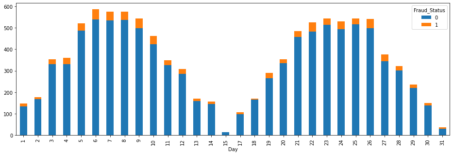

```python
data.groupby(['Day','Fraud_Status'])[['Fraud_Status']].size().unstack().plot(kind='bar', stacked=True,figsize=(16,5))
```

Fraud paling banyak terjadi di tanggal 6 (awal bulan) dan mendekati akhir bulan

```python
value_counts(data,'Bank_ID')
```

| Value | Count | Percentage |
| --- | --- | --- |
| 1 | 10,500 | 100.00% |

Karena variable Bank_ID tidak bervariasi maka dihilangkan

```python
data=data.drop(['Bank_ID'],axis=1)
data.head()
```

|  | Transaction_ID | Transaction_Flag | Transaction_Date | Transaction_Type | Transaction_Amount | CC_ID | Card_Type | Card_Holder | Channel_ID | Merchant_ID | ... | EDC_Location | EDC_Owner | Average_Transaction_Amount | Maximum_Transaction_Amount | Minimum_Transaction_Amount | Average_Transaction_Frequency | Fraud_Status | Month | Hour | Day |
| --- | --- | --- | --- | --- | --- | --- | --- | --- | --- | --- | --- | --- | --- | --- | --- | --- | --- | --- | --- | --- | --- |
| 0 | TX00002 | False | 2018-01-01 01:48:50.951 | T08 | 50000.0 | CCID5563 | CC11 | 2 | 1 | M0001 | ... | LEDC3703 | OEDC0377 | 661855.03 | 11000000.0 | 24212.0 | 2.91 | 0 | 1 | 1 | 1 |
| 1 | TX00004 | False | 2018-01-01 09:08:52.666 | T01 | 1000000.0 | CCID4598 | CC08 | 2 | 1 | M0001 | ... | LEDC3205 | OEDC0377 | 2171907.10 | 28555000.0 | 100000.0 | 3.12 | 1 | 1 | 9 | 1 |
| 2 | TX00005 | False | 2018-01-01 09:08:52.666 | T15 | 1000000.0 | CCID2839 | CC08 | 2 | 1 | M0001 | ... | LEDC3081 | OEDC0377 | 1714437.98 | 8500000.0 | 50.0 | 3.58 | 0 | 1 | 9 | 1 |
| 3 | TX00006 | False | 2018-01-01 09:45:55.969 | T15 | 1000000.0 | CCID2968 | CC08 | 2 | 1 | M0001 | ... | LEDC1993 | OEDC0377 | 10163708.23 | 100000000.0 | 63000.0 | 2.57 | 0 | 1 | 9 | 1 |
| 4 | TX00007 | False | 2018-01-01 23:41:59.228 | T10 | 2500000.0 | CCID0176 | CC12 | 2 | 1 | M0001 | ... | LEDC2062 | OEDC0377 | 690066.65 | 3523000.0 | 26500.0 | 4.23 | 0 | 1 | 23 | 1 |

5 rows × 23 columns

```python
value_counts(data,'Transaction_Flag')
```

| Value | Count | Percentage |
| --- | --- | --- |
| False | 10,500 | 100.00% |

Karena variable Transaction_Flag tidak bervariasi maka dihilangkan

```python
data=data.drop(['Transaction_Flag'],axis=1)
data.head()
```

|  | Transaction_ID | Transaction_Date | Transaction_Type | Transaction_Amount | CC_ID | Card_Type | Card_Holder | Channel_ID | Merchant_ID | Country_ID | ... | EDC_Location | EDC_Owner | Average_Transaction_Amount | Maximum_Transaction_Amount | Minimum_Transaction_Amount | Average_Transaction_Frequency | Fraud_Status | Month | Hour | Day |
| --- | --- | --- | --- | --- | --- | --- | --- | --- | --- | --- | --- | --- | --- | --- | --- | --- | --- | --- | --- | --- | --- |
| 0 | TX00002 | 2018-01-01 01:48:50.951 | T08 | 50000.0 | CCID5563 | CC11 | 2 | 1 | M0001 | CTY06 | ... | LEDC3703 | OEDC0377 | 661855.03 | 11000000.0 | 24212.0 | 2.91 | 0 | 1 | 1 | 1 |
| 1 | TX00004 | 2018-01-01 09:08:52.666 | T01 | 1000000.0 | CCID4598 | CC08 | 2 | 1 | M0001 | CTY06 | ... | LEDC3205 | OEDC0377 | 2171907.10 | 28555000.0 | 100000.0 | 3.12 | 1 | 1 | 9 | 1 |
| 2 | TX00005 | 2018-01-01 09:08:52.666 | T15 | 1000000.0 | CCID2839 | CC08 | 2 | 1 | M0001 | CTY06 | ... | LEDC3081 | OEDC0377 | 1714437.98 | 8500000.0 | 50.0 | 3.58 | 0 | 1 | 9 | 1 |
| 3 | TX00006 | 2018-01-01 09:45:55.969 | T15 | 1000000.0 | CCID2968 | CC08 | 2 | 1 | M0001 | CTY06 | ... | LEDC1993 | OEDC0377 | 10163708.23 | 100000000.0 | 63000.0 | 2.57 | 0 | 1 | 9 | 1 |
| 4 | TX00007 | 2018-01-01 23:41:59.228 | T10 | 2500000.0 | CCID0176 | CC12 | 2 | 1 | M0001 | CTY06 | ... | LEDC2062 | OEDC0377 | 690066.65 | 3523000.0 | 26500.0 | 4.23 | 0 | 1 | 23 | 1 |

5 rows × 22 columns

```python
value_counts(data,'Transaction_Type')
```

| Value | Count | Percentage |
| --- | --- | --- |
| T01 | 2,872 | 27.35% |
| T15 | 2,449 | 23.32% |
| T02 | 1,324 | 12.61% |
| T08 | 1,074 | 10.23% |
| T13 | 769 | 7.32% |
| T06 | 677 | 6.45% |
| T14 | 509 | 4.85% |
| T04 | 264 | 2.51% |
| T03 | 207 | 1.97% |
| T10 | 112 | 1.07% |
| T12 | 77 | 0.73% |
| T11 | 50 | 0.48% |
| T20 | 29 | 0.28% |
| T17 | 27 | 0.26% |
| T05 | 22 | 0.21% |
| T16 | 12 | 0.11% |
| T09 | 8 | 0.08% |
| T07 | 7 | 0.07% |
| T19 | 7 | 0.07% |
| T18 | 4 | 0.04% |

Melakukan grouping berdasarkan transaction type paling umum dilakukan.

T01 dan T15 termasuk transaction type paling banyak dilakukan maka akan masuk ke dalam grup 1, sedangkan type yang lain masuk ke grup 0

```python
CTT=[]
for i,j in enumerate (data['Transaction_Type']):
    if j=='T01':
        CTT.append(1)
    elif j=='T15':
        CTT.append(1)
    else:
        CTT.append(0)
data['Common_Transaction_Type']=CTT
data.head()
```

|  | Transaction_ID | Transaction_Date | Transaction_Type | Transaction_Amount | CC_ID | Card_Type | Card_Holder | Channel_ID | Merchant_ID | Country_ID | ... | EDC_Owner | Average_Transaction_Amount | Maximum_Transaction_Amount | Minimum_Transaction_Amount | Average_Transaction_Frequency | Fraud_Status | Month | Hour | Day | Common_Transaction_Type |
| --- | --- | --- | --- | --- | --- | --- | --- | --- | --- | --- | --- | --- | --- | --- | --- | --- | --- | --- | --- | --- | --- |
| 0 | TX00002 | 2018-01-01 01:48:50.951 | T08 | 50000.0 | CCID5563 | CC11 | 2 | 1 | M0001 | CTY06 | ... | OEDC0377 | 661855.03 | 11000000.0 | 24212.0 | 2.91 | 0 | 1 | 1 | 1 | 0 |
| 1 | TX00004 | 2018-01-01 09:08:52.666 | T01 | 1000000.0 | CCID4598 | CC08 | 2 | 1 | M0001 | CTY06 | ... | OEDC0377 | 2171907.10 | 28555000.0 | 100000.0 | 3.12 | 1 | 1 | 9 | 1 | 1 |
| 2 | TX00005 | 2018-01-01 09:08:52.666 | T15 | 1000000.0 | CCID2839 | CC08 | 2 | 1 | M0001 | CTY06 | ... | OEDC0377 | 1714437.98 | 8500000.0 | 50.0 | 3.58 | 0 | 1 | 9 | 1 | 1 |
| 3 | TX00006 | 2018-01-01 09:45:55.969 | T15 | 1000000.0 | CCID2968 | CC08 | 2 | 1 | M0001 | CTY06 | ... | OEDC0377 | 10163708.23 | 100000000.0 | 63000.0 | 2.57 | 0 | 1 | 9 | 1 | 1 |
| 4 | TX00007 | 2018-01-01 23:41:59.228 | T10 | 2500000.0 | CCID0176 | CC12 | 2 | 1 | M0001 | CTY06 | ... | OEDC0377 | 690066.65 | 3523000.0 | 26500.0 | 4.23 | 0 | 1 | 23 | 1 | 0 |

5 rows × 23 columns

```python
value_counts(data,'Card_Type')
```

| Value | Count | Percentage |
| --- | --- | --- |
| CC11 | 3,841 | 36.58% |
| CC08 | 2,113 | 20.12% |
| CC09 | 1,381 | 13.15% |
| CC00 | 1,260 | 12.00% |
| CC10 | 1,093 | 10.41% |
| CC04 | 237 | 2.26% |
| CC02 | 157 | 1.50% |
| CC01 | 155 | 1.48% |
| CC05 | 145 | 1.38% |
| CC12 | 54 | 0.51% |
| CC13 | 36 | 0.34% |
| CC03 | 20 | 0.19% |
| CC06 | 7 | 0.07% |
| CC07 | 1 | 0.01% |

Melakukan grouping berdasarkan card type paling umum.

CC11 dan CC08 termasuk card type paling umum maka akan masuk ke dalam grup 1, sedangkan type yang lain masuk ke grup 0

```python
DCT=[]
for i,j in enumerate (data['Card_Type']):
    if j=='CC11':
        DCT.append(1)
    elif j=='CC08':
        DCT.append(1)
    else:
        DCT.append(0)
data['Common_Card_Type']=DCT
data.head()
```

|  | Transaction_ID | Transaction_Date | Transaction_Type | Transaction_Amount | CC_ID | Card_Type | Card_Holder | Channel_ID | Merchant_ID | Country_ID | ... | Average_Transaction_Amount | Maximum_Transaction_Amount | Minimum_Transaction_Amount | Average_Transaction_Frequency | Fraud_Status | Month | Hour | Day | Common_Transaction_Type | Common_Card_Type |
| --- | --- | --- | --- | --- | --- | --- | --- | --- | --- | --- | --- | --- | --- | --- | --- | --- | --- | --- | --- | --- | --- |
| 0 | TX00002 | 2018-01-01 01:48:50.951 | T08 | 50000.0 | CCID5563 | CC11 | 2 | 1 | M0001 | CTY06 | ... | 661855.03 | 11000000.0 | 24212.0 | 2.91 | 0 | 1 | 1 | 1 | 0 | 1 |
| 1 | TX00004 | 2018-01-01 09:08:52.666 | T01 | 1000000.0 | CCID4598 | CC08 | 2 | 1 | M0001 | CTY06 | ... | 2171907.10 | 28555000.0 | 100000.0 | 3.12 | 1 | 1 | 9 | 1 | 1 | 1 |
| 2 | TX00005 | 2018-01-01 09:08:52.666 | T15 | 1000000.0 | CCID2839 | CC08 | 2 | 1 | M0001 | CTY06 | ... | 1714437.98 | 8500000.0 | 50.0 | 3.58 | 0 | 1 | 9 | 1 | 1 | 1 |
| 3 | TX00006 | 2018-01-01 09:45:55.969 | T15 | 1000000.0 | CCID2968 | CC08 | 2 | 1 | M0001 | CTY06 | ... | 10163708.23 | 100000000.0 | 63000.0 | 2.57 | 0 | 1 | 9 | 1 | 1 | 1 |
| 4 | TX00007 | 2018-01-01 23:41:59.228 | T10 | 2500000.0 | CCID0176 | CC12 | 2 | 1 | M0001 | CTY06 | ... | 690066.65 | 3523000.0 | 26500.0 | 4.23 | 0 | 1 | 23 | 1 | 0 | 0 |

5 rows × 24 columns

```python
value_counts(data,'Card_Holder')
```

| Value | Count | Percentage |
| --- | --- | --- |
| 2 | 9,788 | 93.22% |
| 1 | 712 | 6.78% |

Karena persentase card holder tipe 1 adalah 6% dimana masih diatas 5% maka variabel ini tidak dibuang

```python
value_counts(data,'Channel_ID')
```

| Value | Count | Percentage |
| --- | --- | --- |
| 1 | 8,325 | 79.29% |
| 2 | 1,463 | 13.93% |
| 5 | 682 | 6.50% |
| 3 | 25 | 0.24% |
| 4 | 5 | 0.05% |

Melakukan grouping berdasarkan Channel_ID 1.

Channel_ID 1 akan masuk ke dalam grup 1, sedangkan ID yang lain masuk ke grup 0

```python
DCI=[]
for i,j in enumerate (data['Channel_ID']):
    if j==1:
        DCI.append(1)
    else:
        DCI.append(0)
data['ChannelID_1']=DCI
data.head()
```

|  | Transaction_ID | Transaction_Date | Transaction_Type | Transaction_Amount | CC_ID | Card_Type | Card_Holder | Channel_ID | Merchant_ID | Country_ID | ... | Maximum_Transaction_Amount | Minimum_Transaction_Amount | Average_Transaction_Frequency | Fraud_Status | Month | Hour | Day | Common_Transaction_Type | Common_Card_Type | ChannelID_1 |
| --- | --- | --- | --- | --- | --- | --- | --- | --- | --- | --- | --- | --- | --- | --- | --- | --- | --- | --- | --- | --- | --- |
| 0 | TX00002 | 2018-01-01 01:48:50.951 | T08 | 50000.0 | CCID5563 | CC11 | 2 | 1 | M0001 | CTY06 | ... | 11000000.0 | 24212.0 | 2.91 | 0 | 1 | 1 | 1 | 0 | 1 | 1 |
| 1 | TX00004 | 2018-01-01 09:08:52.666 | T01 | 1000000.0 | CCID4598 | CC08 | 2 | 1 | M0001 | CTY06 | ... | 28555000.0 | 100000.0 | 3.12 | 1 | 1 | 9 | 1 | 1 | 1 | 1 |
| 2 | TX00005 | 2018-01-01 09:08:52.666 | T15 | 1000000.0 | CCID2839 | CC08 | 2 | 1 | M0001 | CTY06 | ... | 8500000.0 | 50.0 | 3.58 | 0 | 1 | 9 | 1 | 1 | 1 | 1 |
| 3 | TX00006 | 2018-01-01 09:45:55.969 | T15 | 1000000.0 | CCID2968 | CC08 | 2 | 1 | M0001 | CTY06 | ... | 100000000.0 | 63000.0 | 2.57 | 0 | 1 | 9 | 1 | 1 | 1 | 1 |
| 4 | TX00007 | 2018-01-01 23:41:59.228 | T10 | 2500000.0 | CCID0176 | CC12 | 2 | 1 | M0001 | CTY06 | ... | 3523000.0 | 26500.0 | 4.23 | 0 | 1 | 23 | 1 | 0 | 0 | 1 |

5 rows × 25 columns

```python
value_counts(data,'Country_ID')
```

| Value | Count | Percentage |
| --- | --- | --- |
| CTY06 | 10,464 | 99.66% |
| CTY08 | 9 | 0.09% |
| CTY05 | 8 | 0.08% |
| CTY07 | 5 | 0.05% |
| CTY13 | 3 | 0.03% |
| CTY01 | 3 | 0.03% |
| CTY10 | 2 | 0.02% |
| CTY12 | 2 | 0.02% |
| CTY09 | 2 | 0.02% |
| CTY02 | 1 | 0.01% |
| CTY04 | 1 | 0.01% |

Melakukan grouping berdasarkan countryID CTY006.

CTY006 akan masuk ke dalam grup 1, sedangkan ID yang lain masuk ke grup 0

```python
CTY=[]
for i,j in enumerate (data['Country_ID']):
    if j=='CTY06':
        CTY.append(1)
    else:
        CTY.append(0)
data['Country']=CTY
data.head()
```

|  | Transaction_ID | Transaction_Date | Transaction_Type | Transaction_Amount | CC_ID | Card_Type | Card_Holder | Channel_ID | Merchant_ID | Country_ID | ... | Minimum_Transaction_Amount | Average_Transaction_Frequency | Fraud_Status | Month | Hour | Day | Common_Transaction_Type | Common_Card_Type | ChannelID_1 | Country |
| --- | --- | --- | --- | --- | --- | --- | --- | --- | --- | --- | --- | --- | --- | --- | --- | --- | --- | --- | --- | --- | --- |
| 0 | TX00002 | 2018-01-01 01:48:50.951 | T08 | 50000.0 | CCID5563 | CC11 | 2 | 1 | M0001 | CTY06 | ... | 24212.0 | 2.91 | 0 | 1 | 1 | 1 | 0 | 1 | 1 | 1 |
| 1 | TX00004 | 2018-01-01 09:08:52.666 | T01 | 1000000.0 | CCID4598 | CC08 | 2 | 1 | M0001 | CTY06 | ... | 100000.0 | 3.12 | 1 | 1 | 9 | 1 | 1 | 1 | 1 | 1 |
| 2 | TX00005 | 2018-01-01 09:08:52.666 | T15 | 1000000.0 | CCID2839 | CC08 | 2 | 1 | M0001 | CTY06 | ... | 50.0 | 3.58 | 0 | 1 | 9 | 1 | 1 | 1 | 1 | 1 |
| 3 | TX00006 | 2018-01-01 09:45:55.969 | T15 | 1000000.0 | CCID2968 | CC08 | 2 | 1 | M0001 | CTY06 | ... | 63000.0 | 2.57 | 0 | 1 | 9 | 1 | 1 | 1 | 1 | 1 |
| 4 | TX00007 | 2018-01-01 23:41:59.228 | T10 | 2500000.0 | CCID0176 | CC12 | 2 | 1 | M0001 | CTY06 | ... | 26500.0 | 4.23 | 0 | 1 | 23 | 1 | 0 | 0 | 1 | 1 |

5 rows × 26 columns

```python
value_counts(data,'City_ID')
```

| Value | Count | Percentage |
| --- | --- | --- |
| CTY06-023 | 4,255 | 40.52% |
| CTY06-133 | 1,277 | 12.16% |
| CTY06-181 | 801 | 7.63% |
| CTY06-171 | 441 | 4.20% |
| CTY06-186 | 337 | 3.21% |
| CTY06-129 | 263 | 2.50% |
| CTY06-005 | 173 | 1.65% |
| CTY06-112 | 156 | 1.49% |
| CTY06-004 | 145 | 1.38% |
| CTY06-151 | 113 | 1.08% |
| CTY06-083 | 103 | 0.98% |
| CTY06-110 | 101 | 0.96% |
| CTY06-191 | 94 | 0.90% |
| CTY06-205 | 84 | 0.80% |
| CTY06-115 | 77 | 0.73% |
| CTY06-179 | 75 | 0.71% |
| CTY06-075 | 73 | 0.70% |
| CTY06-126 | 68 | 0.65% |
| CTY06-046 | 65 | 0.62% |
| CTY06-140 | 64 | 0.61% |
| CTY06-101 | 62 | 0.59% |
| CTY06-176 | 60 | 0.57% |
| CTY06-195 | 59 | 0.56% |
| CTY06-121 | 59 | 0.56% |
| CTY06-072 | 58 | 0.55% |
| CTY06-058 | 55 | 0.52% |
| CTY06-096 | 45 | 0.43% |
| CTY06-071 | 43 | 0.41% |
| CTY06-027 | 43 | 0.41% |
| CTY06-073 | 41 | 0.39% |

[output cut: 197 more lines]

Melakukan grouping berdasarkan City_ID paling umum.

CTY06-023 dan CTY06-133 termasuk City ID paling umum maka akan masuk ke dalam grup 1, sedangkan ID yang lain masuk ke grup 0

```python
CCI=[]
for i,j in enumerate (data['City_ID']):
    if j=='CTY06-023':
        CCI.append(1)
    elif j=='CTY06-133':
        CCI.append(1)
    else:
        CCI.append(0)
data['Common_City']=CCI
data.head()
```

|  | Transaction_ID | Transaction_Date | Transaction_Type | Transaction_Amount | CC_ID | Card_Type | Card_Holder | Channel_ID | Merchant_ID | Country_ID | ... | Average_Transaction_Frequency | Fraud_Status | Month | Hour | Day | Common_Transaction_Type | Common_Card_Type | ChannelID_1 | Country | Common_City |
| --- | --- | --- | --- | --- | --- | --- | --- | --- | --- | --- | --- | --- | --- | --- | --- | --- | --- | --- | --- | --- | --- |
| 0 | TX00002 | 2018-01-01 01:48:50.951 | T08 | 50000.0 | CCID5563 | CC11 | 2 | 1 | M0001 | CTY06 | ... | 2.91 | 0 | 1 | 1 | 1 | 0 | 1 | 1 | 1 | 1 |
| 1 | TX00004 | 2018-01-01 09:08:52.666 | T01 | 1000000.0 | CCID4598 | CC08 | 2 | 1 | M0001 | CTY06 | ... | 3.12 | 1 | 1 | 9 | 1 | 1 | 1 | 1 | 1 | 0 |
| 2 | TX00005 | 2018-01-01 09:08:52.666 | T15 | 1000000.0 | CCID2839 | CC08 | 2 | 1 | M0001 | CTY06 | ... | 3.58 | 0 | 1 | 9 | 1 | 1 | 1 | 1 | 1 | 0 |
| 3 | TX00006 | 2018-01-01 09:45:55.969 | T15 | 1000000.0 | CCID2968 | CC08 | 2 | 1 | M0001 | CTY06 | ... | 2.57 | 0 | 1 | 9 | 1 | 1 | 1 | 1 | 1 | 0 |
| 4 | TX00007 | 2018-01-01 23:41:59.228 | T10 | 2500000.0 | CCID0176 | CC12 | 2 | 1 | M0001 | CTY06 | ... | 4.23 | 0 | 1 | 23 | 1 | 0 | 0 | 1 | 1 | 1 |

5 rows × 27 columns

```python
value_counts(data,'EDC_Owner')
```

| Value | Count | Percentage |
| --- | --- | --- |
| OEDC0377 | 8,325 | 79.29% |
| OEDC0378 | 15 | 0.14% |
| OEDC1363 | 6 | 0.06% |
| OEDC0886 | 6 | 0.06% |
| OEDC0212 | 6 | 0.06% |
| OEDC1288 | 5 | 0.05% |
| OEDC1040 | 5 | 0.05% |
| OEDC1539 | 5 | 0.05% |
| OEDC0909 | 5 | 0.05% |
| OEDC0118 | 5 | 0.05% |
| OEDC1444 | 5 | 0.05% |
| OEDC0380 | 5 | 0.05% |
| OEDC0343 | 5 | 0.05% |
| OEDC1085 | 5 | 0.05% |
| OEDC0180 | 5 | 0.05% |
| OEDC1048 | 5 | 0.05% |
| OEDC1639 | 5 | 0.05% |
| OEDC1035 | 5 | 0.05% |
| OEDC1261 | 5 | 0.05% |
| OEDC1438 | 5 | 0.05% |
| OEDC1452 | 4 | 0.04% |
| OEDC0931 | 4 | 0.04% |
| OEDC0071 | 4 | 0.04% |
| OEDC0751 | 4 | 0.04% |
| OEDC0059 | 4 | 0.04% |
| OEDC1285 | 4 | 0.04% |
| OEDC0392 | 4 | 0.04% |
| OEDC1523 | 4 | 0.04% |
| OEDC0914 | 4 | 0.04% |
| OEDC1467 | 4 | 0.04% |

[output cut: 1431 more lines]

Melakukan grouping berdasarkan EDC_Owner OEDC0337.

EDC Owner OEDC0337 akan masuk ke dalam grup 1, sedangkan yang lain masuk ke grup 0

```python
EDC=[]
for i,j in enumerate (data['EDC_Owner']):
    if j=='OEDC0377':
        EDC.append(1)
    else:
        EDC.append(0)
data['Common_EDC_Owner']=EDC
data.head()
```

|  | Transaction_ID | Transaction_Date | Transaction_Type | Transaction_Amount | CC_ID | Card_Type | Card_Holder | Channel_ID | Merchant_ID | Country_ID | ... | Fraud_Status | Month | Hour | Day | Common_Transaction_Type | Common_Card_Type | ChannelID_1 | Country | Common_City | Common_EDC_Owner |
| --- | --- | --- | --- | --- | --- | --- | --- | --- | --- | --- | --- | --- | --- | --- | --- | --- | --- | --- | --- | --- | --- |
| 0 | TX00002 | 2018-01-01 01:48:50.951 | T08 | 50000.0 | CCID5563 | CC11 | 2 | 1 | M0001 | CTY06 | ... | 0 | 1 | 1 | 1 | 0 | 1 | 1 | 1 | 1 | 1 |
| 1 | TX00004 | 2018-01-01 09:08:52.666 | T01 | 1000000.0 | CCID4598 | CC08 | 2 | 1 | M0001 | CTY06 | ... | 1 | 1 | 9 | 1 | 1 | 1 | 1 | 1 | 0 | 1 |
| 2 | TX00005 | 2018-01-01 09:08:52.666 | T15 | 1000000.0 | CCID2839 | CC08 | 2 | 1 | M0001 | CTY06 | ... | 0 | 1 | 9 | 1 | 1 | 1 | 1 | 1 | 0 | 1 |
| 3 | TX00006 | 2018-01-01 09:45:55.969 | T15 | 1000000.0 | CCID2968 | CC08 | 2 | 1 | M0001 | CTY06 | ... | 0 | 1 | 9 | 1 | 1 | 1 | 1 | 1 | 0 | 1 |
| 4 | TX00007 | 2018-01-01 23:41:59.228 | T10 | 2500000.0 | CCID0176 | CC12 | 2 | 1 | M0001 | CTY06 | ... | 0 | 1 | 23 | 1 | 0 | 0 | 1 | 1 | 1 | 1 |

5 rows × 28 columns

```python
value_counts(data,'Merchant_ID')
```

| Value | Count | Percentage |
| --- | --- | --- |
| M0001 | 9,037 | 86.07% |
| M0063 | 6 | 0.06% |
| M0140 | 6 | 0.06% |
| M0100 | 6 | 0.06% |
| M0243 | 6 | 0.06% |
| M0187 | 5 | 0.05% |
| M0405 | 5 | 0.05% |
| M0343 | 5 | 0.05% |
| M0088 | 5 | 0.05% |
| M0325 | 4 | 0.04% |
| M0200 | 4 | 0.04% |
| M0156 | 4 | 0.04% |
| M0017 | 4 | 0.04% |
| M0350 | 4 | 0.04% |
| M0419 | 4 | 0.04% |
| M0633 | 4 | 0.04% |
| M0644 | 4 | 0.04% |
| M0155 | 4 | 0.04% |
| M0510 | 4 | 0.04% |
| M0307 | 4 | 0.04% |
| M0418 | 4 | 0.04% |
| M0514 | 4 | 0.04% |
| M0434 | 4 | 0.04% |
| M0208 | 4 | 0.04% |
| M0013 | 4 | 0.04% |
| M0081 | 4 | 0.04% |
| M0104 | 4 | 0.04% |
| M0592 | 4 | 0.04% |
| M0202 | 4 | 0.04% |
| M0649 | 4 | 0.04% |

[output cut: 945 more lines]

Melakukan grouping berdasarkan Merchant_ID M0001.

Merchant_ID M0001 akan masuk ke dalam grup 1, sedangkan yang lain masuk ke grup 0

```python
MCI=[]
for i,j in enumerate (data['Merchant_ID']):
    if j=='M0001':
        MCI.append(1)
    else:
        MCI.append(0)
data['Common_Merchant_ID']=MCI
data.head()
```

|  | Transaction_ID | Transaction_Date | Transaction_Type | Transaction_Amount | CC_ID | Card_Type | Card_Holder | Channel_ID | Merchant_ID | Country_ID | ... | Month | Hour | Day | Common_Transaction_Type | Common_Card_Type | ChannelID_1 | Country | Common_City | Common_EDC_Owner | Common_Merchant_ID |
| --- | --- | --- | --- | --- | --- | --- | --- | --- | --- | --- | --- | --- | --- | --- | --- | --- | --- | --- | --- | --- | --- |
| 0 | TX00002 | 2018-01-01 01:48:50.951 | T08 | 50000.0 | CCID5563 | CC11 | 2 | 1 | M0001 | CTY06 | ... | 1 | 1 | 1 | 0 | 1 | 1 | 1 | 1 | 1 | 1 |
| 1 | TX00004 | 2018-01-01 09:08:52.666 | T01 | 1000000.0 | CCID4598 | CC08 | 2 | 1 | M0001 | CTY06 | ... | 1 | 9 | 1 | 1 | 1 | 1 | 1 | 0 | 1 | 1 |
| 2 | TX00005 | 2018-01-01 09:08:52.666 | T15 | 1000000.0 | CCID2839 | CC08 | 2 | 1 | M0001 | CTY06 | ... | 1 | 9 | 1 | 1 | 1 | 1 | 1 | 0 | 1 | 1 |
| 3 | TX00006 | 2018-01-01 09:45:55.969 | T15 | 1000000.0 | CCID2968 | CC08 | 2 | 1 | M0001 | CTY06 | ... | 1 | 9 | 1 | 1 | 1 | 1 | 1 | 0 | 1 | 1 |
| 4 | TX00007 | 2018-01-01 23:41:59.228 | T10 | 2500000.0 | CCID0176 | CC12 | 2 | 1 | M0001 | CTY06 | ... | 1 | 23 | 1 | 0 | 0 | 1 | 1 | 1 | 1 | 1 |

5 rows × 29 columns

Menambahkan feature peak months,days dan operational hours untuk menunjukkan transaksi paling banyak dilakukan pada bulan, dan hari apa. Untuk operational hours digunakan asumsi 10.00-22.00 adalah jam operasional merchant

```python
MTH=[]
for j in data['Month']:
    array= np.isin(months['Value'],j)
    if any(array)==True:
        MTH.append(1)
    elif all(array)==False:
        MTH.append(0)
data['Peak_Months']=MTH
```

```python
DYS=[]
for j in data['Day']:
    array= np.isin(days['Value'],j)
    if any(array)==True:
        DYS.append(1)
    elif all(array)==False:
        DYS.append(0)
data['Peak_Days']=DYS
```

```python
OP=list(np.arange(10,23))
HRS=[]
for j in data['Hour']:
    array= np.isin(OP,j)
    if any(array)==True:
        HRS.append(1)
    elif all(array)==False:
        HRS.append(0)
data['Operational_Hours']=HRS
```

### Data Preparation

Untuk data yang kosong akan diisi dengan median variabel yang diinginkan berdasarkan variabel Common Merchant ID nya.

Untuk Minimum Average Transaction yang dibawah 1000 juga akan diisi dengan median dari Minimum Average Transaction berdasarkan Common Merchant ID yang dimiliki, karena Minimum Average Transaction <1000 dianggap outlier

Untuk transaction amount =1 juga diisi dengan median berdasarkan Common Merchant ID nya

```python
def null_counts(data, style=True):
    nulls = data.isna().sum().rename_axis('Columns').reset_index(name='Count')
    nulls['Percentage'] = nulls['Count'] / len(data)
    nulls = nulls.loc[nulls['Count'] > 0]
    nulls.sort_values(by='Count', ascending=False, inplace=True)
    nulls.reset_index(drop=True, inplace=True)

    if style:
        nulls = nulls.style.format({'Count': '{:,}', 'Percentage': '{:.2%}'}).hide_index()

    return nulls
```

```python
null_counts(data)
```

| Columns | Count | Percentage |
| --- | --- | --- |
| Average_Transaction_Amount | 16 | 0.15% |
| Maximum_Transaction_Amount | 16 | 0.15% |
| Minimum_Transaction_Amount | 16 | 0.15% |
| Average_Transaction_Frequency | 16 | 0.15% |

```python
def median(var,status):
    med=data.loc[data['Common_Merchant_ID']==status,var].median()
    return(med)
```

```python
var_na=['Average_Transaction_Amount','Average_Transaction_Frequency',
        'Maximum_Transaction_Amount','Minimum_Transaction_Amount']
```

```python
for i in var_na:
    data.loc[(data[i].isnull()==True)&(data['Common_Merchant_ID']==1),i]=median(i,1)
    data.loc[(data[i].isnull()==True)&(data['Common_Merchant_ID']==0),i]=median(i,0)
```

```python
null_counts(data)
```

| Columns | Count | Percentage |
| --- | --- | --- |

```python
data['Total_Month']=data['Average_Transaction_Amount']*data['Average_Transaction_Frequency']
data.head()
```

|  | Transaction_ID | Transaction_Date | Transaction_Type | Transaction_Amount | CC_ID | Card_Type | Card_Holder | Channel_ID | Merchant_ID | Country_ID | ... | Common_Card_Type | ChannelID_1 | Country | Common_City | Common_EDC_Owner | Common_Merchant_ID | Peak_Months | Peak_Days | Operational_Hours | Total_Month |
| --- | --- | --- | --- | --- | --- | --- | --- | --- | --- | --- | --- | --- | --- | --- | --- | --- | --- | --- | --- | --- | --- |
| 0 | TX00002 | 2018-01-01 01:48:50.951 | T08 | 50000.0 | CCID5563 | CC11 | 2 | 1 | M0001 | CTY06 | ... | 1 | 1 | 1 | 1 | 1 | 1 | 0 | 0 | 0 | 1.925998e+06 |
| 1 | TX00004 | 2018-01-01 09:08:52.666 | T01 | 1000000.0 | CCID4598 | CC08 | 2 | 1 | M0001 | CTY06 | ... | 1 | 1 | 1 | 0 | 1 | 1 | 0 | 0 | 0 | 6.776350e+06 |
| 2 | TX00005 | 2018-01-01 09:08:52.666 | T15 | 1000000.0 | CCID2839 | CC08 | 2 | 1 | M0001 | CTY06 | ... | 1 | 1 | 1 | 0 | 1 | 1 | 0 | 0 | 0 | 6.137688e+06 |
| 3 | TX00006 | 2018-01-01 09:45:55.969 | T15 | 1000000.0 | CCID2968 | CC08 | 2 | 1 | M0001 | CTY06 | ... | 1 | 1 | 1 | 0 | 1 | 1 | 0 | 0 | 0 | 2.612073e+07 |
| 4 | TX00007 | 2018-01-01 23:41:59.228 | T10 | 2500000.0 | CCID0176 | CC12 | 2 | 1 | M0001 | CTY06 | ... | 0 | 1 | 1 | 1 | 1 | 1 | 0 | 0 | 0 | 2.918982e+06 |

5 rows × 33 columns

```python
data.loc[(data['Minimum_Transaction_Amount']<1000)&(data['Common_Merchant_ID']==1)
         ,'Minimum_Transaction_Amount']=median('Minimum_Transaction_Amount',1)
data.loc[(data['Minimum_Transaction_Amount']<1000)&(data['Common_Merchant_ID']==0)
         ,'Minimum_Transaction_Amount']=median('Minimum_Transaction_Amount',0)
```

```python
data.loc[(data['Transaction_Amount']==1)&(data['Common_Merchant_ID']==1)
         ,'Transaction_Amount']=median('Transaction_Amount',1)
data.loc[(data['Transaction_Amount']==1)&(data['Common_Merchant_ID']==0)
         ,'Transaction_Amount']=median('Transaction_Amount',0)
```

```python
stat1=data.groupby(['Merchant_ID','Month'])['Transaction_Amount'].agg(['min','max','mean','sum'])
stat1=pd.DataFrame(stat1)
stat1.reset_index(inplace=True)
```

```python
stat1.head()
```

|  | Merchant_ID | Month | min | max | mean | sum |
| --- | --- | --- | --- | --- | --- | --- |
| 0 | M0001 | 1 | 26500.0 | 5000000.0 | 1.001420e+06 | 1.321875e+08 |
| 1 | M0001 | 2 | 25000.0 | 33500000.0 | 2.492490e+06 | 1.321020e+08 |
| 2 | M0001 | 3 | 22075.0 | 10000000.0 | 1.148323e+06 | 1.492820e+08 |
| 3 | M0001 | 4 | 22075.0 | 50000000.0 | 1.376738e+06 | 9.265450e+08 |
| 4 | M0001 | 5 | 10000.0 | 29012854.0 | 1.355095e+06 | 1.496025e+09 |

```python
min_merchant=[]
max_merchant=[]
mean_merchant=[]
sum_merchant=[]
for l,i in enumerate (data['Merchant_ID']):
    min_merchant.append(stat1.loc[(stat1['Merchant_ID']==i)&(stat1['Month']==data['Month'][l]),'min'].sum())
    max_merchant.append(stat1.loc[(stat1['Merchant_ID']==i)&(stat1['Month']==data['Month'][l]),'max'].sum())
    mean_merchant.append(stat1.loc[(stat1['Merchant_ID']==i)&(stat1['Month']==data['Month'][l]),'mean'].sum())
    sum_merchant.append(stat1.loc[(stat1['Merchant_ID']==i)&(stat1['Month']==data['Month'][l]),'sum'].sum())
```

```python
data['Min_Merchant']=min_merchant
data['Max_Merchant']=max_merchant
data['Mean_Merchant']=mean_merchant
data['Sum_Merchant']=sum_merchant
```

```python
stat2=data.groupby(['Country_ID','Month'])['Transaction_Amount'].agg(['min','max','mean','sum'])
stat2=pd.DataFrame(stat2)
stat2.reset_index(inplace=True)
```

```python
stat2.head()
```

|  | Country_ID | Month | min | max | mean | sum |
| --- | --- | --- | --- | --- | --- | --- |
| 0 | CTY01 | 4 | 1525000.0 | 1525000.0 | 1525000.0 | 1525000.0 |
| 1 | CTY01 | 9 | 550000.0 | 550000.0 | 550000.0 | 550000.0 |
| 2 | CTY01 | 10 | 1500000.0 | 1500000.0 | 1500000.0 | 1500000.0 |
| 3 | CTY02 | 4 | 2500000.0 | 2500000.0 | 2500000.0 | 2500000.0 |
| 4 | CTY04 | 8 | 3000000.0 | 3000000.0 | 3000000.0 | 3000000.0 |

```python
min_country=[]
max_country=[]
mean_country=[]
sum_country=[]
for l,i in enumerate (data['Country_ID']):
    min_country.append(stat2.loc[(stat2['Country_ID']==i)&(stat2['Month']==data['Month'][l]),'min'].sum())
    max_country.append(stat2.loc[(stat2['Country_ID']==i)&(stat2['Month']==data['Month'][l]),'max'].sum())
    mean_country.append(stat2.loc[(stat2['Country_ID']==i)&(stat2['Month']==data['Month'][l]),'mean'].sum())
    sum_country.append(stat2.loc[(stat2['Country_ID']==i)&(stat2['Month']==data['Month'][l]),'sum'].sum())
```

```python
data['Min_Country']=min_country
data['Max_Country']=max_country
data['Mean_Country']=mean_country
data['Sum_Country']=sum_country
```

```python
stat3=data.groupby(['Month'])['Transaction_Amount'].agg(['min','max','mean','sum'])
stat3=pd.DataFrame(stat3)
stat3.reset_index(inplace=True)
```

```python
min_cc=[]
max_cc=[]
mean_cc=[]
sum_cc=[]
for l,i in enumerate (data['CC_ID']):
    min_cc.append(stat3.loc[stat3['Month']==data['Month'][l],'min'].sum())
    max_cc.append(stat3.loc[stat3['Month']==data['Month'][l],'max'].sum())
    mean_cc.append(stat3.loc[stat3['Month']==data['Month'][l],'mean'].sum())
    sum_cc.append(stat3.loc[stat3['Month']==data['Month'][l],'sum'].sum())
```

```python
data['Min_CCID']=min_cc
data['Max_CCID']=max_cc
data['Mean_CCID']=mean_cc
data['Sum_CCID']=sum_cc
```

Dari total seluruh variabel yang telah ditambahkan, melalui proses trial dan error untuk mendapatkan model dengan performa terbaik (F1), maka variabel yang akhirnya digunakan adalah variabel dibawah yang terdapat pada glm_vars.

Jadi dari seluruh variabel tersebut sudah melalui tahap korelasi, vif, dan pp score, hingga modeling, kemudian terus dilakukan trial dan error dalam menentukan variabel terbaik sehingga variabel yang tersisa terdapat pada glm_vars

```python
response='Fraud_Status'
glm_vars=['Transaction_Amount',
 'Card_Holder',
 'Maximum_Transaction_Amount',
 'Average_Transaction_Amount',
 'Average_Transaction_Frequency','Total_Month']
```

```python
from statsmodels.tools.tools import add_constant
from statsmodels.stats.outliers_influence import variance_inflation_factor

def vif(data, features, style=True):
    # Add constant to the GLM variables
    X = add_constant(data[features])
    vif_values = [variance_inflation_factor(X.values, i) for i in range(1, X.shape[1])]
    vif_df = pd.DataFrame({'Variable': features, 'VIF': vif_values})
    vif_df = vif_df.sort_values('VIF', ascending=False).reset_index(drop=True)
    vif_df.index += 1

    if style:
        vif_df = vif_df.style.format({'VIF': '{:,.2f}'})

    return vif_df
```

Threshold dari VIFnya adalah 10

```python
vif(data, glm_vars)
```

|  | Variable | VIF |
| --- | --- | --- |
| 1 | Total_Month | 6.68 |
| 2 | Average_Transaction_Amount | 5.10 |
| 3 | Average_Transaction_Frequency | 2.55 |
| 4 | Maximum_Transaction_Amount | 1.98 |
| 5 | Transaction_Amount | 1.24 |
| 6 | Card_Holder | 1.00 |

glm vars2 sama seperti glm vars, hanya terdapat tambahan variabel Fraud Status. glm vars2 akan digunakan pada korelasi

```python
glm_vars2=['Transaction_Amount',
 'Card_Holder',
 'Maximum_Transaction_Amount',
 'Average_Transaction_Amount',
 'Average_Transaction_Frequency','Total_Month','Fraud_Status']
```

```python
import numpy as np
import seaborn as sns
def correlation_plot(df, features, plotsize=(15,15), corr_type='pearson', number_format='.1%', fontsize=11):
    corrs = data[features].corr(method=corr_type)
    triangle = np.triu(corrs)

    fig, ax = plt.subplots(figsize=plotsize)
    ax = sns.heatmap(corrs, mask=triangle, annot=True, annot_kws={'size': fontsize}, fmt=number_format, cmap='RdYlGn_r',
                     cbar_kws={'shrink': 0.8}, vmin=-1, center=0, vmax=1, square=True, linewidths=0.1, linecolor='white')
    plt.show()
```

threshold korelasi adalah 0.8

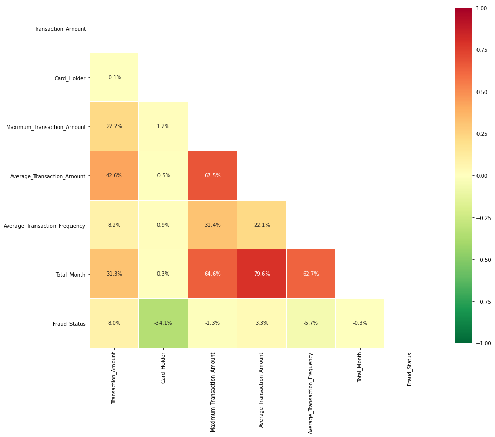

```python
correlation_plot(data, glm_vars2, fontsize=10)
```

```python
data2=data[glm_vars2]
data2.head()
```

|  | Transaction_Amount | Card_Holder | Maximum_Transaction_Amount | Average_Transaction_Amount | Average_Transaction_Frequency | Total_Month | Fraud_Status |
| --- | --- | --- | --- | --- | --- | --- | --- |
| 0 | 50000.0 | 2 | 11000000.0 | 661855.03 | 2.91 | 1.925998e+06 | 0 |
| 1 | 1000000.0 | 2 | 28555000.0 | 2171907.10 | 3.12 | 6.776350e+06 | 1 |
| 2 | 1000000.0 | 2 | 8500000.0 | 1714437.98 | 3.58 | 6.137688e+06 | 0 |
| 3 | 1000000.0 | 2 | 100000000.0 | 10163708.23 | 2.57 | 2.612073e+07 | 0 |
| 4 | 2500000.0 | 2 | 3523000.0 | 690066.65 | 4.23 | 2.918982e+06 | 0 |

```python
import ppscore as pps
```

```python
pps_mtx = pps.matrix(data2.astype({'Fraud_Status':'category'}))
```

```python
pps_predictors2target = pps_mtx[(pps_mtx['x'] != 'Fraud_Status') & (pps_mtx['y'] == 'Fraud_Status')].copy()
pps_predictors2target.sort_values(by='ppscore', ascending=False, inplace=True)
pps_predictors2target.reset_index(drop=True, inplace=True)
pps_predictors2target
```

|  | x | y | ppscore | case | is_valid_score | metric | baseline_score | model_score | model |
| --- | --- | --- | --- | --- | --- | --- | --- | --- | --- |
| 0 | Transaction_Amount | Fraud_Status | 0.0 | classification | True | weighted F1 | 0.898026 | 0.897070 | DecisionTreeClassifier() |
| 1 | Card_Holder | Fraud_Status | 0.0 | classification | True | weighted F1 | 0.898026 | 0.898026 | DecisionTreeClassifier() |
| 2 | Maximum_Transaction_Amount | Fraud_Status | 0.0 | classification | True | weighted F1 | 0.898026 | 0.895576 | DecisionTreeClassifier() |
| 3 | Average_Transaction_Amount | Fraud_Status | 0.0 | classification | True | weighted F1 | 0.898026 | 0.891258 | DecisionTreeClassifier() |
| 4 | Average_Transaction_Frequency | Fraud_Status | 0.0 | classification | True | weighted F1 | 0.898026 | 0.897626 | DecisionTreeClassifier() |
| 5 | Total_Month | Fraud_Status | 0.0 | classification | True | weighted F1 | 0.898026 | 0.874565 | DecisionTreeClassifier() |

threshold pp score adalah 0.8

```python
pps70 = pps_mtx[(pps_mtx['ppscore'] > 0.8) & (pps_mtx['ppscore'] < 1)].copy()
pps70.sort_values(by='ppscore', ascending=False, inplace=True)
pps70.reset_index(drop=True, inplace=True)
pps70
```

|  | x | y | ppscore | case | is_valid_score | metric | baseline_score | model_score | model |
| --- | --- | --- | --- | --- | --- | --- | --- | --- | --- |

Melakukan EDA dari variabel numerikal yang tersisa

```python
def target_boxplot(data, variable, target='Target', plotsize=(8, 8), colors=['green', 'red'], labels=['No', 'Yes'], limits=None):
    fig, ax = plt.subplots(figsize=plotsize)

    bp = sns.boxplot(x=target, y=variable, data=data, showmeans=True, meanline=True,
                     palette=colors, width=0.3,
                     flierprops=dict(marker='o', markerfacecolor='red', markeredgecolor='white', alpha=0.5),
                     meanprops=dict(linestyle='-', linewidth=2, color='orange'),
                     medianprops=dict(linestyle='-', linewidth=2, color='white'),
                     boxprops=dict(linewidth=0, alpha=0.7))

    bp.set(xticklabels=labels, ylim=limits)

    plt.show()
```

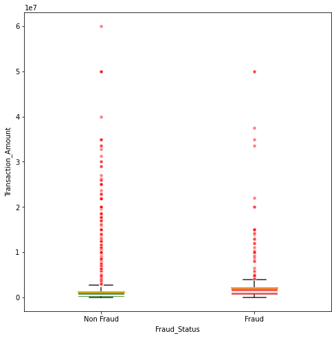

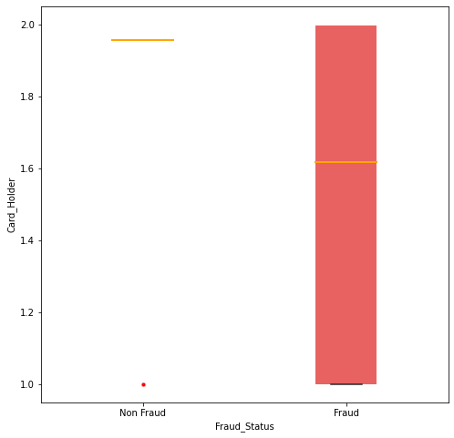

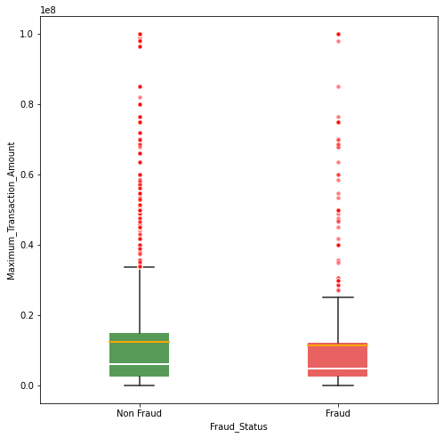

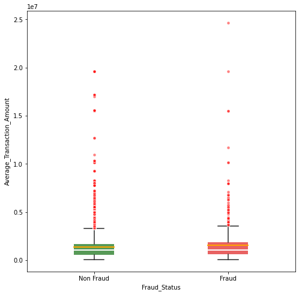

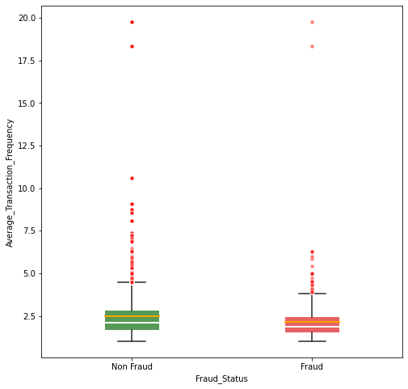

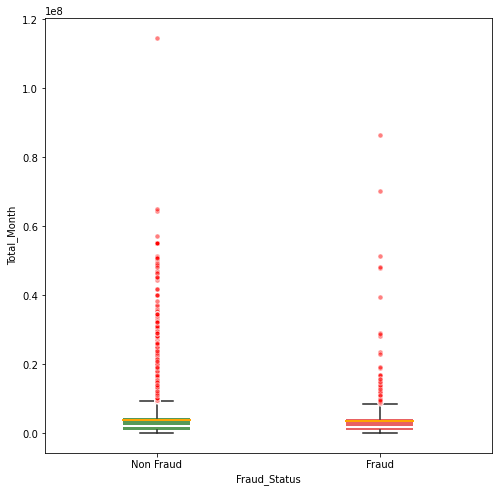

```python
for var in glm_vars:
    plt.figure()
    target_boxplot(data2, var, target=response, labels=['Non Fraud', 'Fraud'])
```

### Model

```python
import h2o
h2o.init()
```

```
Checking whether there is an H2O instance running at http://localhost:54321 ..... not found.
Attempting to start a local H2O server...
; OpenJDK 64-Bit Server VM Zulu11.43+55-CA (build 11.0.9.1+1-LTS, mixed mode)
  Starting server from C:\Users\Hp\anaconda3\Lib\site-packages\h2o\backend\bin\h2o.jar
  Ice root: C:\Users\Hp\AppData\Local\Temp\tmp_2abxffk
  JVM stdout: C:\Users\Hp\AppData\Local\Temp\tmp_2abxffk\h2o_Hp_started_from_python.out
  JVM stderr: C:\Users\Hp\AppData\Local\Temp\tmp_2abxffk\h2o_Hp_started_from_python.err
  Server is running at http://127.0.0.1:54321
Connecting to H2O server at http://127.0.0.1:54321 ... successful.
```

| H2O_cluster_uptime: | 08 secs |
| --- | --- |
| H2O_cluster_timezone: | Asia/Bangkok |
| H2O_data_parsing_timezone: | UTC |
| H2O_cluster_version: | 3.32.1.2 |
| H2O_cluster_version_age: | 2 months and 19 days |
| H2O_cluster_name: | H2O_from_python_Hp_n1iv6h |
| H2O_cluster_total_nodes: | 1 |
| H2O_cluster_free_memory: | 994 Mb |
| H2O_cluster_total_cores: | 2 |
| H2O_cluster_allowed_cores: | 2 |
| H2O_cluster_status: | accepting new members, healthy |
| H2O_connection_url: | http://127.0.0.1:54321 |
| H2O_connection_proxy: | {"http": null, "https": null} |
| H2O_internal_security: | False |
| H2O_API_Extensions: | Amazon S3, Algos, AutoML, Core V3, TargetEncoder, Core V4 |
| Python_version: | 3.8.5 final |

```python
from h2o.automl import H2OAutoML
```

```python
def timer(start_time, header='\nProgram Schedule'):
    end_time = pd.to_datetime('now') + pd.Timedelta('07:00:00')
    print(header)
    print(start_time.strftime('Start   : %Y-%m-%d %I:%M:%S %p'))
    print(end_time.strftime('Finish  : %Y-%m-%d %I:%M:%S %p'))
    run_time = str(end_time - start_time)
    idx1 = run_time.find(' ', 3) + 1
    idx2 = run_time.find('.')
    print('Runtime :', run_time[idx1 : idx2], '\n')
```

Split data menjadi train dan test sebanyak 30x

```python
from sklearn.model_selection import train_test_split

start_time = pd.to_datetime('now') + pd.Timedelta('07:00:00')
trains = []
tests = []

for i in range(0,30):

    train, test = train_test_split(data2, test_size=0.25, stratify=data2[response])
    train = h2o.H2OFrame(train)
    test = h2o.H2OFrame(test)
    train[response] = train[response].asfactor()
    test[response] = test[response].asfactor()
    trains.append(train)
    tests.append(test)

timer(start_time, header='\nConverting DataFrame to H2O Frame')
```

[output not shown]

[output cut: 10 more lines]

```
Parse progress: |█████████████████████████████████████████████████████████| 100%
Parse progress: |█████████████████████████████████████████████████████████| 100%
Parse progress: |█████████████████████████████████████████████████████████| 100%
Parse progress: |█████████████████████████████████████████████████████████| 100%
Parse progress: |█████████████████████████████████████████████████████████| 100%
Parse progress: |█████████████████████████████████████████████████████████| 100%
Parse progress: |█████████████████████████████████████████████████████████| 100%
Parse progress: |█████████████████████████████████████████████████████████| 100%
Parse progress: |█████████████████████████████████████████████████████████| 100%
Parse progress: |█████████████████████████████████████████████████████████| 100%

Converting DataFrame to H2O Frame
Start   : 2021-07-19 10:14:15 AM
Finish  : 2021-07-19 10:16:05 AM
Runtime : 00:01:49
```

# GBM

```python
start_time = pd.to_datetime('now') + pd.Timedelta('07:00:00')
TBM = H2OAutoML(max_runtime_secs=300, nfolds=10, include_algos=['GBM'])
TBM.train(x=glm_vars, y=response, training_frame=trains[1], validation_frame=tests[1])
timer(start_time, header='\nModeling')


gbm = TBM.leader
gbm
```

```
AutoML progress: |
05:13:42.225: User specified a validation frame with cross-validation still enabled. Please note that the models will still be validated using cross-validation only, the validation frame will be used to provide purely informative validation metrics on the trained models.

████████████████████████████████████████████████████████| 100%

Modeling
Start   : 2021-07-19 05:13:41 AM
Finish  : 2021-07-19 05:17:22 AM
Runtime : 00:03:40

Model Details
=============
H2OGradientBoostingEstimator :  Gradient Boosting Machine
Model Key:  GBM_1_AutoML_20210719_051342


Model Summary:
```

|  |  | number_of_trees | number_of_internal_trees | model_size_in_bytes | min_depth | max_depth | mean_depth | min_leaves | max_leaves | mean_leaves |
| --- | --- | --- | --- | --- | --- | --- | --- | --- | --- | --- |
| 0 |  | 40.0 | 40.0 | 28557.0 | 6.0 | 6.0 | 6.0 | 33.0 | 63.0 | 52.175 |

```
ModelMetricsBinomial: gbm
** Reported on train data. **

MSE: 0.03252322445949639
RMSE: 0.18034196533113525
LogLoss: 0.13054188224415134
Mean Per-Class Error: 0.1479580591328442
AUC: 0.9290622280798294
AUCPR: 0.7518415496517374
Gini: 0.8581244561596588

Confusion Matrix (Act/Pred) for max f1 @ threshold = 0.2428057165724838:
```

|  |  | 0 | 1 | Error | Rate |
| --- | --- | --- | --- | --- | --- |
| 0 | 0 | 7213.0 | 116.0 | 0.0158 | (116.0/7329.0) |
| 1 | 1 | 187.0 | 359.0 | 0.3425 | (187.0/546.0) |
| 2 | Total | 7400.0 | 475.0 | 0.0385 | (303.0/7875.0) |

```
Maximum Metrics: Maximum metrics at their respective thresholds
```

|  | metric | threshold | value | idx |
| --- | --- | --- | --- | --- |
| 0 | max f1 | 0.242806 | 0.703232 | 176.0 |
| 1 | max f2 | 0.160240 | 0.696852 | 209.0 |
| 2 | max f0point5 | 0.424014 | 0.803269 | 122.0 |
| 3 | max accuracy | 0.324477 | 0.964571 | 148.0 |
| 4 | max precision | 0.968996 | 1.000000 | 0.0 |
| 5 | max recall | 0.017020 | 1.000000 | 376.0 |
| 6 | max specificity | 0.968996 | 1.000000 | 0.0 |
| 7 | max absolute_mcc | 0.324477 | 0.692750 | 148.0 |
| 8 | max min_per_class_accuracy | 0.056495 | 0.838828 | 292.0 |
| 9 | max mean_per_class_accuracy | 0.092068 | 0.852042 | 254.0 |
| 10 | max tns | 0.968996 | 7329.000000 | 0.0 |
| 11 | max fns | 0.968996 | 545.000000 | 0.0 |
| 12 | max fps | 0.007290 | 7329.000000 | 399.0 |
| 13 | max tps | 0.017020 | 546.000000 | 376.0 |
| 14 | max tnr | 0.968996 | 1.000000 | 0.0 |
| 15 | max fnr | 0.968996 | 0.998168 | 0.0 |
| 16 | max fpr | 0.007290 | 1.000000 | 399.0 |
| 17 | max tpr | 0.017020 | 1.000000 | 376.0 |

```
Gains/Lift Table: Avg response rate:  6.93 %, avg score:  6.96 %
```

|  | group | cumulative_data_fraction | lower_threshold | lift | cumulative_lift | response_rate | score | cumulative_response_rate | cumulative_score | capture_rate | cumulative_capture_rate | gain | cumulative_gain | kolmogorov_smirnov |
| --- | --- | --- | --- | --- | --- | --- | --- | --- | --- | --- | --- | --- | --- | --- |
| 0 | 1 | 0.010032 | 0.795583 | 14.423077 | 14.423077 | 1.000000 | 0.858652 | 1.000000 | 0.858652 | 0.144689 | 0.144689 | 1342.307692 | 1342.307692 | 0.144689 |
| 1 | 2 | 0.020063 | 0.694878 | 14.423077 | 14.423077 | 1.000000 | 0.747468 | 1.000000 | 0.803060 | 0.144689 | 0.289377 | 1342.307692 | 1342.307692 | 0.289377 |
| 2 | 3 | 0.030095 | 0.543108 | 13.145083 | 13.997079 | 0.911392 | 0.625424 | 0.970464 | 0.743848 | 0.131868 | 0.421245 | 1214.508277 | 1299.707887 | 0.420290 |
| 3 | 4 | 0.040000 | 0.411627 | 10.724852 | 13.186813 | 0.743590 | 0.475002 | 0.914286 | 0.677277 | 0.106227 | 0.527473 | 972.485207 | 1218.681319 | 0.523789 |
| 4 | 5 | 0.050032 | 0.307518 | 7.302824 | 12.007029 | 0.506329 | 0.349359 | 0.832487 | 0.611527 | 0.073260 | 0.600733 | 630.282376 | 1100.702850 | 0.591727 |
| 5 | 6 | 0.100063 | 0.120904 | 2.965150 | 7.486089 | 0.205584 | 0.191818 | 0.519036 | 0.401672 | 0.148352 | 0.749084 | 196.515033 | 648.608942 | 0.697372 |
| 6 | 7 | 0.150095 | 0.074702 | 0.915170 | 5.295783 | 0.063452 | 0.093269 | 0.367174 | 0.298871 | 0.045788 | 0.794872 | -8.483014 | 429.578290 | 0.692811 |
| 7 | 8 | 0.200000 | 0.057661 | 0.844099 | 4.184982 | 0.058524 | 0.065444 | 0.290159 | 0.240625 | 0.042125 | 0.836996 | -15.590135 | 318.498168 | 0.684452 |
| 8 | 9 | 0.300063 | 0.042375 | 0.732136 | 3.033546 | 0.050761 | 0.048547 | 0.210326 | 0.176572 | 0.073260 | 0.910256 | -26.786412 | 203.354601 | 0.655651 |
| 9 | 10 | 0.400000 | 0.035694 | 0.274900 | 2.344322 | 0.019060 | 0.038953 | 0.162540 | 0.142189 | 0.027473 | 0.937729 | -72.510019 | 134.432234 | 0.577789 |
| 10 | 11 | 0.500063 | 0.028737 | 0.164731 | 1.908183 | 0.011421 | 0.032271 | 0.132301 | 0.120194 | 0.016484 | 0.954212 | -83.526943 | 90.818260 | 0.487982 |
| 11 | 12 | 0.600000 | 0.023968 | 0.183267 | 1.620879 | 0.012706 | 0.026113 | 0.112381 | 0.104524 | 0.018315 | 0.972527 | -81.673346 | 62.087912 | 0.400280 |
| 12 | 13 | 0.699937 | 0.020714 | 0.164940 | 1.413001 | 0.011436 | 0.022325 | 0.097968 | 0.092788 | 0.016484 | 0.989011 | -83.506011 | 41.300100 | 0.310610 |
| 13 | 14 | 0.800127 | 0.017207 | 0.091401 | 1.247513 | 0.006337 | 0.018951 | 0.086494 | 0.083542 | 0.009158 | 0.998168 | -90.859901 | 24.751260 | 0.212795 |
| 14 | 15 | 0.899937 | 0.013633 | 0.018350 | 1.111190 | 0.001272 | 0.015410 | 0.077042 | 0.075986 | 0.001832 | 1.000000 | -98.165003 | 11.118950 | 0.107518 |
| 15 | 16 | 1.000000 | 0.006601 | 0.000000 | 1.000000 | 0.000000 | 0.011787 | 0.069333 | 0.069562 | 0.000000 | 1.000000 | -100.000000 | 0.000000 | 0.000000 |

```
ModelMetricsBinomial: gbm
** Reported on validation data. **

MSE: 0.05167085753296284
RMSE: 0.2273122467729419
LogLoss: 0.19679632208622952
Mean Per-Class Error: 0.2556125822601467
AUC: 0.7980763608066105
AUCPR: 0.39819268221259685
Gini: 0.596152721613221

Confusion Matrix (Act/Pred) for max f1 @ threshold = 0.22184108747183368:
```

|  |  | 0 | 1 | Error | Rate |
| --- | --- | --- | --- | --- | --- |
| 0 | 0 | 2345.0 | 98.0 | 0.0401 | (98.0/2443.0) |
| 1 | 1 | 102.0 | 80.0 | 0.5604 | (102.0/182.0) |
| 2 | Total | 2447.0 | 178.0 | 0.0762 | (200.0/2625.0) |

```
Maximum Metrics: Maximum metrics at their respective thresholds
```

|  | metric | threshold | value | idx |
| --- | --- | --- | --- | --- |
| 0 | max f1 | 0.221841 | 0.444444 | 137.0 |
| 1 | max f2 | 0.106074 | 0.487106 | 203.0 |
| 2 | max f0point5 | 0.317260 | 0.504587 | 99.0 |
| 3 | max accuracy | 0.469267 | 0.938286 | 68.0 |
| 4 | max precision | 0.959696 | 1.000000 | 0.0 |
| 5 | max recall | 0.013589 | 1.000000 | 384.0 |
| 6 | max specificity | 0.959696 | 1.000000 | 0.0 |
| 7 | max absolute_mcc | 0.317260 | 0.418487 | 99.0 |
| 8 | max min_per_class_accuracy | 0.043971 | 0.714286 | 286.0 |
| 9 | max mean_per_class_accuracy | 0.071052 | 0.744387 | 242.0 |
| 10 | max tns | 0.959696 | 2443.000000 | 0.0 |
| 11 | max fns | 0.959696 | 181.000000 | 0.0 |
| 12 | max fps | 0.007970 | 2443.000000 | 399.0 |
| 13 | max tps | 0.013589 | 182.000000 | 384.0 |
| 14 | max tnr | 0.959696 | 1.000000 | 0.0 |
| 15 | max fnr | 0.959696 | 0.994505 | 0.0 |
| 16 | max fpr | 0.007970 | 1.000000 | 399.0 |
| 17 | max tpr | 0.013589 | 1.000000 | 384.0 |

```
Gains/Lift Table: Avg response rate:  6.93 %, avg score:  6.87 %
```

|  | group | cumulative_data_fraction | lower_threshold | lift | cumulative_lift | response_rate | score | cumulative_response_rate | cumulative_score | capture_rate | cumulative_capture_rate | gain | cumulative_gain | kolmogorov_smirnov |
| --- | --- | --- | --- | --- | --- | --- | --- | --- | --- | --- | --- | --- | --- | --- |
| 0 | 1 | 0.010286 | 0.719066 | 10.149573 | 10.149573 | 0.703704 | 0.801722 | 0.703704 | 0.801722 | 0.104396 | 0.104396 | 914.957265 | 914.957265 | 0.101121 |
| 1 | 2 | 0.020190 | 0.593570 | 7.766272 | 8.980406 | 0.538462 | 0.657584 | 0.622642 | 0.731013 | 0.076923 | 0.181319 | 676.627219 | 798.040639 | 0.173132 |
| 2 | 3 | 0.030095 | 0.481798 | 8.321006 | 8.763389 | 0.576923 | 0.534804 | 0.607595 | 0.666438 | 0.082418 | 0.263736 | 732.100592 | 776.338851 | 0.251047 |
| 3 | 4 | 0.040000 | 0.345026 | 6.102071 | 8.104396 | 0.423077 | 0.406182 | 0.561905 | 0.601994 | 0.060440 | 0.324176 | 510.207101 | 710.439560 | 0.305347 |
| 4 | 5 | 0.050286 | 0.304481 | 5.341880 | 7.539336 | 0.370370 | 0.319884 | 0.522727 | 0.544289 | 0.054945 | 0.379121 | 434.188034 | 653.933566 | 0.353333 |
| 5 | 6 | 0.100190 | 0.136035 | 2.532296 | 5.045335 | 0.175573 | 0.203569 | 0.349810 | 0.374577 | 0.126374 | 0.505495 | 153.229595 | 404.533489 | 0.435499 |
| 6 | 7 | 0.150095 | 0.087183 | 1.651497 | 3.916927 | 0.114504 | 0.106097 | 0.271574 | 0.285311 | 0.082418 | 0.587912 | 65.149736 | 291.692698 | 0.470434 |
| 7 | 8 | 0.200000 | 0.064420 | 1.100998 | 3.214286 | 0.076336 | 0.074488 | 0.222857 | 0.232705 | 0.054945 | 0.642857 | 10.099824 | 221.428571 | 0.475849 |
| 8 | 9 | 0.300190 | 0.044365 | 0.658087 | 2.361138 | 0.045627 | 0.052281 | 0.163706 | 0.172487 | 0.065934 | 0.708791 | -34.191284 | 136.113823 | 0.439041 |
| 9 | 10 | 0.400000 | 0.036751 | 0.660599 | 1.936813 | 0.045802 | 0.040271 | 0.134286 | 0.139496 | 0.065934 | 0.774725 | -33.940106 | 93.681319 | 0.402642 |
| 10 | 11 | 0.500190 | 0.029127 | 0.603247 | 1.669694 | 0.041825 | 0.033078 | 0.115765 | 0.118180 | 0.060440 | 0.835165 | -39.675344 | 66.969360 | 0.359929 |
| 11 | 12 | 0.600000 | 0.024482 | 0.330299 | 1.446886 | 0.022901 | 0.026557 | 0.100317 | 0.102939 | 0.032967 | 0.868132 | -66.970053 | 44.688645 | 0.288107 |
| 12 | 13 | 0.700190 | 0.021009 | 0.383884 | 1.294781 | 0.026616 | 0.022684 | 0.089771 | 0.091455 | 0.038462 | 0.906593 | -61.611582 | 29.478112 | 0.221780 |
| 13 | 14 | 0.800000 | 0.017356 | 0.495449 | 1.195055 | 0.034351 | 0.019331 | 0.082857 | 0.082457 | 0.049451 | 0.956044 | -50.455079 | 19.505495 | 0.167669 |
| 14 | 15 | 0.899810 | 0.013705 | 0.385349 | 1.105240 | 0.026718 | 0.015503 | 0.076630 | 0.075030 | 0.038462 | 0.994505 | -61.465062 | 10.524002 | 0.101751 |
| 15 | 16 | 1.000000 | 0.007763 | 0.054841 | 1.000000 | 0.003802 | 0.011870 | 0.069333 | 0.068702 | 0.005495 | 1.000000 | -94.515940 | 0.000000 | 0.000000 |

```
ModelMetricsBinomial: gbm
** Reported on cross-validation data. **

MSE: 0.05083079439366165
RMSE: 0.2254568570562041
LogLoss: 0.19089228928459206
Mean Per-Class Error: 0.24053811517994905
AUC: 0.8252740005707668
AUCPR: 0.3998751593293601
Gini: 0.6505480011415337

Confusion Matrix (Act/Pred) for max f1 @ threshold = 0.20009715078421159:
```

|  |  | 0 | 1 | Error | Rate |
| --- | --- | --- | --- | --- | --- |
| 0 | 0 | 7022.0 | 307.0 | 0.0419 | (307.0/7329.0) |
| 1 | 1 | 286.0 | 260.0 | 0.5238 | (286.0/546.0) |
| 2 | Total | 7308.0 | 567.0 | 0.0753 | (593.0/7875.0) |

```
Maximum Metrics: Maximum metrics at their respective thresholds
```

|  | metric | threshold | value | idx |
| --- | --- | --- | --- | --- |
| 0 | max f1 | 0.200097 | 0.467206 | 185.0 |
| 1 | max f2 | 0.097201 | 0.512981 | 246.0 |
| 2 | max f0point5 | 0.424990 | 0.497497 | 111.0 |
| 3 | max accuracy | 0.452017 | 0.938032 | 104.0 |
| 4 | max precision | 0.991315 | 1.000000 | 0.0 |
| 5 | max recall | 0.007110 | 1.000000 | 397.0 |
| 6 | max specificity | 0.991315 | 1.000000 | 0.0 |
| 7 | max absolute_mcc | 0.200097 | 0.426795 | 185.0 |
| 8 | max min_per_class_accuracy | 0.045475 | 0.738095 | 305.0 |
| 9 | max mean_per_class_accuracy | 0.071143 | 0.759462 | 269.0 |
| 10 | max tns | 0.991315 | 7329.000000 | 0.0 |
| 11 | max fns | 0.991315 | 545.000000 | 0.0 |
| 12 | max fps | 0.002928 | 7329.000000 | 399.0 |
| 13 | max tps | 0.007110 | 546.000000 | 397.0 |
| 14 | max tnr | 0.991315 | 1.000000 | 0.0 |
| 15 | max fnr | 0.991315 | 0.998168 | 0.0 |
| 16 | max fpr | 0.002928 | 1.000000 | 399.0 |
| 17 | max tpr | 0.007110 | 1.000000 | 397.0 |

```
Gains/Lift Table: Avg response rate:  6.93 %, avg score:  6.74 %
```

|  | group | cumulative_data_fraction | lower_threshold | lift | cumulative_lift | response_rate | score | cumulative_response_rate | cumulative_score | capture_rate | cumulative_capture_rate | gain | cumulative_gain | kolmogorov_smirnov |
| --- | --- | --- | --- | --- | --- | --- | --- | --- | --- | --- | --- | --- | --- | --- |
| 0 | 1 | 0.010032 | 0.700800 | 9.676241 | 9.676241 | 0.670886 | 0.803768 | 0.670886 | 0.803768 | 0.097070 | 0.097070 | 867.624148 | 867.624148 | 0.093522 |
| 1 | 2 | 0.020063 | 0.568285 | 8.398247 | 9.037244 | 0.582278 | 0.623972 | 0.626582 | 0.713870 | 0.084249 | 0.181319 | 739.824732 | 803.724440 | 0.173268 |
| 2 | 3 | 0.030095 | 0.463601 | 8.580818 | 8.885102 | 0.594937 | 0.514712 | 0.616034 | 0.647484 | 0.086081 | 0.267399 | 758.081792 | 788.510224 | 0.254983 |
| 3 | 4 | 0.040000 | 0.370124 | 6.102071 | 8.195971 | 0.423077 | 0.408621 | 0.568254 | 0.588337 | 0.060440 | 0.327839 | 510.207101 | 719.597070 | 0.309282 |
| 4 | 5 | 0.050032 | 0.301169 | 4.746835 | 7.504393 | 0.329114 | 0.333280 | 0.520305 | 0.537196 | 0.047619 | 0.375458 | 374.683544 | 650.439282 | 0.349670 |
| 5 | 6 | 0.100063 | 0.133619 | 3.404432 | 5.454412 | 0.236041 | 0.198355 | 0.378173 | 0.367776 | 0.170330 | 0.545788 | 240.443186 | 445.441234 | 0.478930 |
| 6 | 7 | 0.150095 | 0.079413 | 1.647306 | 4.185377 | 0.114213 | 0.102566 | 0.290186 | 0.279372 | 0.082418 | 0.628205 | 64.730574 | 318.537681 | 0.513728 |
| 7 | 8 | 0.200000 | 0.059698 | 0.990898 | 3.388278 | 0.068702 | 0.068517 | 0.234921 | 0.226759 | 0.049451 | 0.677656 | -0.910159 | 238.827839 | 0.513240 |
| 8 | 9 | 0.300063 | 0.044429 | 0.695529 | 2.490315 | 0.048223 | 0.050840 | 0.172662 | 0.168094 | 0.069597 | 0.747253 | -30.447091 | 149.031544 | 0.480504 |
| 9 | 10 | 0.400000 | 0.036046 | 0.733066 | 2.051282 | 0.050826 | 0.039831 | 0.142222 | 0.136049 | 0.073260 | 0.820513 | -26.693383 | 105.128205 | 0.451840 |
| 10 | 11 | 0.500063 | 0.029631 | 0.384371 | 1.717731 | 0.026650 | 0.032644 | 0.119096 | 0.115357 | 0.038462 | 0.858974 | -61.562866 | 71.773059 | 0.385649 |
| 11 | 12 | 0.600000 | 0.025105 | 0.494820 | 1.514042 | 0.034307 | 0.027219 | 0.104974 | 0.100677 | 0.049451 | 0.908425 | -50.518033 | 51.404151 | 0.331402 |
| 12 | 13 | 0.699937 | 0.021269 | 0.311553 | 1.342351 | 0.021601 | 0.023169 | 0.093070 | 0.089610 | 0.031136 | 0.939560 | -68.844688 | 34.235095 | 0.257476 |
| 13 | 14 | 0.800000 | 0.017703 | 0.201337 | 1.199634 | 0.013959 | 0.019521 | 0.083175 | 0.080844 | 0.020147 | 0.959707 | -79.866263 | 19.963370 | 0.171605 |
| 14 | 15 | 0.899937 | 0.013841 | 0.164940 | 1.084733 | 0.011436 | 0.015800 | 0.075208 | 0.073621 | 0.016484 | 0.976190 | -83.506011 | 8.473261 | 0.081935 |
| 15 | 16 | 1.000000 | 0.002928 | 0.237944 | 1.000000 | 0.016497 | 0.011116 | 0.069333 | 0.067366 | 0.023810 | 1.000000 | -76.205584 | 0.000000 | 0.000000 |

```
Cross-Validation Metrics Summary:
```

|  |  | mean | sd | cv_1_valid | cv_2_valid | cv_3_valid | cv_4_valid | cv_5_valid | cv_6_valid | cv_7_valid | cv_8_valid | cv_9_valid | cv_10_valid |
| --- | --- | --- | --- | --- | --- | --- | --- | --- | --- | --- | --- | --- | --- |
| 0 | accuracy | 0.9274897 | 0.01324752 | 0.9162437 | 0.9390863 | 0.930203 | 0.92893404 | 0.94162434 | 0.93265563 | 0.90343076 | 0.9224905 | 0.91486657 | 0.94536215 |
| 1 | auc | 0.82132703 | 0.056156497 | 0.8256609 | 0.8821477 | 0.82546526 | 0.7737538 | 0.6843602 | 0.8495574 | 0.8332674 | 0.8691584 | 0.8313953 | 0.838504 |
| 2 | aucpr | 0.39741227 | 0.075512744 | 0.39603463 | 0.45225525 | 0.40062478 | 0.39119312 | 0.21665026 | 0.44715407 | 0.40449128 | 0.36917466 | 0.38872913 | 0.50781566 |
| 3 | err | 0.0725103 | 0.01324752 | 0.08375634 | 0.060913704 | 0.06979696 | 0.07106599 | 0.058375634 | 0.067344345 | 0.09656925 | 0.07750953 | 0.08513342 | 0.054637864 |
| 4 | err_count | 57.1 | 10.418467 | 66.0 | 48.0 | 55.0 | 56.0 | 46.0 | 53.0 | 76.0 | 61.0 | 67.0 | 43.0 |
| 5 | f0point5 | 0.48784932 | 0.07168045 | 0.44554454 | 0.5645161 | 0.49833888 | 0.47511312 | 0.3723404 | 0.5576208 | 0.44083527 | 0.46153846 | 0.4494382 | 0.6132075 |
| 6 | f1 | 0.48799098 | 0.054011192 | 0.45 | 0.53846157 | 0.5217391 | 0.42857143 | 0.3783784 | 0.53097343 | 0.5 | 0.49586776 | 0.48854962 | 0.5473684 |
| 7 | f2 | 0.49410388 | 0.06508134 | 0.45454547 | 0.5147059 | 0.54744524 | 0.39033458 | 0.3846154 | 0.5067568 | 0.5775076 | 0.53571427 | 0.53511703 | 0.49429658 |
| 8 | lift_top_group | 9.336093 | 2.225464 | 10.016949 | 10.553572 | 9.292453 | 12.096491 | 8.208333 | 6.4508195 | 8.336864 | 5.568396 | 10.540178 | 12.296875 |
| 9 | logloss | 0.1908923 | 0.013464464 | 0.20818806 | 0.18002416 | 0.18228847 | 0.21169181 | 0.1722006 | 0.19721496 | 0.2004476 | 0.18206072 | 0.19530006 | 0.17950653 |
| 10 | max_per_class_error | 0.49814022 | 0.086500995 | 0.5423729 | 0.5 | 0.43396226 | 0.6315789 | 0.6111111 | 0.5081967 | 0.3559322 | 0.43396226 | 0.42857143 | 0.53571427 |
| 11 | mcc | 0.45413575 | 0.056121055 | 0.4047498 | 0.50778294 | 0.48607582 | 0.39781055 | 0.34791595 | 0.49677512 | 0.46378314 | 0.45872816 | 0.4488125 | 0.5289235 |
| 12 | mean_per_class_accuracy | 0.73037964 | 0.03685446 | 0.7054939 | 0.7363388 | 0.76125014 | 0.6705306 | 0.678487 | 0.73075014 | 0.7842592 | 0.7571333 | 0.75630254 | 0.7232509 |
| 13 | mean_per_class_error | 0.26962033 | 0.03685446 | 0.29450604 | 0.2636612 | 0.23874985 | 0.32946935 | 0.321513 | 0.2692499 | 0.21574083 | 0.2428667 | 0.24369748 | 0.27674907 |
| 14 | mse | 0.050831348 | 0.004643927 | 0.05612617 | 0.04881245 | 0.048251938 | 0.054904245 | 0.04171629 | 0.05433204 | 0.05498874 | 0.050522942 | 0.052608903 | 0.046049748 |
| 15 | pr_auc | 0.39741227 | 0.075512744 | 0.39603463 | 0.45225525 | 0.40062478 | 0.39119312 | 0.21665026 | 0.44715407 | 0.40449128 | 0.36917466 | 0.38872913 | 0.50781566 |
| 16 | precision | 0.49104786 | 0.09312091 | 0.44262296 | 0.5833333 | 0.48387095 | 0.5121951 | 0.36842105 | 0.5769231 | 0.40860215 | 0.44117647 | 0.42666668 | 0.6666667 |
| 17 | r2 | 0.20561992 | 0.06806978 | 0.18971406 | 0.2605924 | 0.23086247 | 0.18178749 | 0.043163463 | 0.24013048 | 0.20706092 | 0.1956109 | 0.20401786 | 0.30325907 |
| 18 | recall | 0.5018598 | 0.086500995 | 0.45762712 | 0.5 | 0.5660377 | 0.36842105 | 0.3888889 | 0.4918033 | 0.6440678 | 0.5660377 | 0.5714286 | 0.4642857 |
| 19 | rmse | 0.2252391 | 0.010471797 | 0.23690963 | 0.22093539 | 0.21966325 | 0.23431654 | 0.20424566 | 0.23309234 | 0.23449677 | 0.2247731 | 0.22936632 | 0.21459205 |

```
See the whole table with table.as_data_frame()

Scoring History:
```

|  |  | timestamp | duration | number_of_trees | training_rmse | training_logloss | training_auc | training_pr_auc | training_lift | training_classification_error | validation_rmse | validation_logloss | validation_auc | validation_pr_auc | validation_lift | validation_classification_error |
| --- | --- | --- | --- | --- | --- | --- | --- | --- | --- | --- | --- | --- | --- | --- | --- | --- |
| 0 |  | 2021-07-19 05:13:58 | 16.185 sec | 0.0 | 0.254020 | 0.251911 | 0.500000 | 0.069333 | 1.000000 | 0.930667 | 0.254020 | 0.251911 | 0.500000 | 0.069333 | 1.000000 | 0.930667 |
| 1 |  | 2021-07-19 05:13:59 | 16.325 sec | 5.0 | 0.224987 | 0.193307 | 0.868339 | 0.586288 | 13.875365 | 0.050413 | 0.237371 | 0.213952 | 0.796316 | 0.357083 | 10.149573 | 0.070476 |
| 2 |  | 2021-07-19 05:13:59 | 16.450 sec | 10.0 | 0.211423 | 0.174455 | 0.878896 | 0.618884 | 14.057936 | 0.046857 | 0.232224 | 0.204335 | 0.797179 | 0.356765 | 8.012821 | 0.070095 |
| 3 |  | 2021-07-19 05:13:59 | 16.576 sec | 15.0 | 0.202752 | 0.161398 | 0.895075 | 0.659879 | 14.240506 | 0.046222 | 0.229949 | 0.200209 | 0.800420 | 0.371004 | 9.081197 | 0.068571 |
| 4 |  | 2021-07-19 05:13:59 | 16.701 sec | 20.0 | 0.196190 | 0.152762 | 0.903830 | 0.682400 | 14.240506 | 0.043429 | 0.228054 | 0.197323 | 0.801588 | 0.388580 | 9.081197 | 0.071238 |
| 5 |  | 2021-07-19 05:13:59 | 16.826 sec | 25.0 | 0.192402 | 0.146923 | 0.910665 | 0.702058 | 14.240506 | 0.042413 | 0.227533 | 0.196495 | 0.801345 | 0.390100 | 9.081197 | 0.072381 |
| 6 |  | 2021-07-19 05:13:59 | 16.919 sec | 30.0 | 0.188075 | 0.140645 | 0.917848 | 0.722681 | 14.240506 | 0.040889 | 0.227504 | 0.196635 | 0.801224 | 0.393525 | 10.149573 | 0.075429 |
| 7 |  | 2021-07-19 05:13:59 | 17.029 sec | 35.0 | 0.184052 | 0.135574 | 0.922778 | 0.735692 | 14.423077 | 0.039746 | 0.227522 | 0.196632 | 0.801483 | 0.396444 | 10.683761 | 0.072762 |
| 8 |  | 2021-07-19 05:13:59 | 17.138 sec | 40.0 | 0.180342 | 0.130542 | 0.929062 | 0.751842 | 14.423077 | 0.038476 | 0.227312 | 0.196796 | 0.798076 | 0.398193 | 10.149573 | 0.076190 |

```
Variable Importances:
```

|  | variable | relative_importance | scaled_importance | percentage |
| --- | --- | --- | --- | --- |
| 0 | Card_Holder | 254.698578 | 1.000000 | 0.247161 |
| 1 | Transaction_Amount | 205.241592 | 0.805822 | 0.199168 |
| 2 | Average_Transaction_Frequency | 173.287628 | 0.680364 | 0.168160 |
| 3 | Maximum_Transaction_Amount | 151.222153 | 0.593730 | 0.146747 |
| 4 | Average_Transaction_Amount | 131.477768 | 0.516209 | 0.127587 |
| 5 | Total_Month | 114.567207 | 0.449815 | 0.111177 |

```python
def model_performance(model, threshold, train=False, valid=True, xval=False, header='Value', style=False):
    f1 = model.F1(train=train, valid=valid, xval=xval, thresholds=threshold)[0][1]
    precision = model.precision(train=train, valid=valid, xval=xval, thresholds=threshold)[0][1]
    sensitivity = model.recall(train=train, valid=valid, xval=xval, thresholds=threshold)[0][1]
    accuracy = model.accuracy(train=train, valid=valid, xval=xval, thresholds=threshold)[0][1]

    metrics = {'Threshold': threshold, 'F1': f1, 'Precision': precision, 'Sensitivity': sensitivity, 'Accuracy': accuracy}
    performance = pd.DataFrame(metrics.values(), columns=[header], index=metrics.keys())

    if style:
        performance = performance.style.format('{:.2%}')

    return performance
```

```python
f1_max_threshold = gbm.F1(valid=True)[0][0]
gbm_model_performance = model_performance(model=gbm, threshold=f1_max_threshold, header='GLM')
model_performance(model=gbm, threshold=f1_max_threshold, style=True)
```

|  | Value |
| --- | --- |
| Threshold | 22.18% |
| F1 | 44.44% |
| Precision | 44.94% |
| Sensitivity | 43.96% |
| Accuracy | 92.38% |

#### Global Interpretability

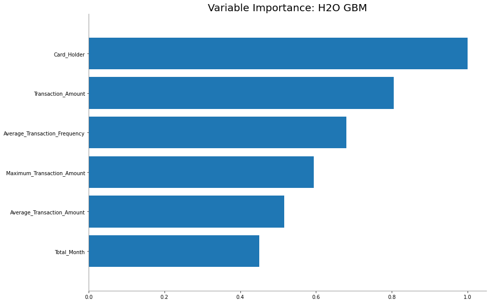

```python
gbm.varimp_plot()
```

```python
def variable_importances(model, limit=0.95):
    varimp = model.varimp(use_pandas=True)
    varimp['cumulative'] = varimp['percentage'].cumsum()
    varimp = varimp[varimp['cumulative'] <= limit].copy()

    return varimp
```

```python
varimp_gbm = variable_importances(gbm, limit=1)
varimp_gbm
```

|  | variable | relative_importance | scaled_importance | percentage | cumulative |
| --- | --- | --- | --- | --- | --- |
| 0 | Card_Holder | 254.698578 | 1.000000 | 0.247161 | 0.247161 |
| 1 | Transaction_Amount | 205.241592 | 0.805822 | 0.199168 | 0.446329 |
| 2 | Average_Transaction_Frequency | 173.287628 | 0.680364 | 0.168160 | 0.614489 |
| 3 | Maximum_Transaction_Amount | 151.222153 | 0.593730 | 0.146747 | 0.761236 |
| 4 | Average_Transaction_Amount | 131.477768 | 0.516209 | 0.127587 | 0.888823 |
| 5 | Total_Month | 114.567207 | 0.449815 | 0.111177 | 1.000000 |

### GBM run 30x

```python
model_gbm=[]
for i in range (30):
    gbm = H2OAutoML(max_runtime_secs=300, nfolds=0, include_algos=['GBM'])
    gbm.train(x=glm_vars, y=response, training_frame=trains[i], validation_frame=tests[i])
    model_gbm.append(gbm)
```

[output not shown]

```python
f1_total=[]
threshold_total=[]
precision_total=[]
sensitivity_total=[]
accuracy_total=[]
gbm_var=[]

for i in range (30):
    f1=model_gbm[i].leader.F1(train=False,valid=True,xval=False)[0][1]
    threshold = model_gbm[i].leader.F1(train=False,valid=True,xval=False)[0][0]
    precision=model_gbm[i].leader.precision(train=False,valid=True,xval=False,thresholds=threshold)[0][1]
    sensitivity=model_gbm[i].leader.sensitivity(train=False,valid=True,xval=False,thresholds=threshold)[0][1]
    accuracy=model_gbm[i].leader.accuracy(train=False,valid=True,xval=False,thresholds=threshold)[0][1]

    f1_total.append(f1)
    threshold_total.append(threshold)
    precision_total.append(precision)
    sensitivity_total.append(sensitivity)
    accuracy_total.append(accuracy)

    vars = variable_importances(model_gbm[i].leader,limit=1)
    gbm_var.append(vars)
```

```python
gbm=pd.DataFrame({'threshold':threshold_total,'sensitivity':sensitivity_total,'precision':precision_total
                            ,'accuracy':accuracy_total,'F1':f1_total})
gbm.describe()
```

|  | threshold | sensitivity | precision | accuracy | F1 |
| --- | --- | --- | --- | --- | --- |
| count | 30.000000 | 30.000000 | 30.000000 | 30.000000 | 30.000000 |
| mean | 0.215200 | 0.457326 | 0.474628 | 0.926083 | 0.462564 |
| std | 0.042023 | 0.039666 | 0.057759 | 0.008516 | 0.028995 |
| min | 0.149991 | 0.362637 | 0.365385 | 0.909333 | 0.385269 |
| 25% | 0.179581 | 0.439560 | 0.426593 | 0.918667 | 0.450140 |
| 50% | 0.219082 | 0.458791 | 0.482463 | 0.928571 | 0.468218 |
| 75% | 0.250187 | 0.482143 | 0.515622 | 0.932476 | 0.478057 |
| max | 0.303173 | 0.532967 | 0.590278 | 0.940571 | 0.521472 |

Rata-rata dan standar deviasi dari metric score dari 30 model GBM

```python
gbm_metric=gbm.describe().iloc[1:3].T
gbm_metric
```

|  | mean | std |
| --- | --- | --- |
| threshold | 0.215200 | 0.042023 |
| sensitivity | 0.457326 | 0.039666 |
| precision | 0.474628 | 0.057759 |
| accuracy | 0.926083 | 0.008516 |
| F1 | 0.462564 | 0.028995 |

```python
gbm_varimp = gbm_var[0]
for i in range (1,30):
    gbm_varimp=gbm_varimp.append(gbm_var[i])
```

Rata-rata percentage dan cumulative variabel importance dari 30 model GBM

```python
gbm_varimp = gbm_varimp.groupby(['variable'])[['percentage','cumulative']].mean().sort_values(by='percentage', ascending= False)
gbm_varimp
```

| variable | percentage | cumulative |
| --- | --- | --- |
| Card_Holder | 0.363307 | 0.392377 |
| Transaction_Amount | 0.200540 | 0.588743 |
| Average_Transaction_Frequency | 0.125643 | 0.757306 |
| Maximum_Transaction_Amount | 0.110347 | 0.845183 |
| Average_Transaction_Amount | 0.102838 | 0.882177 |
| Total_Month | 0.098720 | 0.896171 |

### GLM

```python
start_time = pd.to_datetime('now') + pd.Timedelta('07:00:00')
GLM = H2OAutoML(max_runtime_secs=300, nfolds=10, include_algos=['GLM'])
GLM.train(x=glm_vars, y=response, training_frame=trains[1], validation_frame=tests[1])
timer(start_time, header='\nModeling')

GLM = GLM.leader
GLM
```

```
AutoML progress: |
05:51:35.248: User specified a validation frame with cross-validation still enabled. Please note that the models will still be validated using cross-validation only, the validation frame will be used to provide purely informative validation metrics on the trained models.

████████████████████████████████████████████████████████| 100%

Modeling
Start   : 2021-07-19 05:51:35 AM
Finish  : 2021-07-19 05:51:47 AM
Runtime : 00:00:12

Model Details
=============
H2OGeneralizedLinearEstimator :  Generalized Linear Modeling
Model Key:  GLM_1_AutoML_20210719_055135


GLM Model: summary
```

|  |  | family | link | regularization | lambda_search | number_of_predictors_total | number_of_active_predictors | number_of_iterations | training_frame |
| --- | --- | --- | --- | --- | --- | --- | --- | --- | --- |
| 0 |  | binomial | logit | Ridge ( lambda = 0.004255 ) | nlambda = 30, lambda.max = 8.695, lambda.min = 0.004255, lambda.1s... | 6 | 6 | 34 | automl_training_py_1_sid_8a2a |

```
ModelMetricsBinomialGLM: glm
** Reported on train data. **

MSE: 0.05631988616498193
RMSE: 0.23731811175083525
LogLoss: 0.2141362742820061
Null degrees of freedom: 7874
Residual degrees of freedom: 7868
Null deviance: 3967.5992538710066
Residual deviance: 3372.646319941596
AIC: 3386.646319941596
AUC: 0.7732127675844418
AUCPR: 0.3006321989198034
Gini: 0.5464255351688836

Confusion Matrix (Act/Pred) for max f1 @ threshold = 0.08007698586533912:
```

|  |  | 0 | 1 | Error | Rate |
| --- | --- | --- | --- | --- | --- |
| 0 | 0 | 6933.0 | 396.0 | 0.054 | (396.0/7329.0) |
| 1 | 1 | 320.0 | 226.0 | 0.5861 | (320.0/546.0) |
| 2 | Total | 7253.0 | 622.0 | 0.0909 | (716.0/7875.0) |

```
Maximum Metrics: Maximum metrics at their respective thresholds
```

|  | metric | threshold | value | idx |
| --- | --- | --- | --- | --- |
| 0 | max f1 | 0.080077 | 0.386986 | 197.0 |
| 1 | max f2 | 0.059195 | 0.444028 | 227.0 |
| 2 | max f0point5 | 0.291220 | 0.397682 | 135.0 |
| 3 | max accuracy | 0.420922 | 0.932571 | 51.0 |
| 4 | max precision | 0.949007 | 1.000000 | 0.0 |
| 5 | max recall | 0.001166 | 1.000000 | 398.0 |
| 6 | max specificity | 0.949007 | 1.000000 | 0.0 |
| 7 | max absolute_mcc | 0.256596 | 0.343002 | 147.0 |
| 8 | max min_per_class_accuracy | 0.052052 | 0.705128 | 257.0 |
| 9 | max mean_per_class_accuracy | 0.054443 | 0.713669 | 245.0 |
| 10 | max tns | 0.949007 | 7329.000000 | 0.0 |
| 11 | max fns | 0.949007 | 545.000000 | 0.0 |
| 12 | max fps | 0.000519 | 7329.000000 | 399.0 |
| 13 | max tps | 0.001166 | 546.000000 | 398.0 |
| 14 | max tnr | 0.949007 | 1.000000 | 0.0 |
| 15 | max fnr | 0.949007 | 0.998168 | 0.0 |
| 16 | max fpr | 0.000519 | 1.000000 | 399.0 |
| 17 | max tpr | 0.001166 | 1.000000 | 398.0 |

```
Gains/Lift Table: Avg response rate:  6.93 %, avg score:  6.93 %
```

|  | group | cumulative_data_fraction | lower_threshold | lift | cumulative_lift | response_rate | score | cumulative_response_rate | cumulative_score | capture_rate | cumulative_capture_rate | gain | cumulative_gain | kolmogorov_smirnov |
| --- | --- | --- | --- | --- | --- | --- | --- | --- | --- | --- | --- | --- | --- | --- |
| 0 | 1 | 0.010032 | 0.438193 | 8.215677 | 8.215677 | 0.569620 | 0.491969 | 0.569620 | 0.491969 | 0.082418 | 0.082418 | 721.567673 | 721.567673 | 0.077778 |
| 1 | 2 | 0.020063 | 0.419321 | 7.302824 | 7.759250 | 0.506329 | 0.429017 | 0.537975 | 0.460493 | 0.073260 | 0.155678 | 630.282376 | 675.925024 | 0.145717 |
| 2 | 3 | 0.030095 | 0.402600 | 4.746835 | 6.755112 | 0.329114 | 0.411231 | 0.468354 | 0.444072 | 0.047619 | 0.203297 | 374.683544 | 575.511198 | 0.186105 |
| 3 | 4 | 0.040000 | 0.382635 | 3.883136 | 6.043956 | 0.269231 | 0.393914 | 0.419048 | 0.431652 | 0.038462 | 0.241758 | 288.313609 | 504.395604 | 0.216789 |
| 4 | 5 | 0.050032 | 0.358536 | 5.111977 | 5.857087 | 0.354430 | 0.371301 | 0.406091 | 0.419551 | 0.051282 | 0.293040 | 411.197663 | 485.708708 | 0.261112 |
| 5 | 6 | 0.100063 | 0.063041 | 3.294611 | 4.575849 | 0.228426 | 0.159850 | 0.317259 | 0.289700 | 0.164835 | 0.457875 | 229.461148 | 357.584928 | 0.384468 |
| 6 | 7 | 0.150095 | 0.057548 | 1.537485 | 3.563061 | 0.106599 | 0.059688 | 0.247039 | 0.213030 | 0.076923 | 0.534799 | 53.748536 | 256.306130 | 0.413363 |
| 7 | 8 | 0.200000 | 0.055391 | 1.137698 | 2.957875 | 0.078880 | 0.056452 | 0.205079 | 0.173960 | 0.056777 | 0.591575 | 13.769818 | 195.787546 | 0.420747 |
| 8 | 9 | 0.300063 | 0.052559 | 0.896866 | 2.270582 | 0.062183 | 0.053906 | 0.157427 | 0.133925 | 0.089744 | 0.681319 | -10.313354 | 127.058172 | 0.409658 |
| 9 | 10 | 0.400000 | 0.050291 | 0.733066 | 1.886447 | 0.050826 | 0.051350 | 0.130794 | 0.113294 | 0.073260 | 0.754579 | -26.693383 | 88.644689 | 0.380994 |
| 10 | 11 | 0.500063 | 0.048038 | 0.695529 | 1.648142 | 0.048223 | 0.049168 | 0.114271 | 0.100463 | 0.069597 | 0.824176 | -30.447091 | 64.814236 | 0.348258 |
| 11 | 12 | 0.600000 | 0.045502 | 0.384860 | 1.437729 | 0.026684 | 0.046817 | 0.099683 | 0.091527 | 0.038462 | 0.862637 | -61.514026 | 43.772894 | 0.282203 |
| 12 | 13 | 0.699937 | 0.042500 | 0.329880 | 1.279551 | 0.022872 | 0.044034 | 0.088716 | 0.084746 | 0.032967 | 0.895604 | -67.012022 | 27.955091 | 0.210245 |
| 13 | 14 | 0.800000 | 0.038416 | 0.366068 | 1.165293 | 0.025381 | 0.040553 | 0.080794 | 0.079219 | 0.036630 | 0.932234 | -63.393206 | 16.529304 | 0.142086 |
| 14 | 15 | 0.899937 | 0.032130 | 0.311553 | 1.070487 | 0.021601 | 0.035518 | 0.074220 | 0.074366 | 0.031136 | 0.963370 | -68.844688 | 7.048659 | 0.068159 |
| 15 | 16 | 1.000000 | 0.000349 | 0.366068 | 1.000000 | 0.025381 | 0.024074 | 0.069333 | 0.069333 | 0.036630 | 1.000000 | -63.393206 | 0.000000 | 0.000000 |

```
ModelMetricsBinomialGLM: glm
** Reported on validation data. **

MSE: 0.056600265653302013
RMSE: 0.23790810337880888
LogLoss: 0.21418391478903348
Null degrees of freedom: 2624
Residual degrees of freedom: 2618
Null deviance: 1322.533084623814
Residual deviance: 1124.4655526424258
AIC: 1138.4655526424258
AUC: 0.7676496651118019
AUCPR: 0.2910832306284505
Gini: 0.5352993302236038

Confusion Matrix (Act/Pred) for max f1 @ threshold = 0.2378869260464074:
```

|  |  | 0 | 1 | Error | Rate |
| --- | --- | --- | --- | --- | --- |
| 0 | 0 | 2321.0 | 122.0 | 0.0499 | (122.0/2443.0) |
| 1 | 1 | 109.0 | 73.0 | 0.5989 | (109.0/182.0) |
| 2 | Total | 2430.0 | 195.0 | 0.088 | (231.0/2625.0) |

```
Maximum Metrics: Maximum metrics at their respective thresholds
```

|  | metric | threshold | value | idx |
| --- | --- | --- | --- | --- |
| 0 | max f1 | 0.237887 | 0.387268 | 129.0 |
| 1 | max f2 | 0.055559 | 0.449264 | 217.0 |
| 2 | max f0point5 | 0.357265 | 0.404509 | 87.0 |
| 3 | max accuracy | 0.439840 | 0.933333 | 16.0 |
| 4 | max precision | 0.439840 | 0.666667 | 16.0 |
| 5 | max recall | 0.020894 | 1.000000 | 370.0 |
| 6 | max specificity | 0.780624 | 0.999591 | 0.0 |
| 7 | max absolute_mcc | 0.338839 | 0.344182 | 99.0 |
| 8 | max min_per_class_accuracy | 0.052637 | 0.714286 | 233.0 |
| 9 | max mean_per_class_accuracy | 0.054801 | 0.727746 | 220.0 |
| 10 | max tns | 0.780624 | 2442.000000 | 0.0 |
| 11 | max fns | 0.780624 | 182.000000 | 0.0 |
| 12 | max fps | 0.000427 | 2443.000000 | 399.0 |
| 13 | max tps | 0.020894 | 182.000000 | 370.0 |
| 14 | max tnr | 0.780624 | 0.999591 | 0.0 |
| 15 | max fnr | 0.780624 | 1.000000 | 0.0 |
| 16 | max fpr | 0.000427 | 1.000000 | 399.0 |
| 17 | max tpr | 0.020894 | 1.000000 | 370.0 |

```
Gains/Lift Table: Avg response rate:  6.93 %, avg score:  7.23 %
```

|  | group | cumulative_data_fraction | lower_threshold | lift | cumulative_lift | response_rate | score | cumulative_response_rate | cumulative_score | capture_rate | cumulative_capture_rate | gain | cumulative_gain | kolmogorov_smirnov |
| --- | --- | --- | --- | --- | --- | --- | --- | --- | --- | --- | --- | --- | --- | --- |
| 0 | 1 | 0.010286 | 0.434613 | 9.081197 | 9.081197 | 0.629630 | 0.473211 | 0.629630 | 0.473211 | 0.093407 | 0.093407 | 808.119658 | 808.119658 | 0.089313 |
| 1 | 2 | 0.020190 | 0.417371 | 4.992604 | 7.075472 | 0.346154 | 0.424866 | 0.490566 | 0.449495 | 0.049451 | 0.142857 | 399.260355 | 607.547170 | 0.131805 |
| 2 | 3 | 0.030095 | 0.405311 | 4.992604 | 6.389971 | 0.346154 | 0.411636 | 0.443038 | 0.437035 | 0.049451 | 0.192308 | 399.260355 | 538.997079 | 0.174297 |
| 3 | 4 | 0.040000 | 0.387521 | 5.547337 | 6.181319 | 0.384615 | 0.398109 | 0.428571 | 0.427396 | 0.054945 | 0.247253 | 454.733728 | 518.131868 | 0.222693 |
| 4 | 5 | 0.050286 | 0.374118 | 3.205128 | 5.572552 | 0.222222 | 0.381145 | 0.386364 | 0.417935 | 0.032967 | 0.280220 | 220.512821 | 457.255245 | 0.247064 |
| 5 | 6 | 0.100190 | 0.069706 | 3.633294 | 4.606610 | 0.251908 | 0.215477 | 0.319392 | 0.317091 | 0.181319 | 0.461538 | 263.329419 | 360.661012 | 0.388268 |
| 6 | 7 | 0.150095 | 0.058602 | 1.431298 | 3.550859 | 0.099237 | 0.061700 | 0.246193 | 0.232177 | 0.071429 | 0.532967 | 43.129771 | 255.085904 | 0.411395 |
| 7 | 8 | 0.200000 | 0.056270 | 1.321198 | 2.994505 | 0.091603 | 0.057230 | 0.207619 | 0.188524 | 0.065934 | 0.598901 | 32.119789 | 199.450549 | 0.428619 |
| 8 | 9 | 0.300190 | 0.052796 | 1.096812 | 2.361138 | 0.076046 | 0.054317 | 0.163706 | 0.143731 | 0.109890 | 0.708791 | 9.681193 | 136.113823 | 0.439041 |
| 9 | 10 | 0.400000 | 0.050601 | 0.495449 | 1.895604 | 0.034351 | 0.051705 | 0.131429 | 0.120769 | 0.049451 | 0.758242 | -50.455079 | 89.560440 | 0.384930 |
| 10 | 11 | 0.500190 | 0.048161 | 0.383884 | 1.592800 | 0.026616 | 0.049458 | 0.110434 | 0.106485 | 0.038462 | 0.796703 | -61.611582 | 59.279981 | 0.318603 |
| 11 | 12 | 0.600000 | 0.045688 | 0.495449 | 1.410256 | 0.034351 | 0.046951 | 0.097778 | 0.096581 | 0.049451 | 0.846154 | -50.455079 | 41.025641 | 0.264492 |
| 12 | 13 | 0.699810 | 0.042656 | 0.220200 | 1.240526 | 0.015267 | 0.044125 | 0.086010 | 0.089100 | 0.021978 | 0.868132 | -77.980035 | 24.052594 | 0.180862 |
| 13 | 14 | 0.800000 | 0.038246 | 0.548406 | 1.153846 | 0.038023 | 0.040688 | 0.080000 | 0.083037 | 0.054945 | 0.923077 | -45.159403 | 15.384615 | 0.132246 |
| 14 | 15 | 0.900190 | 0.031850 | 0.493565 | 1.080357 | 0.034221 | 0.035560 | 0.074905 | 0.077753 | 0.049451 | 0.972527 | -50.643463 | 8.035743 | 0.077726 |
| 15 | 16 | 1.000000 | 0.000427 | 0.275250 | 1.000000 | 0.019084 | 0.022742 | 0.069333 | 0.072262 | 0.027473 | 1.000000 | -72.475044 | 0.000000 | 0.000000 |

```
ModelMetricsBinomialGLM: glm
** Reported on cross-validation data. **

MSE: 0.05652028614498607
RMSE: 0.23773995487714317
LogLoss: 0.21513737304208957
Null degrees of freedom: 7874
Residual degrees of freedom: 7868
Null deviance: 3969.6234306658016
Residual deviance: 3388.4136254129107
AIC: 3402.4136254129107
AUC: 0.7694917876047634
AUCPR: 0.2910529463176355
Gini: 0.5389835752095269

Confusion Matrix (Act/Pred) for max f1 @ threshold = 0.2752122178800375:
```

|  |  | 0 | 1 | Error | Rate |
| --- | --- | --- | --- | --- | --- |
| 0 | 0 | 7031.0 | 298.0 | 0.0407 | (298.0/7329.0) |
| 1 | 1 | 344.0 | 202.0 | 0.63 | (344.0/546.0) |
| 2 | Total | 7375.0 | 500.0 | 0.0815 | (642.0/7875.0) |

```
Maximum Metrics: Maximum metrics at their respective thresholds
```

|  | metric | threshold | value | idx |
| --- | --- | --- | --- | --- |
| 0 | max f1 | 0.275212 | 0.386233 | 138.0 |
| 1 | max f2 | 0.058146 | 0.441088 | 231.0 |
| 2 | max f0point5 | 0.289439 | 0.397682 | 132.0 |
| 3 | max accuracy | 0.447985 | 0.932190 | 29.0 |
| 4 | max precision | 0.945002 | 1.000000 | 0.0 |
| 5 | max recall | 0.000616 | 1.000000 | 399.0 |
| 6 | max specificity | 0.945002 | 1.000000 | 0.0 |
| 7 | max absolute_mcc | 0.275212 | 0.343043 | 138.0 |
| 8 | max min_per_class_accuracy | 0.051814 | 0.696957 | 260.0 |
| 9 | max mean_per_class_accuracy | 0.056530 | 0.711840 | 237.0 |
| 10 | max tns | 0.945002 | 7329.000000 | 0.0 |
| 11 | max fns | 0.945002 | 545.000000 | 0.0 |
| 12 | max fps | 0.000616 | 7329.000000 | 399.0 |
| 13 | max tps | 0.000616 | 546.000000 | 399.0 |
| 14 | max tnr | 0.945002 | 1.000000 | 0.0 |
| 15 | max fnr | 0.945002 | 0.998168 | 0.0 |
| 16 | max fpr | 0.000616 | 1.000000 | 399.0 |
| 17 | max tpr | 0.000616 | 1.000000 | 399.0 |

```
Gains/Lift Table: Avg response rate:  6.93 %, avg score:  6.93 %
```

|  | group | cumulative_data_fraction | lower_threshold | lift | cumulative_lift | response_rate | score | cumulative_response_rate | cumulative_score | capture_rate | cumulative_capture_rate | gain | cumulative_gain | kolmogorov_smirnov |
| --- | --- | --- | --- | --- | --- | --- | --- | --- | --- | --- | --- | --- | --- | --- |
| 0 | 1 | 0.010032 | 0.436677 | 7.667965 | 7.667965 | 0.531646 | 0.493174 | 0.531646 | 0.493174 | 0.076923 | 0.076923 | 666.796495 | 666.796495 | 0.071875 |
| 1 | 2 | 0.020063 | 0.417370 | 6.207400 | 6.937683 | 0.430380 | 0.426356 | 0.481013 | 0.459765 | 0.062271 | 0.139194 | 520.740019 | 593.768257 | 0.128006 |
| 2 | 3 | 0.030095 | 0.400839 | 5.842259 | 6.572541 | 0.405063 | 0.408819 | 0.455696 | 0.442783 | 0.058608 | 0.197802 | 484.225901 | 557.254138 | 0.180201 |
| 3 | 4 | 0.040000 | 0.380415 | 4.068047 | 5.952381 | 0.282051 | 0.391350 | 0.412698 | 0.430047 | 0.040293 | 0.238095 | 306.804734 | 495.238095 | 0.212853 |
| 4 | 5 | 0.050032 | 0.358647 | 5.659688 | 5.893694 | 0.392405 | 0.370042 | 0.408629 | 0.418016 | 0.056777 | 0.294872 | 465.968841 | 489.369387 | 0.263080 |
| 5 | 6 | 0.100063 | 0.063182 | 3.111578 | 4.502636 | 0.215736 | 0.159253 | 0.312183 | 0.288634 | 0.155678 | 0.450549 | 211.157751 | 350.263569 | 0.376597 |
| 6 | 7 | 0.150095 | 0.057573 | 1.757126 | 3.587466 | 0.121827 | 0.059722 | 0.248731 | 0.212330 | 0.087912 | 0.538462 | 75.712612 | 258.746583 | 0.417299 |
| 7 | 8 | 0.200000 | 0.055318 | 0.954198 | 2.930403 | 0.066158 | 0.056356 | 0.203175 | 0.173411 | 0.047619 | 0.586081 | -4.580153 | 193.040293 | 0.414843 |
| 8 | 9 | 0.300063 | 0.052503 | 0.896866 | 2.252271 | 0.062183 | 0.053867 | 0.156157 | 0.133546 | 0.089744 | 0.675824 | -10.313354 | 125.227058 | 0.403754 |
| 9 | 10 | 0.400000 | 0.050311 | 0.806373 | 1.891026 | 0.055909 | 0.051333 | 0.131111 | 0.113006 | 0.080586 | 0.756410 | -19.362721 | 89.102564 | 0.382962 |
| 10 | 11 | 0.500063 | 0.048131 | 0.585709 | 1.629830 | 0.040609 | 0.049221 | 0.113002 | 0.100242 | 0.058608 | 0.815018 | -41.429129 | 62.982967 | 0.338419 |
| 11 | 12 | 0.600000 | 0.045539 | 0.476493 | 1.437729 | 0.033037 | 0.046851 | 0.099683 | 0.091350 | 0.047619 | 0.862637 | -52.350699 | 43.772894 | 0.282203 |
| 12 | 13 | 0.699937 | 0.042593 | 0.293226 | 1.274318 | 0.020330 | 0.044119 | 0.088353 | 0.084606 | 0.029304 | 0.891941 | -70.677353 | 27.431757 | 0.206309 |
| 13 | 14 | 0.800000 | 0.038619 | 0.384371 | 1.163004 | 0.026650 | 0.040670 | 0.080635 | 0.079111 | 0.038462 | 0.930403 | -61.562866 | 16.300366 | 0.140118 |
| 14 | 15 | 0.899937 | 0.032331 | 0.293226 | 1.066416 | 0.020330 | 0.035727 | 0.073938 | 0.074293 | 0.029304 | 0.959707 | -70.677353 | 6.641630 | 0.064223 |
| 15 | 16 | 1.000000 | 0.000441 | 0.402675 | 1.000000 | 0.027919 | 0.024316 | 0.069333 | 0.069292 | 0.040293 | 1.000000 | -59.732526 | 0.000000 | 0.000000 |

```
Cross-Validation Metrics Summary:
```

|  |  | mean | sd | cv_1_valid | cv_2_valid | cv_3_valid | cv_4_valid | cv_5_valid | cv_6_valid | cv_7_valid | cv_8_valid | cv_9_valid | cv_10_valid |
| --- | --- | --- | --- | --- | --- | --- | --- | --- | --- | --- | --- | --- | --- |
| 0 | accuracy | 0.90641546 | 0.014710202 | 0.88832486 | 0.88832486 | 0.9086294 | 0.89086294 | 0.93401015 | 0.9174079 | 0.9186785 | 0.90851337 | 0.90343076 | 0.90597206 |
| 1 | auc | 0.7644174 | 0.05826312 | 0.78633374 | 0.8166106 | 0.7935823 | 0.74433005 | 0.62276524 | 0.7862417 | 0.8241176 | 0.7220323 | 0.77545434 | 0.77270615 |
| 2 | aucpr | 0.30440986 | 0.077827334 | 0.31599513 | 0.33450335 | 0.32938138 | 0.354977 | 0.1185292 | 0.3264801 | 0.41509888 | 0.25465488 | 0.28267515 | 0.31180355 |
| 3 | err | 0.093584515 | 0.014710202 | 0.11167513 | 0.11167513 | 0.09137056 | 0.10913706 | 0.065989845 | 0.08259212 | 0.08132147 | 0.091486655 | 0.09656925 | 0.09402795 |
| 4 | err_count | 73.7 | 11.605076 | 88.0 | 88.0 | 72.0 | 86.0 | 52.0 | 65.0 | 64.0 | 72.0 | 76.0 | 74.0 |
| 5 | f0point5 | 0.37722915 | 0.06231617 | 0.3508772 | 0.3587963 | 0.3799392 | 0.35264483 | 0.2616279 | 0.46925566 | 0.47400612 | 0.35353535 | 0.359375 | 0.41223404 |
| 6 | f1 | 0.4028528 | 0.065826066 | 0.3888889 | 0.41333333 | 0.40983605 | 0.3943662 | 0.25714287 | 0.4715447 | 0.4920635 | 0.36842105 | 0.37704918 | 0.45588234 |
| 7 | f2 | 0.43449345 | 0.076869346 | 0.43613708 | 0.4874214 | 0.44483986 | 0.44728434 | 0.252809 | 0.4738562 | 0.51155114 | 0.3846154 | 0.39655173 | 0.50986844 |
| 8 | lift_top_group | 8.038488 | 1.7087419 | 6.677966 | 8.794642 | 9.292453 | 10.368421 | 5.4722223 | 6.4508195 | 8.336864 | 7.424528 | 10.540178 | 7.026786 |
| 9 | logloss | 0.2143062 | 0.014353413 | 0.22901832 | 0.21661855 | 0.2088265 | 0.22476259 | 0.17833251 | 0.21975587 | 0.20949967 | 0.21753323 | 0.22586422 | 0.21285063 |
| 10 | max_per_class_error | 0.539758 | 0.09064523 | 0.5254237 | 0.44642857 | 0.5283019 | 0.50877196 | 0.75 | 0.52459013 | 0.47457626 | 0.6037736 | 0.58928573 | 0.44642857 |
| 11 | mcc | 0.35761267 | 0.064738914 | 0.33629623 | 0.37058935 | 0.36493456 | 0.3450839 | 0.22274338 | 0.42676783 | 0.44912842 | 0.3202849 | 0.32637808 | 0.4139201 |
| 12 | mean_per_class_accuracy | 0.6995912 | 0.040251277 | 0.6981935 | 0.7337529 | 0.70591706 | 0.70662636 | 0.60837764 | 0.7149776 | 0.73798656 | 0.67086524 | 0.6759454 | 0.74327 |
| 13 | mean_per_class_error | 0.30040875 | 0.040251277 | 0.3018065 | 0.26624706 | 0.2940829 | 0.29337364 | 0.39162233 | 0.28502235 | 0.2620134 | 0.32913476 | 0.32405463 | 0.25673002 |
| 14 | mse | 0.05629143 | 0.0051100366 | 0.060840834 | 0.057603028 | 0.055026695 | 0.058850735 | 0.04260656 | 0.059221853 | 0.056340076 | 0.056685682 | 0.059181735 | 0.0565571 |
| 15 | null_deviance | 396.96234 | 35.95743 | 419.7735 | 404.11194 | 388.53378 | 409.32315 | 301.79953 | 430.12164 | 419.63263 | 388.38904 | 403.96912 | 403.96912 |
| 16 | pr_auc | 0.30440986 | 0.077827334 | 0.31599513 | 0.33450335 | 0.32938138 | 0.354977 | 0.1185292 | 0.3264801 | 0.41509888 | 0.25465488 | 0.28267515 | 0.31180355 |
| 17 | precision | 0.3626311 | 0.06244161 | 0.32941177 | 0.32978722 | 0.36231884 | 0.32941177 | 0.2647059 | 0.46774194 | 0.46268657 | 0.3442623 | 0.34848484 | 0.3875 |
| 18 | r2 | 0.12233341 | 0.044792596 | 0.12164911 | 0.12743327 | 0.12287263 | 0.12297476 | 0.022743499 | 0.17174321 | 0.18757458 | 0.0974923 | 0.10456975 | 0.14428094 |
| 19 | recall | 0.46024194 | 0.09064523 | 0.47457626 | 0.5535714 | 0.4716981 | 0.49122807 | 0.25 | 0.47540984 | 0.5254237 | 0.3962264 | 0.4107143 | 0.5535714 |

```
See the whole table with table.as_data_frame()

Scoring History:
```

|  |  | timestamp | duration | iteration | lambda | predictors | deviance_train | deviance_test | deviance_xval | deviance_se | ... | training_pr_auc | training_lift | training_classification_error | validation_rmse | validation_logloss | validation_r2 | validation_auc | validation_pr_auc | validation_lift | validation_classification_error |
| --- | --- | --- | --- | --- | --- | --- | --- | --- | --- | --- | --- | --- | --- | --- | --- | --- | --- | --- | --- | --- | --- |
| 0 |  | 2021-07-19 05:51:42 | 0.000 sec | 2 | .87E1 | 6 | 0.501938 | 0.501854 | 0.502412 | 0.014352 | ... |  |  |  |  |  |  |  |  |  |  |
| 1 |  | 2021-07-19 05:51:42 | 0.011 sec | 4 | .54E1 | 6 | 0.500809 | 0.500676 | 0.501405 | 0.014281 | ... |  |  |  |  |  |  |  |  |  |  |
| 2 |  | 2021-07-19 05:51:42 | 0.023 sec | 6 | .34E1 | 7 | 0.499025 | 0.498816 | 0.499810 | 0.014167 | ... |  |  |  |  |  |  |  |  |  |  |
| 3 |  | 2021-07-19 05:51:42 | 0.034 sec | 8 | .21E1 | 7 | 0.496239 | 0.495912 | 0.497312 | 0.013989 | ... |  |  |  |  |  |  |  |  |  |  |
| 4 |  | 2021-07-19 05:51:42 | 0.046 sec | 10 | .13E1 | 7 | 0.491988 | 0.491485 | 0.493470 | 0.013715 | ... |  |  |  |  |  |  |  |  |  |  |
| 5 |  | 2021-07-19 05:51:42 | 0.057 sec | 12 | .8E0 | 7 | 0.485727 | 0.484975 | 0.487764 | 0.013306 | ... |  |  |  |  |  |  |  |  |  |  |
| 6 |  | 2021-07-19 05:51:42 | 0.068 sec | 14 | .5E0 | 7 | 0.477090 | 0.476019 | 0.479742 | 0.012727 | ... |  |  |  |  |  |  |  |  |  |  |
| 7 |  | 2021-07-19 05:51:42 | 0.079 sec | 16 | .31E0 | 7 | 0.466396 | 0.464977 | 0.469514 | 0.011979 | ... |  |  |  |  |  |  |  |  |  |  |
| 8 |  | 2021-07-19 05:51:42 | 0.089 sec | 18 | .19E0 | 7 | 0.455158 | 0.453448 | 0.458316 | 0.011143 | ... |  |  |  |  |  |  |  |  |  |  |
| 9 |  | 2021-07-19 05:51:42 | 0.099 sec | 20 | .12E0 | 7 | 0.445454 | 0.443584 | 0.448213 | 0.010368 | ... |  |  |  |  |  |  |  |  |  |  |
| 10 |  | 2021-07-19 05:51:42 | 0.110 sec | 22 | .74E-1 | 7 | 0.438473 | 0.436596 | 0.440702 | 0.009771 | ... |  |  |  |  |  |  |  |  |  |  |
| 11 |  | 2021-07-19 05:51:42 | 0.121 sec | 24 | .46E-1 | 7 | 0.434087 | 0.432320 | 0.435923 | 0.009372 | ... |  |  |  |  |  |  |  |  |  |  |
| 12 |  | 2021-07-19 05:51:42 | 0.132 sec | 26 | .29E-1 | 7 | 0.431531 | 0.429962 | 0.433183 | 0.009128 | ... |  |  |  |  |  |  |  |  |  |  |
| 13 |  | 2021-07-19 05:51:42 | 0.144 sec | 28 | .18E-1 | 7 | 0.430069 | 0.428778 | 0.431703 | 0.008986 | ... |  |  |  |  |  |  |  |  |  |  |
| 14 |  | 2021-07-19 05:51:42 | 0.153 sec | 30 | .11E-1 | 7 | 0.429201 | 0.428276 | 0.430922 | 0.008911 | ... |  |  |  |  |  |  |  |  |  |  |
| 15 |  | 2021-07-19 05:51:42 | 0.164 sec | 32 | .69E-2 | 7 | 0.428648 | 0.428185 | 0.430506 | 0.008879 | ... | 0.300632 | 8.21568 | 0.0909206 | 0.237908 | 0.214184 | 0.122833 | 0.76765 | 0.291083 | 9.0812 | 0.088 |
| 16 |  | 2021-07-19 05:51:42 | 0.175 sec | 34 | .43E-2 | 7 | 0.428273 | 0.428368 | 0.430278 | 0.008877 | ... |  |  |  |  |  |  |  |  |  |  |
| 17 |  | 2021-07-19 05:51:42 | 0.186 sec | 36 | .26E-2 | 7 | 0.428020 | 0.428734 | 0.432494 | 0.006925 | ... |  |  |  |  |  |  |  |  |  |  |
| 18 |  | 2021-07-19 05:51:42 | 0.194 sec | 37 | .16E-2 | 7 | 0.427866 | 0.429186 | 0.432418 | 0.006988 | ... |  |  |  |  |  |  |  |  |  |  |
| 19 |  | 2021-07-19 05:51:42 | 0.200 sec | 38 | .1E-2 | 7 | 0.427779 | 0.429618 | 0.438104 | 0.010605 | ... |  |  |  |  |  |  |  |  |  |  |

20 rows × 26 columns

```
Variable Importances:
```

|  | variable | relative_importance | scaled_importance | percentage |
| --- | --- | --- | --- | --- |
| 0 | Card_Holder | 0.633280 | 1.000000 | 0.417166 |
| 1 | Average_Transaction_Frequency | 0.405231 | 0.639893 | 0.266942 |
| 2 | Total_Month | 0.170398 | 0.269073 | 0.112248 |
| 3 | Transaction_Amount | 0.168822 | 0.266583 | 0.111209 |
| 4 | Maximum_Transaction_Amount | 0.120142 | 0.189715 | 0.079143 |
| 5 | Average_Transaction_Amount | 0.020177 | 0.031861 | 0.013291 |

```python
def model_performance(model, threshold, train=False, valid=True, xval=False, header='Value', style=False):
    f1 = model.F1(train=train, valid=valid, xval=xval, thresholds=threshold)[0][1]
    precision = model.precision(train=train, valid=valid, xval=xval, thresholds=threshold)[0][1]
    sensitivity = model.recall(train=train, valid=valid, xval=xval, thresholds=threshold)[0][1]
    accuracy = model.accuracy(train=train, valid=valid, xval=xval, thresholds=threshold)[0][1]

    metrics = {'Threshold': threshold, 'F1': f1, 'Precision': precision, 'Sensitivity': sensitivity, 'Accuracy': accuracy}
    performance = pd.DataFrame(metrics.values(), columns=[header], index=metrics.keys())

    if style:
        performance = performance.style.format('{:.2%}')

    return performance
```

```python
f1_max_threshold = GLM.F1(valid=True)[0][0]
glm_performance = model_performance(model=GLM, threshold=f1_max_threshold, header='GLM')
model_performance(model=GLM, threshold=f1_max_threshold, style=True)
```

|  | Value |
| --- | --- |
| Threshold | 23.79% |
| F1 | 38.73% |
| Precision | 37.44% |
| Sensitivity | 40.11% |
| Accuracy | 91.20% |

### Explainability

#### Global Interpretability

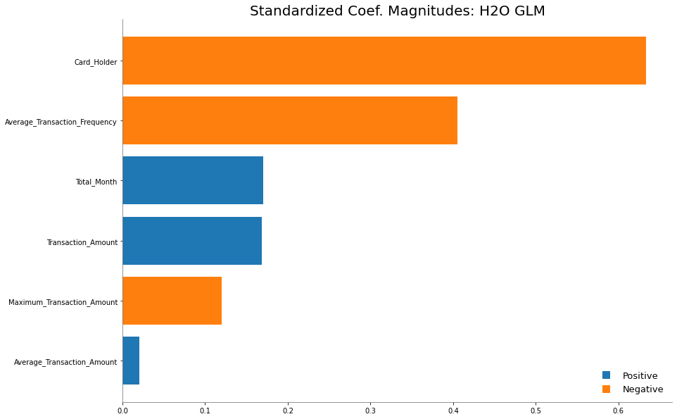

```python
GLM.std_coef_plot(num_of_features=10)
```

```python
varimp_base_model = variable_importances(GLM, limit=0.99)
varimp_base_model
```

|  | variable | relative_importance | scaled_importance | percentage | cumulative |
| --- | --- | --- | --- | --- | --- |
| 0 | Card_Holder | 0.633280 | 1.000000 | 0.417166 | 0.417166 |
| 1 | Average_Transaction_Frequency | 0.405231 | 0.639893 | 0.266942 | 0.684108 |
| 2 | Total_Month | 0.170398 | 0.269073 | 0.112248 | 0.796357 |
| 3 | Transaction_Amount | 0.168822 | 0.266583 | 0.111209 | 0.907566 |
| 4 | Maximum_Transaction_Amount | 0.120142 | 0.189715 | 0.079143 | 0.986709 |

### GLM run 30x

```python
model_glm=[]
for i in range (30):
    GLM = H2OAutoML(max_runtime_secs=300, nfolds=0, include_algos=['GLM'])
    GLM.train(x=glm_vars, y=response, training_frame=trains[i], validation_frame=tests[i])
    model_glm.append(GLM)
```

```
AutoML progress: |████████████████████████████████████████████████████████| 100%
AutoML progress: |████████████████████████████████████████████████████████| 100%
AutoML progress: |████████████████████████████████████████████████████████| 100%
AutoML progress: |████████████████████████████████████████████████████████| 100%
AutoML progress: |████████████████████████████████████████████████████████| 100%
AutoML progress: |████████████████████████████████████████████████████████| 100%
AutoML progress: |████████████████████████████████████████████████████████| 100%
AutoML progress: |████████████████████████████████████████████████████████| 100%
AutoML progress: |████████████████████████████████████████████████████████| 100%
AutoML progress: |████████████████████████████████████████████████████████| 100%
AutoML progress: |████████████████████████████████████████████████████████| 100%
AutoML progress: |████████████████████████████████████████████████████████| 100%
AutoML progress: |████████████████████████████████████████████████████████| 100%
AutoML progress: |████████████████████████████████████████████████████████| 100%
AutoML progress: |████████████████████████████████████████████████████████| 100%
AutoML progress: |████████████████████████████████████████████████████████| 100%
AutoML progress: |████████████████████████████████████████████████████████| 100%
AutoML progress: |████████████████████████████████████████████████████████| 100%
AutoML progress: |████████████████████████████████████████████████████████| 100%
AutoML progress: |████████████████████████████████████████████████████████| 100%
AutoML progress: |████████████████████████████████████████████████████████| 100%
AutoML progress: |████████████████████████████████████████████████████████| 100%
AutoML progress: |████████████████████████████████████████████████████████| 100%
AutoML progress: |████████████████████████████████████████████████████████| 100%
AutoML progress: |████████████████████████████████████████████████████████| 100%
AutoML progress: |████████████████████████████████████████████████████████| 100%
AutoML progress: |████████████████████████████████████████████████████████| 100%
AutoML progress: |████████████████████████████████████████████████████████| 100%
AutoML progress: |████████████████████████████████████████████████████████| 100%
AutoML progress: |████████████████████████████████████████████████████████| 100%
```

```python
f1_total=[]
threshold_total=[]
precision_total=[]
sensitivity_total=[]
accuracy_total=[]
var_glm=[]

for i in range (30):
    f1=model_glm[i].leader.F1(train=False,valid=True,xval=False)[0][1]
    threshold = model_glm[i].leader.F1(train=False,valid=True,xval=False)[0][0]
    precision=model_glm[i].leader.precision(train=False,valid=True,xval=False,thresholds=threshold)[0][1]
    sensitivity=model_glm[i].leader.sensitivity(train=False,valid=True,xval=False,thresholds=threshold)[0][1]
    accuracy=model_glm[i].leader.accuracy(train=False,valid=True,xval=False,thresholds=threshold)[0][1]

    f1_total.append(f1)
    threshold_total.append(threshold)
    precision_total.append(precision)
    sensitivity_total.append(sensitivity)
    accuracy_total.append(accuracy)

    vars = variable_importances(model_glm[i].leader,limit=1)
    var_glm.append(vars)
```

```python
glm=pd.DataFrame({'threshold':threshold_total,'sensitivity':sensitivity_total,'precision':precision_total
                            ,'accuracy':accuracy_total,'F1':f1_total})
glm.describe()
```

|  | threshold | sensitivity | precision | accuracy | F1 |
| --- | --- | --- | --- | --- | --- |
| count | 30.000000 | 30.000000 | 30.000000 | 30.000000 | 30.000000 |
| mean | 0.157515 | 0.413736 | 0.376762 | 0.910451 | 0.391180 |
| std | 0.104847 | 0.041499 | 0.046750 | 0.010520 | 0.026213 |
| min | 0.057716 | 0.346154 | 0.283333 | 0.882286 | 0.322275 |
| 25% | 0.076527 | 0.379121 | 0.345891 | 0.905429 | 0.374499 |
| 50% | 0.097182 | 0.428571 | 0.375836 | 0.912381 | 0.392374 |
| 75% | 0.267523 | 0.439560 | 0.397818 | 0.916190 | 0.405364 |
| max | 0.354130 | 0.494505 | 0.474453 | 0.928000 | 0.441624 |

Rata-rata dan standar deviasi dari metric score dari 30 model GLM

```python
glm_metric=glm.describe().iloc[1:3].T
glm_metric
```

|  | mean | std |
| --- | --- | --- |
| threshold | 0.157515 | 0.104847 |
| sensitivity | 0.413736 | 0.041499 |
| precision | 0.376762 | 0.046750 |
| accuracy | 0.910451 | 0.010520 |
| F1 | 0.391180 | 0.026213 |

```python
varimp_glm = var_glm[0]
for i in range (1,30):
    varimp_glm=varimp_glm.append(var_glm[i])
```

Rata-rata percentage dan cumulative variable importance dari 30 model GLM

```python
varimp_glm = varimp_glm.groupby(['variable'])[['percentage','cumulative']].mean().sort_values(by='percentage', ascending= False)
varimp_glm
```

| variable | percentage | cumulative |
| --- | --- | --- |
| Card_Holder | 0.425651 | 0.425651 |
| Average_Transaction_Frequency | 0.261316 | 0.692607 |
| Transaction_Amount | 0.119972 | 0.852089 |
| Total_Month | 0.092193 | 0.898805 |
| Maximum_Transaction_Amount | 0.071251 | 0.959818 |
| Average_Transaction_Amount | 0.033942 | 0.989467 |

### Random Forest

```python
from h2o.estimators.random_forest import H2ORandomForestEstimator

rf = H2ORandomForestEstimator(ntrees=50, nfolds=10)
rf.train(x=glm_vars, y=response, training_frame=trains[1], validation_frame=tests[1])
rf
```

```
drf Model Build progress: |███████████████████████████████████████████████| 100%
Model Details
=============
H2ORandomForestEstimator :  Distributed Random Forest
Model Key:  DRF_model_python_1626646332913_21598


Model Summary:
```

|  |  | number_of_trees | number_of_internal_trees | model_size_in_bytes | min_depth | max_depth | mean_depth | min_leaves | max_leaves | mean_leaves |
| --- | --- | --- | --- | --- | --- | --- | --- | --- | --- | --- |
| 0 |  | 50.0 | 50.0 | 358462.0 | 20.0 | 20.0 | 20.0 | 471.0 | 640.0 | 564.82 |

```
ModelMetricsBinomial: drf
** Reported on train data. **

MSE: 0.0542190456037755
RMSE: 0.23284983488028396
LogLoss: 0.4735242909813091
Mean Per-Class Error: 0.26221963327980524
AUC: 0.7914014625025677
AUCPR: 0.36558808783347674
Gini: 0.5828029250051354

Confusion Matrix (Act/Pred) for max f1 @ threshold = 0.27531014845776464:
```

|  |  | 0 | 1 | Error | Rate |
| --- | --- | --- | --- | --- | --- |
| 0 | 0 | 6968.0 | 361.0 | 0.0493 | (361.0/7329.0) |
| 1 | 1 | 301.0 | 245.0 | 0.5513 | (301.0/546.0) |
| 2 | Total | 7269.0 | 606.0 | 0.0841 | (662.0/7875.0) |

```
Maximum Metrics: Maximum metrics at their respective thresholds
```

|  | metric | threshold | value | idx |
| --- | --- | --- | --- | --- |
| 0 | max f1 | 0.275310 | 0.425347 | 175.0 |
| 1 | max f2 | 0.130426 | 0.469605 | 259.0 |
| 2 | max f0point5 | 0.470789 | 0.497699 | 107.0 |
| 3 | max accuracy | 0.562283 | 0.936889 | 83.0 |
| 4 | max precision | 1.000000 | 1.000000 | 0.0 |
| 5 | max recall | 0.000003 | 1.000000 | 399.0 |
| 6 | max specificity | 1.000000 | 1.000000 | 0.0 |
| 7 | max absolute_mcc | 0.470789 | 0.399103 | 107.0 |
| 8 | max min_per_class_accuracy | 0.058807 | 0.725201 | 324.0 |
| 9 | max mean_per_class_accuracy | 0.111158 | 0.737780 | 274.0 |
| 10 | max tns | 1.000000 | 7329.000000 | 0.0 |
| 11 | max fns | 1.000000 | 545.000000 | 0.0 |
| 12 | max fps | 0.000003 | 7329.000000 | 399.0 |
| 13 | max tps | 0.000003 | 546.000000 | 399.0 |
| 14 | max tnr | 1.000000 | 1.000000 | 0.0 |
| 15 | max fnr | 1.000000 | 0.998168 | 0.0 |
| 16 | max fpr | 0.000003 | 1.000000 | 399.0 |
| 17 | max tpr | 0.000003 | 1.000000 | 399.0 |

```
Gains/Lift Table: Avg response rate:  6.93 %, avg score:  7.31 %
```

|  | group | cumulative_data_fraction | lower_threshold | lift | cumulative_lift | response_rate | score | cumulative_response_rate | cumulative_score | capture_rate | cumulative_capture_rate | gain | cumulative_gain | kolmogorov_smirnov |
| --- | --- | --- | --- | --- | --- | --- | --- | --- | --- | --- | --- | --- | --- | --- |
| 0 | 1 | 0.010540 | 0.750000 | 9.209917 | 9.209917 | 0.638554 | 0.834746 | 0.638554 | 0.834746 | 0.097070 | 0.097070 | 820.991659 | 820.991659 | 0.092976 |
| 1 | 2 | 0.020317 | 0.631579 | 8.429071 | 8.834135 | 0.584416 | 0.685030 | 0.612500 | 0.762695 | 0.082418 | 0.179487 | 742.907093 | 783.413462 | 0.171028 |
| 2 | 3 | 0.030476 | 0.529412 | 7.752404 | 8.473558 | 0.537500 | 0.573581 | 0.587500 | 0.699657 | 0.078755 | 0.258242 | 675.240385 | 747.355769 | 0.244734 |
| 3 | 4 | 0.040000 | 0.450563 | 6.538462 | 8.012821 | 0.453333 | 0.489270 | 0.555556 | 0.649565 | 0.062271 | 0.320513 | 553.846154 | 701.282051 | 0.301411 |
| 4 | 5 | 0.050286 | 0.384615 | 4.095442 | 7.211538 | 0.283951 | 0.412891 | 0.500000 | 0.601154 | 0.042125 | 0.362637 | 309.544160 | 621.153846 | 0.335621 |
| 5 | 6 | 0.100063 | 0.216623 | 2.722724 | 4.978524 | 0.188776 | 0.284737 | 0.345178 | 0.443749 | 0.135531 | 0.498168 | 172.272370 | 397.852401 | 0.427763 |
| 6 | 7 | 0.153143 | 0.142857 | 1.587229 | 3.803100 | 0.110048 | 0.173527 | 0.263682 | 0.350090 | 0.084249 | 0.582418 | 58.722856 | 280.309989 | 0.461255 |
| 7 | 8 | 0.200000 | 0.104053 | 1.211695 | 3.195971 | 0.084011 | 0.120240 | 0.221587 | 0.296239 | 0.056777 | 0.639194 | 21.169481 | 219.597070 | 0.471913 |
| 8 | 9 | 0.305016 | 0.058824 | 0.837131 | 2.383831 | 0.058041 | 0.076091 | 0.165279 | 0.220443 | 0.087912 | 0.727106 | -16.286857 | 138.383078 | 0.453535 |
| 9 | 10 | 0.400635 | 0.029412 | 0.478854 | 1.929172 | 0.033201 | 0.048406 | 0.133756 | 0.179383 | 0.045788 | 0.772894 | -52.114618 | 92.917225 | 0.399992 |
| 10 | 11 | 0.500063 | 0.003373 | 0.589449 | 1.662793 | 0.040868 | 0.010690 | 0.115287 | 0.145842 | 0.058608 | 0.831502 | -41.055113 | 66.279251 | 0.356130 |
| 11 | 12 | 0.600000 | 0.000793 | 0.329880 | 1.440781 | 0.022872 | 0.001805 | 0.099894 | 0.121851 | 0.032967 | 0.864469 | -67.012022 | 44.078144 | 0.284171 |
| 12 | 13 | 1.000000 | 0.000000 | 0.338828 | 1.000000 | 0.023492 | 0.000029 | 0.069333 | 0.073122 | 0.135531 | 1.000000 | -66.117216 | 0.000000 | 0.000000 |

```
ModelMetricsBinomial: drf
** Reported on validation data. **

MSE: 0.053940630603848384
RMSE: 0.23225122304058676
LogLoss: 0.33382021054636996
Mean Per-Class Error: 0.25427437891621274
AUC: 0.7822192134513052
AUCPR: 0.36558724467197756
Gini: 0.5644384269026104

Confusion Matrix (Act/Pred) for max f1 @ threshold = 0.32399999976158145:
```

|  |  | 0 | 1 | Error | Rate |
| --- | --- | --- | --- | --- | --- |
| 0 | 0 | 2352.0 | 91.0 | 0.0372 | (91.0/2443.0) |
| 1 | 1 | 105.0 | 77.0 | 0.5769 | (105.0/182.0) |
| 2 | Total | 2457.0 | 168.0 | 0.0747 | (196.0/2625.0) |

```
Maximum Metrics: Maximum metrics at their respective thresholds
```

|  | metric | threshold | value | idx |
| --- | --- | --- | --- | --- |
| 0 | max f1 | 0.324000 | 0.440000 | 94.0 |
| 1 | max f2 | 0.100901 | 0.476384 | 221.0 |
| 2 | max f0point5 | 0.372629 | 0.467480 | 76.0 |
| 3 | max accuracy | 0.684000 | 0.935238 | 19.0 |
| 4 | max precision | 0.940000 | 1.000000 | 0.0 |
| 5 | max recall | 0.000002 | 1.000000 | 399.0 |
| 6 | max specificity | 0.940000 | 1.000000 | 0.0 |
| 7 | max absolute_mcc | 0.360000 | 0.402751 | 82.0 |
| 8 | max min_per_class_accuracy | 0.054064 | 0.719780 | 284.0 |
| 9 | max mean_per_class_accuracy | 0.089968 | 0.745726 | 236.0 |
| 10 | max tns | 0.940000 | 2443.000000 | 0.0 |
| 11 | max fns | 0.940000 | 180.000000 | 0.0 |
| 12 | max fps | 0.000002 | 2443.000000 | 399.0 |
| 13 | max tps | 0.000002 | 182.000000 | 399.0 |
| 14 | max tnr | 0.940000 | 1.000000 | 0.0 |
| 15 | max fnr | 0.940000 | 0.989011 | 0.0 |
| 16 | max fpr | 0.000002 | 1.000000 | 399.0 |
| 17 | max tpr | 0.000002 | 1.000000 | 399.0 |

```
Gains/Lift Table: Avg response rate:  6.93 %, avg score:  7.25 %
```

|  | group | cumulative_data_fraction | lower_threshold | lift | cumulative_lift | response_rate | score | cumulative_response_rate | cumulative_score | capture_rate | cumulative_capture_rate | gain | cumulative_gain | kolmogorov_smirnov |
| --- | --- | --- | --- | --- | --- | --- | --- | --- | --- | --- | --- | --- | --- | --- |
| 0 | 1 | 0.010286 | 0.699114 | 9.615385 | 9.615385 | 0.666667 | 0.788872 | 0.666667 | 0.788872 | 0.098901 | 0.098901 | 861.538462 | 861.538462 | 0.095217 |
| 1 | 2 | 0.021714 | 0.580000 | 7.211538 | 8.350202 | 0.500000 | 0.630810 | 0.578947 | 0.705682 | 0.082418 | 0.181319 | 621.153846 | 735.020243 | 0.171495 |
| 2 | 3 | 0.030095 | 0.505600 | 5.900350 | 7.667965 | 0.409091 | 0.549247 | 0.531646 | 0.662118 | 0.049451 | 0.230769 | 490.034965 | 666.796495 | 0.215624 |
| 3 | 4 | 0.040381 | 0.420000 | 6.410256 | 7.347605 | 0.444444 | 0.451238 | 0.509434 | 0.608403 | 0.065934 | 0.296703 | 541.025641 | 634.760522 | 0.275418 |
| 4 | 5 | 0.051048 | 0.380000 | 6.181319 | 7.103904 | 0.428571 | 0.394699 | 0.492537 | 0.563748 | 0.065934 | 0.362637 | 518.131868 | 610.390356 | 0.334803 |
| 5 | 6 | 0.100190 | 0.213877 | 2.795170 | 4.990494 | 0.193798 | 0.283625 | 0.346008 | 0.426349 | 0.137363 | 0.500000 | 179.516995 | 399.049430 | 0.429595 |
| 6 | 7 | 0.150095 | 0.132640 | 1.211098 | 3.733893 | 0.083969 | 0.167019 | 0.258883 | 0.340125 | 0.060440 | 0.560440 | 21.109806 | 273.389301 | 0.440914 |
| 7 | 8 | 0.200000 | 0.096678 | 1.871697 | 3.269231 | 0.129771 | 0.111258 | 0.226667 | 0.283017 | 0.093407 | 0.653846 | 87.169701 | 226.923077 | 0.487657 |
| 8 | 9 | 0.300190 | 0.052552 | 0.658087 | 2.397745 | 0.045627 | 0.071880 | 0.166244 | 0.212549 | 0.065934 | 0.719780 | -34.191284 | 139.774502 | 0.450849 |
| 9 | 10 | 0.400000 | 0.030926 | 0.440399 | 1.909341 | 0.030534 | 0.041979 | 0.132381 | 0.169988 | 0.043956 | 0.763736 | -55.960070 | 90.934066 | 0.390834 |
| 10 | 11 | 0.500190 | 0.020534 | 0.493565 | 1.625754 | 0.034221 | 0.023964 | 0.112719 | 0.140738 | 0.049451 | 0.813187 | -50.643463 | 62.575429 | 0.336314 |
| 11 | 12 | 0.600000 | 0.007505 | 0.330299 | 1.410256 | 0.022901 | 0.016636 | 0.097778 | 0.120094 | 0.032967 | 0.846154 | -66.970053 | 41.025641 | 0.264492 |
| 12 | 13 | 0.699810 | 0.001434 | 0.220200 | 1.240526 | 0.015267 | 0.003540 | 0.086010 | 0.103471 | 0.021978 | 0.868132 | -77.980035 | 24.052594 | 0.180862 |
| 13 | 14 | 0.800381 | 0.000418 | 0.710227 | 1.173892 | 0.049242 | 0.000861 | 0.081390 | 0.090577 | 0.071429 | 0.939560 | -28.977273 | 17.389155 | 0.149548 |
| 14 | 15 | 1.000000 | 0.000000 | 0.302775 | 1.000000 | 0.020992 | 0.000039 | 0.069333 | 0.072504 | 0.060440 | 1.000000 | -69.722548 | 0.000000 | 0.000000 |

```
ModelMetricsBinomial: drf
** Reported on cross-validation data. **

MSE: 0.05248617622708515
RMSE: 0.22909861681617624
LogLoss: 0.31234566509232303
Mean Per-Class Error: 0.2540198578880528
AUC: 0.8070388246401345
AUCPR: 0.37779581032781784
Gini: 0.6140776492802691

Confusion Matrix (Act/Pred) for max f1 @ threshold = 0.25325035274028773:
```

|  |  | 0 | 1 | Error | Rate |
| --- | --- | --- | --- | --- | --- |
| 0 | 0 | 6943.0 | 386.0 | 0.0527 | (386.0/7329.0) |
| 1 | 1 | 280.0 | 266.0 | 0.5128 | (280.0/546.0) |
| 2 | Total | 7223.0 | 652.0 | 0.0846 | (666.0/7875.0) |

```
Maximum Metrics: Maximum metrics at their respective thresholds
```

|  | metric | threshold | value | idx |
| --- | --- | --- | --- | --- |
| 0 | max f1 | 0.253250 | 0.444073 | 161.0 |
| 1 | max f2 | 0.197125 | 0.489022 | 188.0 |
| 2 | max f0point5 | 0.518333 | 0.492476 | 75.0 |
| 3 | max accuracy | 0.546667 | 0.938286 | 68.0 |
| 4 | max precision | 0.837778 | 0.740741 | 10.0 |
| 5 | max recall | 0.000001 | 1.000000 | 399.0 |
| 6 | max specificity | 0.940000 | 0.999864 | 0.0 |
| 7 | max absolute_mcc | 0.253250 | 0.400533 | 161.0 |
| 8 | max min_per_class_accuracy | 0.060008 | 0.724383 | 300.0 |
| 9 | max mean_per_class_accuracy | 0.100019 | 0.745980 | 259.0 |
| 10 | max tns | 0.940000 | 7328.000000 | 0.0 |
| 11 | max fns | 0.940000 | 546.000000 | 0.0 |
| 12 | max fps | 0.000001 | 7329.000000 | 399.0 |
| 13 | max tps | 0.000001 | 546.000000 | 399.0 |
| 14 | max tnr | 0.940000 | 0.999864 | 0.0 |
| 15 | max fnr | 0.940000 | 1.000000 | 0.0 |
| 16 | max fpr | 0.000001 | 1.000000 | 399.0 |
| 17 | max tpr | 0.000001 | 1.000000 | 399.0 |

```
Gains/Lift Table: Avg response rate:  6.93 %, avg score:  7.34 %
```

|  | group | cumulative_data_fraction | lower_threshold | lift | cumulative_lift | response_rate | score | cumulative_response_rate | cumulative_score | capture_rate | cumulative_capture_rate | gain | cumulative_gain | kolmogorov_smirnov |
| --- | --- | --- | --- | --- | --- | --- | --- | --- | --- | --- | --- | --- | --- | --- |
| 0 | 1 | 0.010413 | 0.720000 | 9.498124 | 9.498124 | 0.658537 | 0.801540 | 0.658537 | 0.801540 | 0.098901 | 0.098901 | 849.812383 | 849.812383 | 0.095081 |
| 1 | 2 | 0.020063 | 0.598400 | 9.488866 | 9.493671 | 0.657895 | 0.650294 | 0.658228 | 0.728789 | 0.091575 | 0.190476 | 848.886640 | 849.367089 | 0.183108 |
| 2 | 3 | 0.030095 | 0.506068 | 7.850536 | 8.945959 | 0.544304 | 0.548631 | 0.620253 | 0.668736 | 0.078755 | 0.269231 | 685.053554 | 794.595910 | 0.256951 |
| 3 | 4 | 0.040000 | 0.431451 | 4.807692 | 7.921245 | 0.333333 | 0.468376 | 0.549206 | 0.619123 | 0.047619 | 0.316850 | 380.769231 | 692.124542 | 0.297475 |
| 4 | 5 | 0.050794 | 0.380000 | 4.751131 | 7.247596 | 0.329412 | 0.403809 | 0.502500 | 0.573369 | 0.051282 | 0.368132 | 375.113122 | 624.759615 | 0.340979 |
| 5 | 6 | 0.100190 | 0.201290 | 3.188649 | 5.246417 | 0.221080 | 0.277238 | 0.363752 | 0.427368 | 0.157509 | 0.525641 | 218.864940 | 424.641708 | 0.457146 |
| 6 | 7 | 0.150095 | 0.137995 | 1.100998 | 3.868118 | 0.076336 | 0.163712 | 0.268190 | 0.339706 | 0.054945 | 0.580586 | 10.099824 | 286.811792 | 0.462562 |
| 7 | 8 | 0.206857 | 0.100000 | 1.484254 | 3.213982 | 0.102908 | 0.112522 | 0.222836 | 0.277366 | 0.084249 | 0.664835 | 48.425400 | 221.398215 | 0.492097 |
| 8 | 9 | 0.307302 | 0.060000 | 0.692891 | 2.389940 | 0.048040 | 0.073280 | 0.165702 | 0.210659 | 0.069597 | 0.734432 | -30.710882 | 138.993961 | 0.458951 |
| 9 | 10 | 0.400000 | 0.037941 | 0.652002 | 1.987179 | 0.045205 | 0.043674 | 0.137778 | 0.171961 | 0.060440 | 0.794872 | -34.799789 | 98.717949 | 0.424289 |
| 10 | 11 | 0.565206 | 0.020000 | 0.454532 | 1.539196 | 0.031514 | 0.022869 | 0.106718 | 0.128382 | 0.075092 | 0.869963 | -54.546798 | 53.919603 | 0.327461 |
| 11 | 12 | 0.600000 | 0.007920 | 0.315834 | 1.468254 | 0.021898 | 0.011711 | 0.101799 | 0.121616 | 0.010989 | 0.880952 | -68.416620 | 46.825397 | 0.301883 |
| 12 | 13 | 0.700063 | 0.001311 | 0.402675 | 1.315946 | 0.027919 | 0.003501 | 0.091239 | 0.104733 | 0.040293 | 0.921245 | -59.732526 | 31.594553 | 0.237660 |
| 13 | 14 | 1.000000 | 0.000000 | 0.262571 | 1.000000 | 0.018205 | 0.000170 | 0.069333 | 0.073371 | 0.078755 | 1.000000 | -73.742917 | 0.000000 | 0.000000 |

```
Cross-Validation Metrics Summary:
```

|  |  | mean | sd | cv_1_valid | cv_2_valid | cv_3_valid | cv_4_valid | cv_5_valid | cv_6_valid | cv_7_valid | cv_8_valid | cv_9_valid | cv_10_valid |
| --- | --- | --- | --- | --- | --- | --- | --- | --- | --- | --- | --- | --- | --- |
| 0 | accuracy | 0.92203707 | 0.013890921 | 0.9363296 | 0.9230769 | 0.92010653 | 0.914787 | 0.91687346 | 0.9262899 | 0.92242426 | 0.9057325 | 0.95090437 | 0.90384614 |
| 1 | auc | 0.80869484 | 0.03808459 | 0.8709154 | 0.76693827 | 0.81709975 | 0.75283444 | 0.8340594 | 0.8349185 | 0.7611833 | 0.8076615 | 0.8343011 | 0.8070368 |
| 2 | aucpr | 0.3893254 | 0.073851526 | 0.34177426 | 0.4075784 | 0.32484445 | 0.30405024 | 0.46308362 | 0.46298954 | 0.34125978 | 0.31030026 | 0.50770015 | 0.42967352 |
| 3 | err | 0.077962935 | 0.013890921 | 0.06367041 | 0.07692308 | 0.07989348 | 0.085213035 | 0.08312655 | 0.07371008 | 0.07757576 | 0.09426752 | 0.04909561 | 0.09615385 |
| 4 | err_count | 61.4 | 11.077505 | 51.0 | 57.0 | 60.0 | 68.0 | 67.0 | 60.0 | 64.0 | 74.0 | 38.0 | 75.0 |
| 5 | f0point5 | 0.46011376 | 0.08982419 | 0.46025103 | 0.5116279 | 0.44964027 | 0.31879196 | 0.4787234 | 0.53097343 | 0.4379562 | 0.35820895 | 0.63829786 | 0.41666666 |
| 6 | f1 | 0.46235162 | 0.06382355 | 0.4631579 | 0.43564355 | 0.45454547 | 0.35849056 | 0.5179856 | 0.54545456 | 0.42857143 | 0.39344263 | 0.55813956 | 0.4680851 |
| 7 | f2 | 0.47252572 | 0.06455341 | 0.4661017 | 0.37931034 | 0.4595588 | 0.40948275 | 0.56426334 | 0.5607477 | 0.41958043 | 0.43636364 | 0.49586776 | 0.5339806 |
| 8 | lift_top_group | 9.530581 | 2.8119936 | 7.574468 | 10.291667 | 3.476852 | 11.875 | 11.940741 | 8.613756 | 11.063218 | 7.6960783 | 13.024038 | 9.75 |
| 9 | logloss | 0.31237337 | 0.06685214 | 0.16513433 | 0.39569703 | 0.25671464 | 0.3439685 | 0.30859753 | 0.34875256 | 0.38070232 | 0.27778968 | 0.32902113 | 0.3173559 |
| 10 | max_per_class_error | 0.51607305 | 0.08004382 | 0.5319149 | 0.6507937 | 0.537037 | 0.54761904 | 0.4 | 0.42857143 | 0.5862069 | 0.5294118 | 0.53846157 | 0.4107143 |
| 11 | mcc | 0.4272676 | 0.068480864 | 0.42934668 | 0.41172773 | 0.41153657 | 0.32298487 | 0.4787969 | 0.506057 | 0.38730022 | 0.34936124 | 0.546878 | 0.428687 |
| 12 | mean_per_class_accuracy | 0.7193393 | 0.035500634 | 0.71680117 | 0.66280377 | 0.7092433 | 0.6964286 | 0.7711796 | 0.7637436 | 0.68733984 | 0.70327777 | 0.72384405 | 0.75873125 |
| 13 | mean_per_class_error | 0.28066072 | 0.035500634 | 0.28319883 | 0.33719623 | 0.29075667 | 0.30357143 | 0.22882037 | 0.23625642 | 0.31266016 | 0.29672223 | 0.27615598 | 0.24126874 |
| 14 | mse | 0.052567787 | 0.005899897 | 0.045305997 | 0.064192586 | 0.057029303 | 0.047768053 | 0.05145914 | 0.05231704 | 0.056172285 | 0.05361295 | 0.044419426 | 0.05340108 |
| 15 | pr_auc | 0.3893254 | 0.073851526 | 0.34177426 | 0.4075784 | 0.32484445 | 0.30405024 | 0.46308362 | 0.46298954 | 0.34125978 | 0.31030026 | 0.50770015 | 0.42967352 |
| 16 | precision | 0.46346098 | 0.11803158 | 0.45833334 | 0.57894737 | 0.44642857 | 0.296875 | 0.4556962 | 0.5217391 | 0.44444445 | 0.33802816 | 0.7058824 | 0.3882353 |
| 17 | r2 | 0.18103261 | 0.075585894 | 0.17974 | 0.17481554 | 0.14542262 | 0.041985203 | 0.25313425 | 0.26732486 | 0.14057764 | 0.11744294 | 0.29121533 | 0.1986677 |
| 18 | recall | 0.48392695 | 0.08004382 | 0.4680851 | 0.34920636 | 0.46296296 | 0.45238096 | 0.6 | 0.5714286 | 0.41379312 | 0.47058824 | 0.46153846 | 0.58928573 |
| 19 | rmse | 0.22895545 | 0.012788296 | 0.21285206 | 0.25336257 | 0.23880808 | 0.21855903 | 0.22684607 | 0.22872917 | 0.23700693 | 0.2315447 | 0.21075916 | 0.23108673 |

```
See the whole table with table.as_data_frame()

Scoring History:
```

|  |  | timestamp | duration | number_of_trees | training_rmse | training_logloss | training_auc | training_pr_auc | training_lift | training_classification_error | validation_rmse | validation_logloss | validation_auc | validation_pr_auc | validation_lift | validation_classification_error |
| --- | --- | --- | --- | --- | --- | --- | --- | --- | --- | --- | --- | --- | --- | --- | --- | --- |
| 0 |  | 2021-07-19 06:00:32 | 41.078 sec | 0.0 | NaN | NaN | NaN | NaN | NaN | NaN | NaN | NaN | NaN | NaN | NaN | NaN |
| 1 |  | 2021-07-19 06:00:32 | 41.125 sec | 1.0 | 0.292897 | 2.699119 | 0.605872 | 0.170013 | 5.136986 | 0.090816 | 0.301466 | 2.909076 | 0.607535 | 0.164245 | 4.807692 | 0.090286 |
| 2 |  | 2021-07-19 06:00:32 | 41.203 sec | 2.0 | 0.297280 | 2.753688 | 0.621989 | 0.166696 | 4.631801 | 0.100543 | 0.272970 | 1.678546 | 0.656339 | 0.210771 | 7.347605 | 0.124190 |
| 3 |  | 2021-07-19 06:00:32 | 41.250 sec | 3.0 | 0.287035 | 2.387369 | 0.644639 | 0.184616 | 5.053755 | 0.106866 | 0.260650 | 1.266126 | 0.696860 | 0.248870 | 8.547009 | 0.078476 |
| 4 |  | 2021-07-19 06:00:32 | 41.296 sec | 4.0 | 0.283182 | 2.208800 | 0.657978 | 0.197479 | 5.331488 | 0.102849 | 0.254181 | 1.127383 | 0.707708 | 0.273616 | 6.810897 | 0.088381 |
| 5 |  | 2021-07-19 06:00:33 | 41.422 sec | 5.0 | 0.278906 | 2.041049 | 0.659146 | 0.207470 | 5.705128 | 0.102242 | 0.250315 | 1.053142 | 0.715074 | 0.284070 | 7.978723 | 0.089524 |
| 6 |  | 2021-07-19 06:00:33 | 41.484 sec | 6.0 | 0.275516 | 1.923944 | 0.660827 | 0.213054 | 5.826070 | 0.099648 | 0.248256 | 0.970769 | 0.720961 | 0.295339 | 8.653846 | 0.077714 |
| 7 |  | 2021-07-19 06:00:33 | 41.750 sec | 7.0 | 0.270012 | 1.777759 | 0.673152 | 0.220306 | 5.719496 | 0.094804 | 0.245902 | 0.933625 | 0.721514 | 0.305587 | 9.449602 | 0.083048 |
| 8 |  | 2021-07-19 06:00:33 | 41.797 sec | 8.0 | 0.266455 | 1.640021 | 0.679211 | 0.230421 | 6.083203 | 0.089688 | 0.243421 | 0.846857 | 0.735193 | 0.315003 | 7.978723 | 0.082667 |
| 9 |  | 2021-07-19 06:00:33 | 41.844 sec | 9.0 | 0.262135 | 1.499741 | 0.685961 | 0.245750 | 6.738651 | 0.087445 | 0.242264 | 0.822629 | 0.734317 | 0.311792 | 8.173077 | 0.071619 |
| 10 |  | 2021-07-19 06:00:33 | 41.906 sec | 10.0 | 0.259785 | 1.421381 | 0.699104 | 0.254863 | 6.772575 | 0.083515 | 0.240633 | 0.797262 | 0.737423 | 0.325840 | 8.012821 | 0.075810 |
| 11 |  | 2021-07-19 06:00:34 | 42.517 sec | 11.0 | 0.257502 | 1.333265 | 0.705288 | 0.261962 | 6.751227 | 0.088671 | 0.240208 | 0.761525 | 0.743523 | 0.326294 | 8.350202 | 0.080381 |
| 12 |  | 2021-07-19 06:00:34 | 42.580 sec | 12.0 | 0.254825 | 1.268781 | 0.709169 | 0.271662 | 7.211538 | 0.079913 | 0.238806 | 0.700057 | 0.755793 | 0.331068 | 8.952255 | 0.075048 |
| 13 |  | 2021-07-19 06:00:34 | 42.642 sec | 13.0 | 0.251977 | 1.190905 | 0.716865 | 0.285526 | 7.915103 | 0.084595 | 0.237615 | 0.675880 | 0.758839 | 0.337530 | 9.014423 | 0.070095 |
| 14 |  | 2021-07-19 06:00:34 | 42.703 sec | 14.0 | 0.250274 | 1.124468 | 0.724985 | 0.289342 | 8.385510 | 0.085409 | 0.237342 | 0.641220 | 0.764396 | 0.338173 | 8.413462 | 0.072000 |
| 15 |  | 2021-07-19 06:00:34 | 42.781 sec | 15.0 | 0.248572 | 1.090752 | 0.727621 | 0.295750 | 8.266886 | 0.084614 | 0.236782 | 0.641050 | 0.761095 | 0.340260 | 8.839950 | 0.075048 |
| 16 |  | 2021-07-19 06:00:34 | 42.850 sec | 16.0 | 0.247259 | 1.049133 | 0.732877 | 0.299459 | 8.012821 | 0.083958 | 0.236172 | 0.615802 | 0.762898 | 0.343329 | 8.012821 | 0.073524 |
| 17 |  | 2021-07-19 06:00:34 | 42.954 sec | 17.0 | 0.245851 | 0.999119 | 0.738306 | 0.303365 | 7.607777 | 0.082931 | 0.236003 | 0.615821 | 0.762038 | 0.346749 | 8.186071 | 0.076571 |
| 18 |  | 2021-07-19 06:00:34 | 43.032 sec | 18.0 | 0.244618 | 0.962384 | 0.739575 | 0.308663 | 8.070055 | 0.079883 | 0.235972 | 0.616187 | 0.759726 | 0.343902 | 8.454907 | 0.071619 |
| 19 |  | 2021-07-19 06:00:34 | 43.157 sec | 19.0 | 0.243723 | 0.921439 | 0.744220 | 0.311242 | 8.786472 | 0.080381 | 0.235402 | 0.602792 | 0.762818 | 0.351260 | 9.271978 | 0.068190 |

```
See the whole table with table.as_data_frame()

Variable Importances:
```

|  | variable | relative_importance | scaled_importance | percentage |
| --- | --- | --- | --- | --- |
| 0 | Total_Month | 2697.877930 | 1.000000 | 0.173327 |
| 1 | Average_Transaction_Frequency | 2668.019775 | 0.988933 | 0.171409 |
| 2 | Transaction_Amount | 2656.290283 | 0.984585 | 0.170655 |
| 3 | Average_Transaction_Amount | 2654.055908 | 0.983757 | 0.170512 |
| 4 | Maximum_Transaction_Amount | 2612.028564 | 0.968179 | 0.167812 |
| 5 | Card_Holder | 2276.965820 | 0.843984 | 0.146285 |

```python
def model_performance(model, threshold, train=False, valid=True, xval=False, header='Value', style=False):
    f1 = model.F1(train=train, valid=valid, xval=xval, thresholds=threshold)[0][1]
    precision = model.precision(train=train, valid=valid, xval=xval, thresholds=threshold)[0][1]
    sensitivity = model.recall(train=train, valid=valid, xval=xval, thresholds=threshold)[0][1]
    accuracy = model.accuracy(train=train, valid=valid, xval=xval, thresholds=threshold)[0][1]

    metrics = {'Threshold': threshold, 'F1': f1, 'Precision': precision, 'Sensitivity': sensitivity, 'Accuracy': accuracy}
    performance = pd.DataFrame(metrics.values(), columns=[header], index=metrics.keys())

    if style:
        performance = performance.style.format('{:.2%}')

    return performance
```

```python
rf_max_threshold = rf.F1(valid=True)[0][0]
rf_model_performance = model_performance(model=rf, threshold=rf_max_threshold, header='Random_Forest')
model_performance(model=rf, threshold=rf_max_threshold, style=True)
```

|  | Value |
| --- | --- |
| Threshold | 32.40% |
| F1 | 44.00% |
| Precision | 45.83% |
| Sensitivity | 42.31% |
| Accuracy | 92.53% |

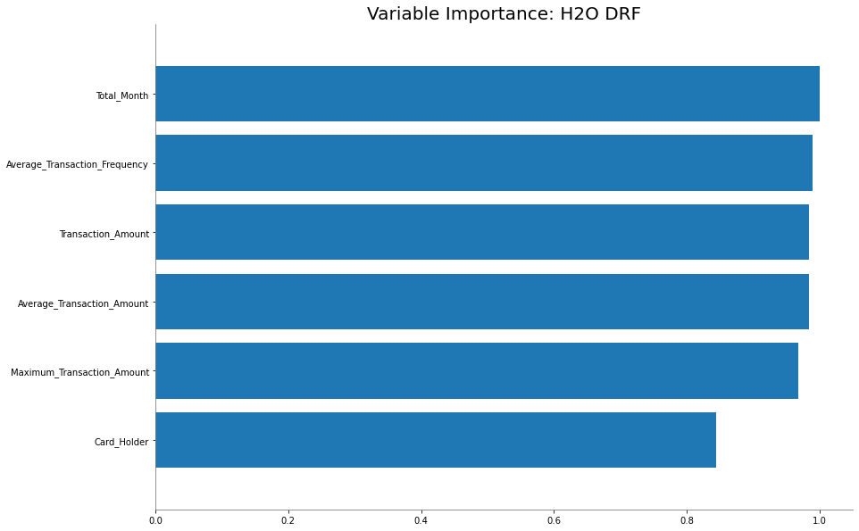

```python
rf.varimp_plot()
```

```python
varimp_base_model = variable_importances(rf, limit=0.99)
varimp_base_model
```

|  | variable | relative_importance | scaled_importance | percentage | cumulative |
| --- | --- | --- | --- | --- | --- |
| 0 | Total_Month | 2697.877930 | 1.000000 | 0.173327 | 0.173327 |
| 1 | Average_Transaction_Frequency | 2668.019775 | 0.988933 | 0.171409 | 0.344736 |
| 2 | Transaction_Amount | 2656.290283 | 0.984585 | 0.170655 | 0.515391 |
| 3 | Average_Transaction_Amount | 2654.055908 | 0.983757 | 0.170512 | 0.685903 |
| 4 | Maximum_Transaction_Amount | 2612.028564 | 0.968179 | 0.167812 | 0.853715 |

### Random Forest Run 30x

```python
from h2o.estimators.random_forest import H2ORandomForestEstimator
model_rf=[]
for i in range (30):
    rf = H2ORandomForestEstimator(ntrees=50, nfolds=0)
    rf.train(x=glm_vars, y=response, training_frame=trains[i], validation_frame=tests[i])
    model_rf.append(rf)
```

```
drf Model Build progress: |███████████████████████████████████████████████| 100%
drf Model Build progress: |███████████████████████████████████████████████| 100%
drf Model Build progress: |███████████████████████████████████████████████| 100%
drf Model Build progress: |███████████████████████████████████████████████| 100%
drf Model Build progress: |███████████████████████████████████████████████| 100%
drf Model Build progress: |███████████████████████████████████████████████| 100%
drf Model Build progress: |███████████████████████████████████████████████| 100%
drf Model Build progress: |███████████████████████████████████████████████| 100%
drf Model Build progress: |███████████████████████████████████████████████| 100%
drf Model Build progress: |███████████████████████████████████████████████| 100%
drf Model Build progress: |███████████████████████████████████████████████| 100%
drf Model Build progress: |███████████████████████████████████████████████| 100%
drf Model Build progress: |███████████████████████████████████████████████| 100%
drf Model Build progress: |███████████████████████████████████████████████| 100%
drf Model Build progress: |███████████████████████████████████████████████| 100%
drf Model Build progress: |███████████████████████████████████████████████| 100%
drf Model Build progress: |███████████████████████████████████████████████| 100%
drf Model Build progress: |███████████████████████████████████████████████| 100%
drf Model Build progress: |███████████████████████████████████████████████| 100%
drf Model Build progress: |███████████████████████████████████████████████| 100%
drf Model Build progress: |███████████████████████████████████████████████| 100%
drf Model Build progress: |███████████████████████████████████████████████| 100%
drf Model Build progress: |███████████████████████████████████████████████| 100%
drf Model Build progress: |███████████████████████████████████████████████| 100%
drf Model Build progress: |███████████████████████████████████████████████| 100%
drf Model Build progress: |███████████████████████████████████████████████| 100%
drf Model Build progress: |███████████████████████████████████████████████| 100%
drf Model Build progress: |███████████████████████████████████████████████| 100%
drf Model Build progress: |███████████████████████████████████████████████| 100%
drf Model Build progress: |███████████████████████████████████████████████| 100%
```

```python
f1_total=[]
threshold_total=[]
precision_total=[]
sensitivity_total=[]
accuracy_total=[]
var_rf=[]

for i in range (30):
    f1=model_rf[i].F1(valid=True)[0][1]
    threshold = model_rf[i].F1(valid=True)[0][0]
    precision=model_rf[i].precision(train=False,valid=True,xval=False,thresholds=threshold)[0][1]
    sensitivity=model_rf[i].sensitivity(train=False,valid=True,xval=False,thresholds=threshold)[0][1]
    accuracy=model_rf[i].accuracy(train=False,valid=True,xval=False,thresholds=threshold)[0][1]

    f1_total.append(f1)
    threshold_total.append(threshold)
    precision_total.append(precision)
    sensitivity_total.append(sensitivity)
    accuracy_total.append(accuracy)

    vars = variable_importances(model_rf[i],limit=1)
    var_rf.append(vars)
```

```python
random_forest=pd.DataFrame({'threshold':threshold_total,'sensitivity':sensitivity_total,'precision':precision_total
                            ,'accuracy':accuracy_total,'F1':f1_total})
random_forest.describe()
```

|  | threshold | sensitivity | precision | accuracy | F1 |
| --- | --- | --- | --- | --- | --- |
| count | 30.000000 | 30.000000 | 30.000000 | 30.000000 | 30.000000 |
| mean | 0.292513 | 0.454945 | 0.455685 | 0.923276 | 0.451675 |
| std | 0.053585 | 0.047647 | 0.051918 | 0.009205 | 0.028896 |
| min | 0.170028 | 0.368132 | 0.334728 | 0.897143 | 0.380048 |
| 25% | 0.261000 | 0.423077 | 0.424109 | 0.919143 | 0.433040 |
| 50% | 0.285762 | 0.456044 | 0.460738 | 0.925524 | 0.451849 |
| 75% | 0.336658 | 0.483516 | 0.486943 | 0.928762 | 0.476204 |
| max | 0.400000 | 0.554945 | 0.580153 | 0.938667 | 0.501333 |

Rata-rata dan standar deviasi dari metric score dari 30 model Random Forest

```python
rf_metric=random_forest.describe().iloc[1:3].T
rf_metric
```

|  | mean | std |
| --- | --- | --- |
| threshold | 0.292513 | 0.053585 |
| sensitivity | 0.454945 | 0.047647 |
| precision | 0.455685 | 0.051918 |
| accuracy | 0.923276 | 0.009205 |
| F1 | 0.451675 | 0.028896 |

```python
rf_varimp = var_rf[0]
for i in range (1,30):
    rf_varimp=rf_varimp.append(var_rf[i])
```

Rata-rata percentage dan cumulative dari variable importance dari 30 model random forest

```python
rf_varimp = rf_varimp.groupby(['variable'])[['percentage','cumulative']].mean().sort_values(by='percentage', ascending= False)
rf_varimp
```

| variable | percentage | cumulative |
| --- | --- | --- |
| Average_Transaction_Frequency | 0.175667 | 0.298411 |
| Transaction_Amount | 0.174768 | 0.310145 |
| Average_Transaction_Amount | 0.170596 | 0.531666 |
| Maximum_Transaction_Amount | 0.166336 | 0.697832 |
| Total_Month | 0.164246 | 0.764064 |
| Card_Holder | 0.148387 | 0.989396 |

## The Best Model

Rata-rata dari metric score ketiga model

```python
performances_mean = [gbm_metric['mean'], glm_metric['mean'], rf_metric['mean']]
model_performances_mean = pd.concat(performances_mean, axis=1)
model_performances_mean.columns=['GBM','GLM','Random Forest']
model_performances_mean
```

|  | GBM | GLM | Random Forest |
| --- | --- | --- | --- |
| threshold | 0.215200 | 0.157515 | 0.292513 |
| sensitivity | 0.457326 | 0.413736 | 0.454945 |
| precision | 0.474628 | 0.376762 | 0.455685 |
| accuracy | 0.926083 | 0.910451 | 0.923276 |
| F1 | 0.462564 | 0.391180 | 0.451675 |

Standar deviasi metric score dari ketiga model

```python
performances_std = [gbm_metric['std'], glm_metric['std'], rf_metric['std']]
model_performances_std = pd.concat(performances_std, axis=1)
model_performances_std.columns=['GBM','GLM','Random Forest']
model_performances_std
```

|  | GBM | GLM | Random Forest |
| --- | --- | --- | --- |
| threshold | 0.042023 | 0.104847 | 0.053585 |
| sensitivity | 0.039666 | 0.041499 | 0.047647 |
| precision | 0.057759 | 0.046750 | 0.051918 |
| accuracy | 0.008516 | 0.010520 | 0.009205 |
| F1 | 0.028995 | 0.026213 | 0.028896 |

Dari ketiga model, rata-rata f1 score tertinggi dimiliki model GBM. Namun perbandingan antara model GBM dengan Random Forest memiliki selisih yang kecil, sehingga untuk memastikannya dilakukan AB Testing

### AB Testing GBM and GLM

```python
controls=gbm['F1']
```

```python
targeteds=glm['F1']
```

```python
from scipy.stats import wilcoxon

simulations = 1000
alpha = 0.05
pvals = []

start_time = pd.to_datetime('now') + pd.Timedelta('07:00:00')

for simulation in range(simulations):
    model1 = np.random.choice(controls, len(controls))
    model2 = np.random.choice(targeteds, len(targeteds))

    w, p = wilcoxon(model1,model2)
    pvals.append(p)

power = np.mean(np.array(pvals) < alpha)
print('Power Level:', str(power))
timer(start_time, header='\nSimulation')
```

```
Power Level: 1.0

Simulation
Start   : 2021-07-19 07:28:06 AM
Finish  : 2021-07-19 07:28:07 AM
Runtime : 00:00:00
```

Hasil menunjukkan GBM dan GLM memang berbeda signifikan, dimana f1 score GBM lebih besar

### AB Testing GBM and Random Forest

```python
controls=gbm['F1']
```

```python
targeteds=random_forest['F1']
```

```python
from scipy.stats import wilcoxon

simulations = 1000
alpha = 0.05
pvals = []

start_time = pd.to_datetime('now') + pd.Timedelta('07:00:00')

for simulation in range(simulations):
    model1 = np.random.choice(controls, 100)
    model2 = np.random.choice(targeteds, 100)

    w, p = wilcoxon(model1,model2)
    pvals.append(p)

power = np.mean(np.array(pvals) < alpha)
print('Power Level:', str(power))
timer(start_time, header='\nSimulation')
```

```
Power Level: 0.809

Simulation
Start   : 2021-07-19 07:27:14 AM
Finish  : 2021-07-19 07:27:15 AM
Runtime : 00:00:00
```

Hasil menunjukkan GBM dan Random Forest memang berbeda signifikan, dimana f1 score GBM lebih besar

### AB Testing Random Forest and GLM

```python
controls=glm['F1']
```

```python
targeteds=random_forest['F1']
```

```python
from scipy.stats import wilcoxon

simulations = 1000
alpha = 0.05
pvals = []

start_time = pd.to_datetime('now') + pd.Timedelta('07:00:00')

for simulation in range(simulations):
    model1 = np.random.choice(controls, len(controls))
    model2 = np.random.choice(targeteds, len(targeteds))

    w, p = wilcoxon(model1,model2)
    pvals.append(p)

power = np.mean(np.array(pvals) < alpha)
print('Power Level:', str(power))
timer(start_time, header='\nSimulation')
```

```
Power Level: 1.0

Simulation
Start   : 2021-07-19 07:24:58 AM
Finish  : 2021-07-19 07:25:03 AM
Runtime : 00:00:04
```

Hasil menunjukkan GLM dan Random Forest memang berbeda signifikan, dimana f1 score Random Forest lebih besar

Dari hasil tersebut maka model terbaik adalah model GBM

# Prediction Using Best Model

### Data treatment the same as before

```python
data_test=pd.read_excel('C:/Users/Hp/Desktop/Kuliah/Semester 6/ADS/cctx_test.xlsx')
```

```python
data_test.info()
```

```
<class 'pandas.core.frame.DataFrame'>
RangeIndex: 2625 entries, 0 to 2624
Data columns (total 20 columns):
 #   Column                         Non-Null Count  Dtype
---  ------                         --------------  -----
 0   Transaction_ID                 2625 non-null   object
 1   Transaction_Flag               2625 non-null   bool
 2   Transaction_Date               2625 non-null   datetime64[ns]
 3   Transaction_Type               2625 non-null   object
 4   Transaction_Amount             2625 non-null   int64
 5   Bank_ID                        2625 non-null   int64
 6   CC_ID                          2625 non-null   object
 7   Card_Type                      2625 non-null   object
 8   Card_Holder                    2625 non-null   int64
 9   Channel_ID                     2625 non-null   int64
 10  Merchant_ID                    2625 non-null   object
 11  Country_ID                     2625 non-null   object
 12  City_ID                        2625 non-null   object
 13  EDC_Type                       2625 non-null   object
 14  EDC_Location                   2625 non-null   object
 15  EDC_Owner                      2625 non-null   object
 16  Average_Transaction_Amount     2620 non-null   float64
 17  Maximum_Transaction_Amount     2620 non-null   float64
 18  Minimum_Transaction_Amount     2620 non-null   float64
 19  Average_Transaction_Frequency  2620 non-null   float64
dtypes: bool(1), datetime64[ns](1), float64(4), int64(4), object(10)
memory usage: 392.3+ KB
```

```python
data_test.describe()
```

|  | Transaction_Amount | Bank_ID | Card_Holder | Channel_ID | Average_Transaction_Amount | Maximum_Transaction_Amount | Minimum_Transaction_Amount | Average_Transaction_Frequency |
| --- | --- | --- | --- | --- | --- | --- | --- | --- |
| count | 2.625000e+03 | 2625.0 | 2625.000000 | 2625.000000 | 2.620000e+03 | 2.620000e+03 | 2.620000e+03 | 2620.000000 |
| mean | 1.294459e+06 | 1.0 | 1.932571 | 1.400000 | 1.354954e+06 | 1.227272e+07 | 7.315596e+04 | 2.437034 |
| std | 2.910836e+06 | 0.0 | 0.250811 | 1.012122 | 1.482863e+06 | 1.666874e+07 | 2.006759e+05 | 1.385924 |
| min | 8.000000e+03 | 1.0 | 1.000000 | 1.000000 | 5.000000e+04 | 3.800000e+04 | 1.000000e+00 | 1.000000 |
| 25% | 2.000000e+05 | 1.0 | 2.000000 | 1.000000 | 5.488456e+05 | 2.500000e+06 | 2.480000e+04 | 1.680000 |
| 50% | 5.500000e+05 | 1.0 | 2.000000 | 1.000000 | 1.013092e+06 | 6.000000e+06 | 3.505000e+04 | 2.110000 |
| 75% | 1.340900e+06 | 1.0 | 2.000000 | 1.000000 | 1.667487e+06 | 1.400000e+07 | 5.670075e+04 | 2.820000 |
| max | 7.500000e+07 | 1.0 | 2.000000 | 5.000000 | 1.963599e+07 | 1.000000e+08 | 5.700000e+06 | 19.780000 |

```python
merchant=[]
for i,j in enumerate (data_test['Merchant_ID']):
    if j=='M0001':
        merchant.append(1)
    else:
        merchant.append(0)
data_test['Common_Merchant_ID']=merchant
```

```python
def median_test(var,status):
    med=data_test.loc[data_test['Common_Merchant_ID']==status,var].median()
    return(med)
```

```python
var_na=['Average_Transaction_Amount','Average_Transaction_Frequency',
        'Maximum_Transaction_Amount','Minimum_Transaction_Amount']
```

```python
for i in var_na:
    data_test.loc[(data_test[i].isnull()==True)&(data_test['Common_Merchant_ID']==1),i]=median_test(i,1)
    data_test.loc[(data_test[i].isnull()==True)&(data_test['Common_Merchant_ID']==0),i]=median_test(i,0)
```

```python
null_counts(data_test)
```

| Columns | Count | Percentage |
| --- | --- | --- |

```python
data_test.loc[(data_test['Minimum_Transaction_Amount']<1000)&(data_test['Common_Merchant_ID']==1)
         ,'Minimum_Transaction_Amount']=median_test('Minimum_Transaction_Amount',1)
data_test.loc[(data_test['Minimum_Transaction_Amount']<1000)&(data_test['Common_Merchant_ID']==0)
         ,'Minimum_Transaction_Amount']=median_test('Minimum_Transaction_Amount',0)
```

```python
data_test['Total_Month']=data_test['Average_Transaction_Amount']*data_test['Average_Transaction_Frequency']
```

### Fitting best model to cctx.train

```python
data_all=h2o.H2OFrame(data)
```

```
Parse progress: |█████████████████████████████████████████████████████████| 100%
```

```python
gbm_final = H2OAutoML(max_runtime_secs=300, nfolds=10, include_algos=['GBM'])
gbm_final.train(x=glm_vars, y=response, training_frame=data_all[glm_vars2])
```

[output not shown]

### Using best model to predict cctx.test

```python
original = h2o.H2OFrame(data_test[glm_vars])
predict = gbm_final.predict(original)
```

```
Parse progress: |█████████████████████████████████████████████████████████| 100%
gbm prediction progress: |████████████████████████████████████████████████| 100%
```

```python
predict
```

| predict |
| --- |
| 0.0255455 |
| 0.198321 |
| 0.0159043 |
| 0.236071 |
| 0.0712456 |
| -0.0028099 |
| 0.0190961 |
| 0.00978886 |
| 0.00381029 |
| 0.464916 |

```python
threshold=gbm_metric['mean'].iloc[0]
```

```python
gbm_predict = h2o.as_list(predict, use_pandas=True)
gbm_predict=pd.DataFrame(gbm_predict)
gbm_predict.head()
```

|  | predict |
| --- | --- |
| 0 | 0.025546 |
| 1 | 0.198321 |
| 2 | 0.015904 |
| 3 | 0.236071 |
| 4 | 0.071246 |

```python
fraud=[]
for i in gbm_predict['predict']:
    if i>=threshold:
        fraud.append(1)
    else:
        fraud.append(0)
gbm_predict['Fraud_Predict']=fraud
```

```python
data_test['Fraud_Status_Predicted']=gbm_predict['Fraud_Predict']
prediction=data_test[['Transaction_ID','Fraud_Status_Predicted']]
```

```python
prediction
```

|  | Transaction_ID | Fraud_Status_Predicted |
| --- | --- | --- |
| 0 | TX00001 | 0 |
| 1 | TX00003 | 0 |
| 2 | TX00011 | 0 |
| 3 | TX00012 | 1 |
| 4 | TX00013 | 0 |
| ... | ... | ... |
| 2620 | TX13111 | 0 |
| 2621 | TX13112 | 0 |
| 2622 | TX13115 | 0 |
| 2623 | TX13119 | 0 |
| 2624 | TX13120 | 0 |

2625 rows × 2 columns

```python
save_as = 'FinalProject_NozomuConsulting'

prediction.to_csv(save_as, index=False)
```

### Evaluation

```python
gbm_metric
```

|  | mean | std |
| --- | --- | --- |
| threshold | 0.215200 | 0.042023 |
| sensitivity | 0.457326 | 0.039666 |
| precision | 0.474628 | 0.057759 |
| accuracy | 0.926083 | 0.008516 |
| F1 | 0.462564 | 0.028995 |

```python
prediction=[]
for i in range(30):
    predict2 = model_gbm[i].predict(tests[i])
    gbm_predict_2 = h2o.as_list(predict2, use_pandas=True)
    gbm_predict_2=pd.DataFrame(gbm_predict_2)
    prediction.append(gbm_predict_2)
```

```
gbm prediction progress: |████████████████████████████████████████████████| 100%
gbm prediction progress: |████████████████████████████████████████████████| 100%
gbm prediction progress: |████████████████████████████████████████████████| 100%
gbm prediction progress: |████████████████████████████████████████████████| 100%
gbm prediction progress: |████████████████████████████████████████████████| 100%
gbm prediction progress: |████████████████████████████████████████████████| 100%
gbm prediction progress: |████████████████████████████████████████████████| 100%
gbm prediction progress: |████████████████████████████████████████████████| 100%
gbm prediction progress: |████████████████████████████████████████████████| 100%
gbm prediction progress: |████████████████████████████████████████████████| 100%
gbm prediction progress: |████████████████████████████████████████████████| 100%
gbm prediction progress: |████████████████████████████████████████████████| 100%
gbm prediction progress: |████████████████████████████████████████████████| 100%
gbm prediction progress: |████████████████████████████████████████████████| 100%
gbm prediction progress: |████████████████████████████████████████████████| 100%
gbm prediction progress: |████████████████████████████████████████████████| 100%
gbm prediction progress: |████████████████████████████████████████████████| 100%
gbm prediction progress: |████████████████████████████████████████████████| 100%
gbm prediction progress: |████████████████████████████████████████████████| 100%
gbm prediction progress: |████████████████████████████████████████████████| 100%
gbm prediction progress: |████████████████████████████████████████████████| 100%
gbm prediction progress: |████████████████████████████████████████████████| 100%
gbm prediction progress: |████████████████████████████████████████████████| 100%
gbm prediction progress: |████████████████████████████████████████████████| 100%
gbm prediction progress: |████████████████████████████████████████████████| 100%
gbm prediction progress: |████████████████████████████████████████████████| 100%
gbm prediction progress: |████████████████████████████████████████████████| 100%
gbm prediction progress: |████████████████████████████████████████████████| 100%
gbm prediction progress: |████████████████████████████████████████████████| 100%
gbm prediction progress: |████████████████████████████████████████████████| 100%
```

```python
tester_eval=tests.copy()
```

```python
for x in range (30):
    tester_eval[x]=tester_eval[x].as_data_frame()
```

```python
benefit=[]
loss=[]
for j in range (len (prediction)):
    tester_eval[j]['predicted']=prediction[j]['predict']
    df_test=pd.DataFrame(tester_eval[j].groupby(['predicted','Fraud_Status'])['Transaction_Amount'].sum())
    df_test.reset_index(inplace=True)
    benefit.append(df_test.loc[(df_test['Fraud_Status']==1)&(df_test['predicted']==1),'Transaction_Amount'].sum())
    loss.append(df_test.loc[df_test['Fraud_Status']==1,'Transaction_Amount'].sum())
```

```python
evaluasi =pd.DataFrame({'benefit':benefit,'loss':loss})
evaluasi = pd.DataFrame(evaluasi.describe())
```

```python
evaluasi['percentage'] = evaluasi['benefit']*100/evaluasi['loss']
evaluasi
```

[output not shown]

hasil dapat dilihat pada laporan